# Supervised Regression: 30-Model Comparison

## Executive Summary

This notebook presents a supervised machine learning regression project using the `diamonds` dataset. The main objective is to compare 30 regression models under a consistent preprocessing, training, tuning, and evaluation framework.

The target variable is `price`, and the goal is to predict diamond prices from the available numerical and categorical features, such as carat, cut, colour, clarity, depth, table, and physical dimensions.

The project compares a wide range of model families, including baseline models, linear and regularized regressors, robust regressors, distance-based models, support vector models, tree-based models, ensemble models, boosting models, neural network models, and meta-estimators such as Voting and Stacking regressors.

The models are evaluated using multiple regression metrics, including MAE, MSE, RMSE, and R². Training time and prediction time are also recorded in order to compare not only predictive performance, but also computational cost and practical usability.

The project also includes hyperparameter tuning, prediction comparison tables, price range analysis, error analysis, permutation importance analysis of the best-performing model, and saved model/prediction files for faster reloading.

The purpose of this notebook is not only to find the best-performing model, but also to understand how different supervised regression model families behave on structured tabular data when tested under a common experimental framework.

In the final version of the project, ensemble-based, boosting-based, and meta-estimator models achieved the strongest overall performance. Based on the primary RMSE metric, the tuned Stacking Regressor achieved the best overall test performance, while the tuned Voting Regressor produced a very similar result with slightly lower test MAE.

The final results should be interpreted in the context of this single dataset and could be further strengthened by testing the same framework on additional regression datasets.

### Final Key Results on the Test Set

- **Best regression model:** Tuned Stacking Regressor
- **Test MAE:** 264.66
- **Test RMSE:** 522.41
- **Test R²:** 0.9829
- **Full notebook runtime:** 11:17:53

The tuned Voting Regressor was a very close alternative, achieving a test MAE of 263.88, a test RMSE of 523.72, and a test R² score of 0.9828.

## Research Question

How do different supervised regression model families compare on structured tabular data when they are trained, tuned, and evaluated under a consistent experimental framework?

More specifically, this project investigates how baseline, linear, regularized, robust, distance-based, support vector, tree-based, ensemble, boosting, neural network, and meta-estimator regression models perform when predicting diamond prices from the available numerical and categorical features.

The comparison focuses not only on predictive accuracy, but also on overfitting behaviour, training time, prediction time, tuning sensitivity, and practical usability.

The main questions explored in this notebook are:

1. Which regression model or model family achieves the best predictive performance on the test set?
2. Do ensemble and boosting models provide a clear improvement over simpler linear and tree-based models?
3. How much does hyperparameter tuning improve model performance compared with the base models?
4. Which models offer the best balance between accuracy, computational cost, and interpretability?
5. Are there specific price ranges where the models perform better or worse?

## Project Scope

This project focuses on supervised regression using structured tabular data. The dataset used in this notebook is the `diamonds` dataset, and the target variable is `price`.

The main purpose of the project is to compare a broad selection of regression model families under a consistent machine learning workflow. The comparison includes preprocessing, model training, prediction, evaluation, hyperparameter tuning, runtime measurement, and practical model comparison.

The project is intentionally broad rather than narrowly optimized for a single model. Instead of focusing only on achieving the lowest possible RMSE, the notebook explores how different types of regression models behave under similar conditions.

The scope of this notebook includes:

- preprocessing numerical and categorical features;
- training and evaluating multiple regression model families;
- comparing base models and tuned models;
- measuring predictive performance using MAE, MSE, RMSE, and R²;
- comparing training time and prediction time;
- analysing model behaviour across different diamond price ranges;
- inspecting feature importance or coefficients where appropriate;
- saving fitted models, tuned objects, predictions, and result tables for later reuse.

This project does not claim that the best-performing model in this notebook is universally the best regression model for all tabular datasets. The results are specific to the selected dataset, feature set, preprocessing choices, evaluation strategy, and hyperparameter search spaces used in this project.

Further work could strengthen the analysis by applying the same framework to additional datasets, using statistical significance testing between models, and adding more detailed interpretability methods such as SHAP analysis.

## Dataset and Target Definition

This project uses the `diamonds` dataset, which contains information about diamonds and their physical, categorical, and price-related characteristics.

The regression target variable is:

- `price`: the price of the diamond in US dollars.

The input features include both numerical and categorical variables, such as:

- `carat`: the weight of the diamond;
- `cut`: the quality of the diamond cut;
- `color`: the diamond colour grade;
- `clarity`: the diamond clarity grade;
- `depth`: the total depth percentage;
- `table`: the width of the top of the diamond relative to the widest point;
- `x`, `y`, `z`: the physical dimensions of the diamond in millimetres.

The aim of the regression task is to predict the diamond price from the available explanatory features.

This is a supervised regression problem because the target variable is continuous. The models are trained to learn the relationship between the diamond characteristics and the final price.

The dataset is used as structured tabular data, which makes it suitable for comparing a wide range of traditional machine learning regression models, including linear models, tree-based models, ensemble models, boosting models, support vector models, distance-based models, and neural network models.

## Experimental Design

This notebook follows a consistent supervised machine learning workflow in order to compare multiple regression models as fairly as possible.

The dataset is first loaded, inspected, and prepared for modelling. The target variable is `price`, while the remaining numerical and categorical columns are used as input features. The data is split into training and test sets using a fixed random state to make the results reproducible.

A preprocessing pipeline is applied to handle numerical and categorical features appropriately. Numerical features are scaled where required, while categorical features are encoded so that they can be used by machine learning models. Tree-based models are also evaluated using a suitable preprocessing strategy that avoids unnecessary scaling where it is not required.

Each model is first trained as a base model using a consistent evaluation function. The base models are compared using regression metrics such as MAE, MSE, RMSE, and R². Training time and prediction time are also measured.

After the base model comparison, selected models are tuned using cross-validation and predefined hyperparameter search spaces. In several cases, the search spaces are iteratively refined based on earlier tuning results in order to obtain a strong practical configuration for each model family. The aim is not to prove that the globally optimal hyperparameters have been found, but to compare the models after a reasonable and consistent tuning effort. The tuned models are then evaluated on the same test set and compared against their base versions.

For Voting and Stacking, the notebook uses a two-stage ensemble strategy. The initial Voting and Stacking regressors are built from selected untuned model pipelines. The tuned Voting and Stacking regressors are then built from the best estimators found by the earlier hyperparameter searches. No additional Voting weight search or Stacking final-estimator grid search is applied in the final version, because these extra searches were computationally expensive and produced only small improvements in previous runs.

Some baseline or reference models are not tuned. In this regression project, the Dummy Regressor and Linear Regression are used mainly as baseline/reference models. The Dummy Regressor provides a simple lower-bound benchmark, while Linear Regression provides a simple interpretable linear reference model.

Because these models do not require the same type of hyperparameter tuning as more flexible model families, their base model results are carried forward into the final tuned comparison tables. This allows the tuned models to be compared against clear baseline references under the same final reporting structure.

The final comparison focuses on several aspects:

- predictive performance on the test set;
- difference between base and tuned model performance;
- training time and prediction time;
- signs of overfitting or underfitting;
- model interpretability where possible;
- performance across different diamond price ranges;
- practical usefulness of each model family.

The purpose of this experimental design is to create a consistent and reusable framework for comparing regression models on structured tabular data.

## Evaluation Metrics

The regression models in this notebook are evaluated using several complementary metrics. Using multiple metrics provides a more complete picture of model performance than relying on a single score.

The main evaluation metrics are:

- **MAE — Mean Absolute Error**  
  Measures the average absolute difference between the actual and predicted diamond prices. It is easy to interpret because it is expressed in the same unit as the target variable.
- **MSE — Mean Squared Error**  
  Measures the average squared prediction error. Larger errors are penalised more heavily than smaller errors.
- **RMSE — Root Mean Squared Error**  
  Measures the square root of the mean squared error. Like MAE, it is expressed in the same unit as the target variable, but it gives more weight to larger errors. RMSE is used as one of the main comparison metrics in this project.
- **R² — Coefficient of Determination**  
  Measures how much of the variance in the target variable is explained by the model. A higher R² value indicates that the model explains more of the variation in diamond prices.

In this project, **RMSE** and **R²** are treated as the most important summary metrics. RMSE is useful because it shows the typical prediction error in price units, while R² shows how well the model explains the overall variation in the target variable.

Training time and prediction time are also recorded. These are not accuracy metrics, but they are important for comparing the practical usefulness of different model families. A model with slightly better predictive performance may not always be the best practical choice if it requires substantially more training time or computational resources.

## Model Families Compared

This project compares a broad range of supervised regression model families. The aim is not only to identify the best individual model, but also to understand how different types of regression approaches behave on the same structured tabular dataset.

The models are grouped into the following broad families:

| Model family | Purpose in the comparison |
| --- | --- |
| Baseline models | Provide a simple reference point for evaluating whether more complex models add meaningful value. |
| Linear models | Test how well simple linear relationships explain the target variable. |
| Regularized linear models | Evaluate whether L1, L2, or combined regularization improves generalisation. |
| Robust linear models | Test models that are less sensitive to outliers or unusual observations. |
| Online / stochastic linear models | Evaluate faster linear approaches that can be useful for larger datasets. |
| Distance-based models | Test whether local similarity between observations is useful for price prediction. |
| Support vector models | Evaluate margin-based and kernel-based approaches for regression. |
| Tree-based models | Test non-linear models that can capture feature interactions without requiring linear assumptions. |
| Ensemble models | Evaluate whether combining multiple estimators improves predictive performance and stability. |
| Boosting models | Test sequential ensemble methods that often perform strongly on structured tabular data. |
| Neural network models | Evaluate whether a feed-forward neural network can learn useful non-linear relationships in the data. |
| Meta-estimators | Test whether combining several strong models through Voting or Stacking can improve final performance. |

This broad comparison helps show the strengths and weaknesses of different modelling approaches, including predictive accuracy, training cost, prediction speed, interpretability, and sensitivity to hyperparameter tuning.

In this project, special attention is given to whether more complex models such as boosting, voting, and stacking provide a meaningful improvement over simpler and more interpretable models.

## Reproducibility Note

This notebook is designed to support both full execution and faster reloading of previously saved results.

When `QUICK_LOAD = False`, the notebook trains, tunes, evaluates, and saves the regression models from scratch. This provides the most accurate runtime information, but the full execution can take a significant amount of time depending on the computer hardware.

When `QUICK_LOAD = True`, the notebook attempts to reload previously saved fitted models, tuned search objects, predictions, and result files from the `_exports` folder. This makes it possible to review the project and regenerate many of the comparison outputs much faster, without retraining every model.

The saved notebook outputs represent results from completed runs. Before sharing the final version of this project, the notebook will be re-executed from the beginning with `QUICK_LOAD = False` in order to produce clean final outputs and accurate full runtime information.

To fully reproduce the fast-loading version of the notebook, the accompanying `_exports` folder should be provided together with the notebook. Without this folder, the notebook should either be run from scratch with `QUICK_LOAD = False`, or reviewed using the saved outputs already visible in the notebook.

```python
from datetime import timedelta
import time
notebook_start_time = time.time()
```

```python
import warnings
warnings.filterwarnings("ignore", category=RuntimeWarning)

# Python ≥3.8 is required
import time
import sys
assert sys.version_info >= (3, 8)

# Scikit-Learn ≥ 1.8.0 is required
import sklearn
from packaging.version import parse

assert parse(sklearn.__version__) >= parse("1.8.0")

# Common imports
import numpy as np
import pandas as pd

# To plot pretty figures
import seaborn as sns
%matplotlib inline
import matplotlib as mpl
import matplotlib.pyplot as plt
mpl.rc('axes', labelsize=14)
mpl.rc('xtick', labelsize=12)
mpl.rc('ytick', labelsize=12)

# Precision options
np.set_printoptions(precision=2)
pd.options.display.float_format = '{:.2f}'.format
```

### Portfolio export paths

```python
from pathlib import Path

# ============================================================
# Portfolio export paths
# ============================================================

EXPORT_DIR = Path("_exports") / "regression_models"

REGRESSION_IMAGES_DIR = EXPORT_DIR / "images"
REGRESSION_RESULTS_DIR = EXPORT_DIR / "results"

REGRESSION_IMAGES_DIR.mkdir(parents=True, exist_ok=True)
REGRESSION_RESULTS_DIR.mkdir(parents=True, exist_ok=True)

FIG_DPI = 300

print("Regression export folder:", EXPORT_DIR.resolve())
print("Regression images:", REGRESSION_IMAGES_DIR.resolve())
print("Regression results:", REGRESSION_RESULTS_DIR.resolve())
```

```
Regression export folder: D:\WorkShop\Python\GitHub\Notes - ML\_exports\regression_models
Regression images: D:\WorkShop\Python\GitHub\Notes - ML\_exports\regression_models\images
Regression results: D:\WorkShop\Python\GitHub\Notes - ML\_exports\regression_models\results
```

## Switches

These switches control whether the notebook loads saved files or trains the models again.

- `QUICK_LOAD = True`  
  Load saved models, search objects, and predictions instead of fitting again.
- `QUICK_LOAD = False`  
  Fit the models again from scratch.
- `SAVE_MODEL_ARTIFACTS = True`  
  Save newly fitted models, search objects, and predictions. This only matters when `QUICK_LOAD = False`.
- `SAVE_PORTFOLIO_OUTPUTS = True`  
  Save portfolio outputs such as images and CSV result tables into the export folder. This can be used independently from model training.

| Mode | QUICK_LOAD | SAVE_MODEL_ARTIFACTS |
| --- | --- | --- |
| Fast run from saved files | `True` | any |
| Train and save new files | `False` | `True` |
| Train without saving | `False` | `False` |

#### Important:

`SAVE_MODEL_ARTIFACTS` only has an effect when `QUICK_LOAD = False`.  
When `QUICK_LOAD = True`, the notebook loads existing files and does not save new fitted models.

`SAVE_PORTFOLIO_OUTPUTS` controls the export of portfolio images and result CSV files. It can be used with either `QUICK_LOAD = True` or `QUICK_LOAD = False`.

```python
QUICK_LOAD = False                 # True --> Load saved files instead of fitting the models again
SAVE_MODEL_ARTIFACTS = True        # Only saves files when QUICK_LOAD = False
SAVE_PORTFOLIO_OUTPUTS = True      # Save GitHub portfolio images and result CSV files
```

### Shared configuration for model evaluation and tuning

```python
from sklearn.model_selection import KFold   # KFold cross-validator for splitting data into k folds during cross-validation

RANDOM_STATE = 42
SCORING = "neg_root_mean_squared_error"      # Default: None -> Common alternatives: "r2", "neg_mean_absolute_error", "neg_mean_squared_error", "neg_root_mean_squared_error" - Evaluation metric
N_JOBS = -1                                  # Default: None -> Common values: None, 1, 2, 4, -1 // -1 = Use all CPU cores
VERBOSE = 1                                  # Default: 0 -> Common values: 0, 1, 2, 3 - Show progress during fitting
ERROR_SCORE = "raise"                        # If a fit fails during CV/search, raise the error immediately

# cv parameter!                              # Default: None -> Common values: 3, 5, 10 - Number of cross-validation folds
KFOLD_3 = KFold(n_splits=3, shuffle=True, random_state=RANDOM_STATE)     # 33.3% validation fold
KFOLD_5 = KFold(n_splits=5, shuffle=True, random_state=RANDOM_STATE)     # 20% validation fold
KFOLD_10 = KFold(n_splits=10, shuffle=True, random_state=RANDOM_STATE)   # 10% validation fold
```

## Load the Dataset

```python
full_diamonds = sns.load_dataset("diamonds")
full_diamonds.shape
```

```
(53940, 10)
```

### Dataset Size Selection

The dataset size can be adjusted during development and testing to reduce runtime.  
For the final experiment, the full diamonds dataset is used.

```python
# Set the number of rows used in the project
# Use a small value for testing and the full dataset size for the final run
DATASET_SIZE = 53940

diamonds = (
    full_diamonds
    .sample(n=DATASET_SIZE, random_state=RANDOM_STATE)
    .reset_index(drop=True)
)

diamonds.shape
```

```
(53940, 10)
```

## Check the Dataset

### Description of the features

- **carat**: weight of the diamond.
- **cut**: quality of the cut. Categories: Fair, Good, Very Good, Premium, Ideal.
- **color**: diamond colour grade, from D (best) to J (worst).
- **clarity**: measure of how clear the diamond is. Categories range from I1 (worst) to IF (best).
- **depth**: total depth percentage, calculated as `2 * z / (x + y)`.
- **table**: width of the top of the diamond relative to its widest point.
- **price**: price in US dollars. This is the target variable for regression.
- **x**: length of the diamond in mm.
- **y**: width of the diamond in mm.
- **z**: depth of the diamond in mm.

```python
diamonds.sample(5).sort_index()
```

|  | carat | cut | color | clarity | depth | table | price | x | y | z |
| --- | --- | --- | --- | --- | --- | --- | --- | --- | --- | --- |
| 25712 | 0.32 | Ideal | D | SI1 | 60.80 | 57.00 | 756 | 4.44 | 4.41 | 2.69 |
| 31814 | 1.50 | Premium | H | I1 | 61.10 | 59.00 | 3599 | 7.37 | 7.26 | 4.47 |
| 38839 | 1.23 | Ideal | H | VS1 | 62.10 | 54.00 | 7946 | 6.87 | 6.89 | 4.27 |
| 43210 | 0.70 | Very Good | D | SI1 | 61.10 | 58.00 | 2768 | 5.66 | 5.73 | 3.48 |
| 46666 | 0.34 | Ideal | G | IF | 62.10 | 54.00 | 974 | 4.48 | 4.50 | 2.79 |

```python
diamonds.describe()
```

|  | carat | depth | table | price | x | y | z |
| --- | --- | --- | --- | --- | --- | --- | --- |
| count | 53940.00 | 53940.00 | 53940.00 | 53940.00 | 53940.00 | 53940.00 | 53940.00 |
| mean | 0.80 | 61.75 | 57.46 | 3932.80 | 5.73 | 5.73 | 3.54 |
| std | 0.47 | 1.43 | 2.23 | 3989.44 | 1.12 | 1.14 | 0.71 |
| min | 0.20 | 43.00 | 43.00 | 326.00 | 0.00 | 0.00 | 0.00 |
| 25% | 0.40 | 61.00 | 56.00 | 950.00 | 4.71 | 4.72 | 2.91 |
| 50% | 0.70 | 61.80 | 57.00 | 2401.00 | 5.70 | 5.71 | 3.53 |
| 75% | 1.04 | 62.50 | 59.00 | 5324.25 | 6.54 | 6.54 | 4.04 |
| max | 5.01 | 79.00 | 95.00 | 18823.00 | 10.74 | 58.90 | 31.80 |

```python
diamonds.info()
```

```
<class 'pandas.DataFrame'>
RangeIndex: 53940 entries, 0 to 53939
Data columns (total 10 columns):
 #   Column   Non-Null Count  Dtype
---  ------   --------------  -----
 0   carat    53940 non-null  float64
 1   cut      53940 non-null  category
 2   color    53940 non-null  category
 3   clarity  53940 non-null  category
 4   depth    53940 non-null  float64
 5   table    53940 non-null  float64
 6   price    53940 non-null  int64
 7   x        53940 non-null  float64
 8   y        53940 non-null  float64
 9   z        53940 non-null  float64
dtypes: category(3), float64(6), int64(1)
memory usage: 3.0 MB
```

```python
diamonds.isnull().sum()
```

```
carat      0
cut        0
color      0
clarity    0
depth      0
table      0
price      0
x          0
y          0
z          0
dtype: int64
```

### Choose the target column

```python
target_column = "price"
```

### Plot the target

```python
# Number of bins
price_bins = 200

# Maximum price
price_max = 19000

# Label of each bin
# Size of each bin on StratifiedShuffleSplit
price_cat_size = 500
```

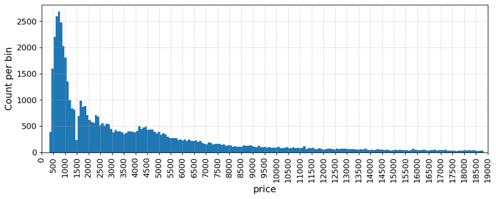

```python
# Create fixed price categories on the full dataset first
full_diamonds_with_bins = full_diamonds.copy()

full_diamonds_with_bins["target_cat"] = pd.cut(
    full_diamonds_with_bins[target_column],
    bins=np.arange(0, price_max + 1, price_cat_size),
    labels=np.arange(price_cat_size, price_max + 1, price_cat_size),
    include_lowest=True
)

# If DATASET_SIZE is smaller than the full dataset, create a test sample
# that keeps at least 2 rows from every available price category
MIN_ROWS_PER_BIN = 2
TEST_SIZE = 0.2

if DATASET_SIZE < len(full_diamonds_with_bins):

    target_cat_counts = full_diamonds_with_bins["target_cat"].value_counts().sort_index()
    valid_target_cats = target_cat_counts[target_cat_counts >= MIN_ROWS_PER_BIN].index

    minimum_required_rows = max(
        len(valid_target_cats) * MIN_ROWS_PER_BIN,
        int(np.ceil(len(valid_target_cats) / TEST_SIZE))
    )

    if DATASET_SIZE < minimum_required_rows:
        raise ValueError(
            f"DATASET_SIZE is too small for stratified sampling with fixed price bins. "
            f"Minimum required rows: {minimum_required_rows}, "
            f"current DATASET_SIZE: {DATASET_SIZE}."
        )

    base_sample = (
        full_diamonds_with_bins[
            full_diamonds_with_bins["target_cat"].isin(valid_target_cats)
        ]
        .groupby("target_cat", observed=True, group_keys=False)
        .sample(n=MIN_ROWS_PER_BIN, random_state=RANDOM_STATE)
    )

    remaining_rows_needed = DATASET_SIZE - len(base_sample)

    remaining_pool = full_diamonds_with_bins.drop(index=base_sample.index)

    extra_sample = remaining_pool.sample(
        n=remaining_rows_needed,
        random_state=RANDOM_STATE
    )

    diamonds = (
        pd.concat([base_sample, extra_sample], axis=0)
        .sample(frac=1, random_state=RANDOM_STATE)
        .reset_index(drop=True)
    )

else:
    diamonds = (
        full_diamonds_with_bins
        .sample(frac=1, random_state=RANDOM_STATE)
        .reset_index(drop=True)
    )


# Plot "price"
diamonds[target_column].hist(bins=price_bins, figsize=(12, 4))

plt.xlim(0, price_max)
plt.xticks(np.arange(0, price_max + 1, price_cat_size), rotation=90)

plt.xlabel(target_column)
plt.ylabel("Count per bin")
plt.grid(True, linestyle="--", alpha=0.5)
plt.show()
```

## Train and Test Set

#### Prepare for StratifiedShuffleSplit making categories

```python
# Check target categories
diamonds["target_cat"].value_counts().sort_index()
```

```
target_cat
500       1749
1000     12775
1500      5486
2000      4197
2500      3335
3000      2794
3500      2164
4000      2061
4500      2474
5000      2191
5500      1759
6000      1404
6500      1223
7000      1055
```

[output cut: 25 more lines]

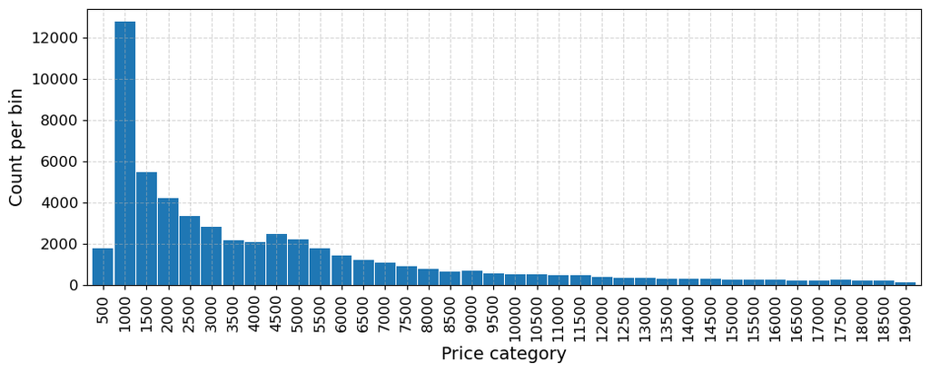

```python
diamonds["target_cat"].value_counts().sort_index().plot.bar(
    figsize=(12, 4),
    width=0.95
)

plt.xlabel("Price category")
plt.ylabel("Count per bin")
plt.grid(True, linestyle="--", alpha=0.5)
plt.show()
```

### Create a Train and Test Set

```python
from sklearn.model_selection import StratifiedShuffleSplit

splitter = StratifiedShuffleSplit(
    n_splits=1,
    test_size=TEST_SIZE,
    random_state=RANDOM_STATE
)

for train_index, test_index in splitter.split(diamonds, diamonds["target_cat"]):
    train_set = diamonds.loc[train_index].reset_index(drop=True)
    test_set = diamonds.loc[test_index].reset_index(drop=True)
```

### Check the details of train_set and test_set

```python
train_set.shape, test_set.shape
```

```
((43152, 11), (10788, 11))
```

```python
# Compare the ratio of the full dataset, the train set and the test set
comparison_df = pd.DataFrame({
    "full_ratio": diamonds["target_cat"].value_counts().sort_index() / len(diamonds),
    "train_ratio": train_set["target_cat"].value_counts().sort_index() / len(train_set),
    "test_ratio": test_set["target_cat"].value_counts().sort_index() / len(test_set),
})

comparison_df.head(10)
```

| target_cat | full_ratio | train_ratio | test_ratio |
| --- | --- | --- | --- |
| 500 | 0.03 | 0.03 | 0.03 |
| 1000 | 0.24 | 0.24 | 0.24 |
| 1500 | 0.10 | 0.10 | 0.10 |
| 2000 | 0.08 | 0.08 | 0.08 |
| 2500 | 0.06 | 0.06 | 0.06 |
| 3000 | 0.05 | 0.05 | 0.05 |
| 3500 | 0.04 | 0.04 | 0.04 |
| 4000 | 0.04 | 0.04 | 0.04 |
| 4500 | 0.05 | 0.05 | 0.05 |
| 5000 | 0.04 | 0.04 | 0.04 |

## Feature Engineering

```python
# Define the function for feature engineering
def engineer_features(data: pd.DataFrame) -> pd.DataFrame:
    # let's make a copy of the original dataset
    engineered_data = data.copy()
    # drop the previously created but unnecessary columns
    engineered_data = engineered_data.drop(columns="target_cat")
    # drop target_column as it is the label
    engineered_data = engineered_data.drop(columns=target_column)
    # # categorical features
    # categorical_features = ["cut", "color", "clarity"]
    # engineered_data[categorical_features] = engineered_data[categorical_features].astype('category')
    return engineered_data
```

### Create X_train, X_test, y_train, y_test

```python
# Create X_train, X_test, y_train, y_test
X_train = engineer_features(train_set)
X_test = engineer_features(test_set)
y_train = train_set[target_column].copy()
y_test = test_set[target_column].copy()
```

```python
train_set.head()
```

|  | carat | cut | color | clarity | depth | table | price | x | y | z | target_cat |
| --- | --- | --- | --- | --- | --- | --- | --- | --- | --- | --- | --- |
| 0 | 0.52 | Ideal | G | VVS2 | 61.60 | 54.00 | 1958 | 5.17 | 5.22 | 3.20 | 2000 |
| 1 | 0.75 | Ideal | E | SI1 | 62.20 | 57.00 | 2985 | 5.82 | 5.86 | 3.63 | 3000 |
| 2 | 0.51 | Very Good | D | VS2 | 63.20 | 56.00 | 1722 | 5.04 | 5.08 | 3.20 | 2000 |
| 3 | 0.39 | Premium | F | SI1 | 61.30 | 62.00 | 860 | 4.71 | 4.68 | 2.88 | 1000 |
| 4 | 0.30 | Good | H | VS1 | 63.40 | 53.00 | 526 | 4.25 | 4.30 | 2.71 | 1000 |

```python
X_train.head()
```

|  | carat | cut | color | clarity | depth | table | x | y | z |
| --- | --- | --- | --- | --- | --- | --- | --- | --- | --- |
| 0 | 0.52 | Ideal | G | VVS2 | 61.60 | 54.00 | 5.17 | 5.22 | 3.20 |
| 1 | 0.75 | Ideal | E | SI1 | 62.20 | 57.00 | 5.82 | 5.86 | 3.63 |
| 2 | 0.51 | Very Good | D | VS2 | 63.20 | 56.00 | 5.04 | 5.08 | 3.20 |
| 3 | 0.39 | Premium | F | SI1 | 61.30 | 62.00 | 4.71 | 4.68 | 2.88 |
| 4 | 0.30 | Good | H | VS1 | 63.40 | 53.00 | 4.25 | 4.30 | 2.71 |

```python
X_train.info()
```

```
<class 'pandas.DataFrame'>
RangeIndex: 43152 entries, 0 to 43151
Data columns (total 9 columns):
 #   Column   Non-Null Count  Dtype
---  ------   --------------  -----
 0   carat    43152 non-null  float64
 1   cut      43152 non-null  category
 2   color    43152 non-null  category
 3   clarity  43152 non-null  category
 4   depth    43152 non-null  float64
 5   table    43152 non-null  float64
 6   x        43152 non-null  float64
 7   y        43152 non-null  float64
 8   z        43152 non-null  float64
dtypes: category(3), float64(6)
memory usage: 2.1 MB
```

### Check missing values

```python
## Look for rows with incomplete values
incomplete_rows = X_train[X_train.isna().any(axis=1)]
incomplete_rows
```

|  | carat | cut | color | clarity | depth | table | x | y | z |
| --- | --- | --- | --- | --- | --- | --- | --- | --- | --- |

```python
X_train.isnull().sum()
```

```
carat      0
cut        0
color      0
clarity    0
depth      0
table      0
x          0
y          0
z          0
dtype: int64
```

### Check numerical and categorical columns

```python
# Separate numerical and categorical columns
num_attribs = X_train.select_dtypes(include=["int64", "float64"]).columns.tolist()
cat_attribs = X_train.select_dtypes(include=["object", "category"]).columns.tolist()

print(f"numerical columns:\n{num_attribs}\n")
print(f"categorical columns:\n{cat_attribs}")
```

```
numerical columns:
['carat', 'depth', 'table', 'x', 'y', 'z']

categorical columns:
['cut', 'color', 'clarity']
```

## Preprocessing

```python
from sklearn.pipeline import Pipeline
from sklearn.compose import ColumnTransformer
from sklearn.preprocessing import OneHotEncoder, StandardScaler
```

### Select test set rows for prediction comparison

```python
# Use all test set rows for prediction comparison
sample_idx = X_test.index
```

### Preprocessing for scaled models

```python
scaled_preprocessing = ColumnTransformer([
    ("num", StandardScaler(), num_attribs),
    ("cat", OneHotEncoder(handle_unknown="ignore"), cat_attribs)
])
```

### Preprocessing for tree-based models

```python
tree_preprocessing = ColumnTransformer([
    ("num", "passthrough", num_attribs),
    ("cat", OneHotEncoder(handle_unknown="ignore"), cat_attribs)
])
```

### Create `evaluate_regression` function

```python
from sklearn.metrics import mean_absolute_error, mean_squared_error, r2_score
import numpy as np

# Define a function to evaluate a regression model
def evaluate_regression(
    y_true,
    y_pred,
    model_name="Model",
    y_train_true=None,
    y_train_pred=None
):
    mae = mean_absolute_error(y_true, y_pred)
    mse = mean_squared_error(y_true, y_pred)
    rmse = np.sqrt(mse)
    r2 = r2_score(y_true, y_pred)

    print(f"--- {model_name} ---")
    print("TEST")
    print(f"MAE:  {mae:.2f}")
    print(f"RMSE: {rmse:.2f}")
    print(f"R²:   {r2:.4f}")

    results = {
        "Model": model_name,
        "MAE": mae,
        "RMSE": rmse,
        "R2": r2
    }

    # Optional train vs test fit check
    if y_train_true is not None and y_train_pred is not None:
        train_mae = mean_absolute_error(y_train_true, y_train_pred)
        train_mse = mean_squared_error(y_train_true, y_train_pred)
        train_rmse = np.sqrt(train_mse)
        train_r2 = r2_score(y_train_true, y_train_pred)

        rmse_gap = rmse - train_rmse
        r2_gap = train_r2 - r2

        print()
        print("TRAIN")
        print(f"MAE:  {train_mae:.2f}")
        print(f"RMSE: {train_rmse:.2f}")
        print(f"R²:   {train_r2:.4f}")

        print()
        print("GAP")
        print(f"RMSE gap: {rmse_gap:.2f}")
        print(f"R² gap:   {r2_gap:.4f}")

        results.update({
            "Train_MAE": train_mae,
            "Train_RMSE": train_rmse,
            "Train_R2": train_r2,
            "RMSE_gap": rmse_gap,
            "R2_gap": r2_gap
        })

    return results
```

# Load the saved files

### Load fitted Base Models

```python
if QUICK_LOAD:
    import os
    import joblib
    import pandas as pd

    models_dir = os.path.join("_exports", "regression_models", "fitted_base_models")

    if not os.path.exists(models_dir):
        raise FileNotFoundError(f"Model directory not found: {models_dir}")

    loaded_fitted_base_models = {}

    for filename in sorted(os.listdir(models_dir)):
        if filename.endswith(".pkl"):
            model_key = filename.replace("fitted_base_model_", "").replace(".pkl", "")
            full_path = os.path.join(models_dir, filename)
            loaded_fitted_base_models[model_key] = joblib.load(full_path)

    if not loaded_fitted_base_models:
        raise FileNotFoundError(
            f"No fitted base model .pkl files were found in: {models_dir}"
        )

    loaded_fitted_base_models_df = pd.DataFrame({
        "Model_Key": list(loaded_fitted_base_models.keys())
    }).reset_index(drop=True)
```

### Load Search Objects

```python
if QUICK_LOAD:
    import os
    import joblib
    import pandas as pd

    searches_dir = os.path.join("_exports", "regression_models", "search_objects")

    if not os.path.exists(searches_dir):
        raise FileNotFoundError(f"Search directory not found: {searches_dir}")

    loaded_searches = {}

    for filename in sorted(os.listdir(searches_dir)):
        if filename.endswith(".pkl"):
            search_key = filename.replace("regression_search_", "").replace(".pkl", "")
            full_path = os.path.join(searches_dir, filename)
            loaded_searches[search_key] = joblib.load(full_path)

    if not loaded_searches:
        raise FileNotFoundError(
            f"No search object .pkl files were found in: {searches_dir}"
        )

    loaded_searches_df = pd.DataFrame({
        "Search_Key": list(loaded_searches.keys())
    }).reset_index(drop=True)
```

### Load Predictions

```python
if QUICK_LOAD:
    import os
    import joblib
    import pandas as pd

    predictions_dir = os.path.join("_exports", "regression_models", "predictions")

    if not os.path.exists(predictions_dir):
        raise FileNotFoundError(f"Prediction directory not found: {predictions_dir}")

    loaded_predictions = {}

    for filename in sorted(os.listdir(predictions_dir)):
        if filename.endswith(".pkl"):
            prediction_key = filename.replace(".pkl", "")  # remove extension only
            full_path = os.path.join(predictions_dir, filename)
            loaded_predictions[prediction_key] = joblib.load(full_path)

    if not loaded_predictions:
        raise FileNotFoundError(
            f"No prediction .pkl files were found in: {predictions_dir}"
        )

    loaded_predictions_df = pd.DataFrame({
        "Prediction_Key": list(loaded_predictions.keys()),
        "Object_Type": [type(obj).__name__ for obj in loaded_predictions.values()],
        "Length": [
            len(obj) if hasattr(obj, "__len__") else None
            for obj in loaded_predictions.values()
        ]
    }).reset_index(drop=True)

    display(loaded_predictions_df)
```

# **Baseline models**

## Dummy Regressor

The DummyRegressor is a simple baseline model that makes predictions without learning real relationships from the data.

```python
start_fit = time.perf_counter()
```

```python
from sklearn.dummy import DummyRegressor

dummy_param = {
    # Most important parameters: strategy
    "strategy": "mean"      # Default: "mean" -> Common alternatives: "median", "quantile", "constant"
    # "constant": 1000      # Default: None -> Only used if strategy="constant"
}

dummy_reg = Pipeline([
    ("preprocessing", tree_preprocessing),
    ("model", DummyRegressor(**dummy_param))
])

dummy_reg.fit(X_train, y_train)
```

```
Pipeline(steps=[('preprocessing',
                 ColumnTransformer(transformers=[('num', 'passthrough',
                                                  ['carat', 'depth', 'table',
                                                   'x', 'y', 'z']),
                                                 ('cat',
                                                  OneHotEncoder(handle_unknown='ignore'),
                                                  ['cut', 'color',
                                                   'clarity'])])),
                ('model', DummyRegressor())])
```

```python
dummy_fit_time = time.perf_counter() - start_fit
formatted_time = str(timedelta(seconds=int(dummy_fit_time)))
print(f"Fit time: {formatted_time}")
```

```
Fit time: 0:00:00
```

### Features created by Dummy Regressor Model

```python
# Number of input features used by the model
print("Number of input features:", dummy_reg.named_steps["model"].n_features_in_)
```

```
Number of input features: 26
```

```python
# Names of the transformed features after preprocessing
print("Feature names after preprocessing:\n", dummy_reg.named_steps["preprocessing"].get_feature_names_out())
```

```
Feature names after preprocessing:
 ['num__carat' 'num__depth' 'num__table' 'num__x' 'num__y' 'num__z'
 'cat__cut_Fair' 'cat__cut_Good' 'cat__cut_Ideal' 'cat__cut_Premium'
 'cat__cut_Very Good' 'cat__color_D' 'cat__color_E' 'cat__color_F'
 'cat__color_G' 'cat__color_H' 'cat__color_I' 'cat__color_J'
 'cat__clarity_I1' 'cat__clarity_IF' 'cat__clarity_SI1' 'cat__clarity_SI2'
 'cat__clarity_VS1' 'cat__clarity_VS2' 'cat__clarity_VVS1'
 'cat__clarity_VVS2']
```

### Prediction on test set

```python
start_pred = time.perf_counter()
```

```python
if not QUICK_LOAD:
    print("Dummy Regressor: predicting model...")
    dummy_pred_train = dummy_reg.predict(X_train)
    dummy_pred_test = dummy_reg.predict(X_test)
    print("Dummy Regressor: predicted successfully.\n")

else:
    print("Dummy Regressor: loading predicted model...")
    dummy_pred_train = loaded_predictions["dummy_pred_train_file"]
    dummy_pred_test = loaded_predictions["dummy_pred_test_file"]
    print("Dummy Regressor: loaded successfully.\n")


dummy_results = evaluate_regression(
    y_test,
    dummy_pred_test,
    model_name="Dummy Regressor",
    y_train_true=y_train,
    y_train_pred=dummy_pred_train
)
```

```
Dummy Regressor: predicting model...
Dummy Regressor: predicted successfully.

--- Dummy Regressor ---
TEST
MAE:  3031.98
RMSE: 3989.65
R²:   -0.0000

TRAIN
MAE:  3031.54
RMSE: 3989.34
R²:   0.0000

GAP
RMSE gap: 0.31
R² gap:   0.0000
```

```python
dummy_predict_time = time.perf_counter() - start_pred
formatted_time = str(timedelta(seconds=int(dummy_predict_time)))
print(f"Predict time: {formatted_time}")
```

```
Predict time: 0:00:00
```

### Test set prediction comparison

```python
dummy_results_comparison = pd.DataFrame({
    "Original Label": y_test.loc[sample_idx],
    "Prediction": pd.Series(dummy_pred_test, index=X_test.index).loc[sample_idx]
})

### Save test set predictions for each model
dummy_sample_pred = pd.Series(dummy_pred_test, index=X_test.index).loc[sample_idx]

dummy_results_comparison["Error"] = dummy_results_comparison["Prediction"] - dummy_results_comparison["Original Label"]
dummy_results_comparison.sample(15, random_state=RANDOM_STATE).sort_values("Original Label").T.style.format("{:.2f}") \
    .set_properties(
        subset=pd.IndexSlice[["Original Label"], :],
        **{"background-color": "#ffd966"}
    ) \
    .map_index(
        lambda v: "background-color: #ffd966" if v == "Original Label" else "",
        axis=0
    )
```

|  | 8048 | 9730 | 4593 | 3706 | 5458 | 8353 | 6130 | 510 | 10382 | 7331 | 6319 | 6725 | 10334 | 3614 | 7116 |
| --- | --- | --- | --- | --- | --- | --- | --- | --- | --- | --- | --- | --- | --- | --- | --- |
| Original Label | 571.00 | 764.00 | 827.00 | 1148.00 | 1356.00 | 1400.00 | 2669.00 | 2822.00 | 3943.00 | 4155.00 | 4404.00 | 7670.00 | 8828.00 | 11861.00 | 16670.00 |
| Prediction | 3932.89 | 3932.89 | 3932.89 | 3932.89 | 3932.89 | 3932.89 | 3932.89 | 3932.89 | 3932.89 | 3932.89 | 3932.89 | 3932.89 | 3932.89 | 3932.89 | 3932.89 |
| Error | 3361.89 | 3168.89 | 3105.89 | 2784.89 | 2576.89 | 2532.89 | 1263.89 | 1110.89 | -10.11 | -222.11 | -471.11 | -3737.11 | -4895.11 | -7928.11 | -12737.11 |

### Add formatted timing and model type to the results

```python
dummy_results["Model_type"] = "Baseline"

dummy_results["Fit_time"] = str(timedelta(seconds=int(dummy_fit_time)))
dummy_results["Pred_time"] = str(timedelta(seconds=int(dummy_predict_time)))
dummy_results["Tun_fit_time"] = np.nan
dummy_results["Tun_pred_time"] = np.nan
dummy_results["Full_model_time"] = str(timedelta(seconds=int(dummy_fit_time + dummy_predict_time)))

dummy_results["Tun_MAE"] = dummy_results["MAE"]
dummy_results["Tun_RMSE"] = dummy_results["RMSE"]
dummy_results["Tun_R2"] = dummy_results["R2"]
```

# **Linear / regularized models**

## Linear Regressor

The model tries to find which line best fits the data.

```python
start_fit = time.perf_counter()
```

```python
if not QUICK_LOAD:
    from sklearn.linear_model import LinearRegression

    lin_reg = Pipeline([
        ("preprocessing", scaled_preprocessing),
        ("model", LinearRegression())
    ])

    print("Linear Regressor: fitting model...")
    lin_reg.fit(X_train, y_train)
    print("Linear Regressor: fitted successfully.")

else:
    print("Linear Regressor: loading fitted model...")
    lin_reg = loaded_fitted_base_models["linear"]
    print("Linear Regressor: loaded successfully.")
```

```
Linear Regressor: fitting model...
Linear Regressor: fitted successfully.
```

```python
lin_fit_time = time.perf_counter() - start_fit
formatted_time = str(timedelta(seconds=int(lin_fit_time)))
print(f"Fit time: {formatted_time}")
```

```
Fit time: 0:00:00
```

### Features created by Linear Regressor Model

```python
# Intercept of the linear regression model
print("Starting value of the model:", lin_reg.named_steps["model"].intercept_)
```

```
Starting value of the model: 3388.31030226263
```

```python
# Coefficients learned for each transformed feature
print("Weights for each feature:\n", lin_reg.named_steps["model"].coef_)
```

```
Weights for each feature:
 [ 5.44e+03 -9.87e+01 -6.01e+01 -1.25e+03 -2.88e+00 -9.33e+00 -5.74e+02
 -6.24e+00  2.60e+02  1.83e+02  1.37e+02  8.21e+02  6.20e+02  5.61e+02
  3.50e+02 -1.55e+02 -6.42e+02 -1.56e+03 -3.67e+03  1.50e+03 -1.64e+02
 -1.13e+03  7.49e+02  4.42e+02  1.16e+03  1.12e+03]
```

```python
# Number of input features used by the model
print("Number of input features:", lin_reg.named_steps["model"].n_features_in_)
```

```
Number of input features: 26
```

```python
# Rank of the training feature matrix
print("Rank of the training data:", lin_reg.named_steps["model"].rank_)
```

```
Rank of the training data: 23
```

```python
# Names of the transformed features after preprocessing
print("Feature names after preprocessing:\n", lin_reg.named_steps["preprocessing"].get_feature_names_out())
```

```
Feature names after preprocessing:
 ['num__carat' 'num__depth' 'num__table' 'num__x' 'num__y' 'num__z'
 'cat__cut_Fair' 'cat__cut_Good' 'cat__cut_Ideal' 'cat__cut_Premium'
 'cat__cut_Very Good' 'cat__color_D' 'cat__color_E' 'cat__color_F'
 'cat__color_G' 'cat__color_H' 'cat__color_I' 'cat__color_J'
 'cat__clarity_I1' 'cat__clarity_IF' 'cat__clarity_SI1' 'cat__clarity_SI2'
 'cat__clarity_VS1' 'cat__clarity_VS2' 'cat__clarity_VVS1'
 'cat__clarity_VVS2']
```

```python
# Singular values of the training feature matrix
print("Singular values of the training data:\n", lin_reg.named_steps["model"].singular_)
```

```
Singular values of the training data:
 [4.14e+02 2.40e+02 1.82e+02 1.02e+02 9.94e+01 9.48e+01 9.41e+01 9.03e+01
 8.76e+01 8.26e+01 8.10e+01 7.57e+01 6.72e+01 6.53e+01 6.34e+01 5.55e+01
 4.93e+01 4.43e+01 4.29e+01 3.94e+01 3.71e+01 2.46e+01 2.40e+01 2.70e-13
 7.60e-14 7.08e-14]
```

### Prediction on test set

```python
start_pred = time.perf_counter()
```

```python
if not QUICK_LOAD:
    print("Linear Regressor: predicting model...")
    lin_pred_train = lin_reg.predict(X_train)
    lin_pred_test = lin_reg.predict(X_test)
    print("Linear Regressor: predicted successfully.\n")

else:
    print("Linear Regressor: loading predicted model...")
    lin_pred_train = loaded_predictions["lin_pred_train_file"]
    lin_pred_test = loaded_predictions["lin_pred_test_file"]
    print("Linear Regressor: loaded successfully.\n")


lin_results = evaluate_regression(
    y_test,
    lin_pred_test,
    model_name="Linear Regressor",
    y_train_true=y_train,
    y_train_pred=lin_pred_train
)
```

```
Linear Regressor: predicting model...
Linear Regressor: predicted successfully.

--- Linear Regressor ---
TEST
MAE:  751.86
RMSE: 1191.28
R²:   0.9108

TRAIN
MAE:  732.64
RMSE: 1114.62
R²:   0.9219

GAP
RMSE gap: 76.66
R² gap:   0.0111
```

```python
lin_predict_time = time.perf_counter() - start_pred
formatted_time = str(timedelta(seconds=int(lin_predict_time)))
print(f"Predict time: {formatted_time}")
```

```
Predict time: 0:00:00
```

### Test set prediction comparison

```python
lin_results_comparison = pd.DataFrame({
    "Original Label": y_test.loc[sample_idx],
    "Prediction": pd.Series(lin_pred_test, index=X_test.index).loc[sample_idx]
})

### Save test set predictions for each model
lin_sample_pred = pd.Series(lin_pred_test, index=X_test.index).loc[sample_idx]

lin_results_comparison["Error"] = lin_results_comparison["Prediction"] - lin_results_comparison["Original Label"]
lin_results_comparison.sample(15, random_state=RANDOM_STATE).sort_values("Original Label").T.style.format("{:.2f}") \
    .set_properties(
        subset=pd.IndexSlice[["Original Label"], :],
        **{"background-color": "#ffd966"}
    ) \
    .map_index(
        lambda v: "background-color: #ffd966" if v == "Original Label" else "",
        axis=0
    )
```

|  | 8048 | 9730 | 4593 | 3706 | 5458 | 8353 | 6130 | 510 | 10382 | 7331 | 6319 | 6725 | 10334 | 3614 | 7116 |
| --- | --- | --- | --- | --- | --- | --- | --- | --- | --- | --- | --- | --- | --- | --- | --- |
| Original Label | 571.00 | 764.00 | 827.00 | 1148.00 | 1356.00 | 1400.00 | 2669.00 | 2822.00 | 3943.00 | 4155.00 | 4404.00 | 7670.00 | 8828.00 | 11861.00 | 16670.00 |
| Prediction | 182.28 | 1054.06 | 914.88 | 1617.37 | 1995.78 | 1957.88 | 2817.11 | 3445.18 | 3935.01 | 4568.26 | 4757.71 | 6874.30 | 12451.33 | 10144.17 | 11194.20 |
| Error | -388.72 | 290.06 | 87.88 | 469.37 | 639.78 | 557.88 | 148.11 | 623.18 | -7.99 | 413.26 | 353.71 | -795.70 | 3623.33 | -1716.83 | -5475.80 |

### Add formatted timing and model type to the results

```python
lin_results["Model_type"] = "Linear / regularized"

lin_results["Fit_time"] = str(timedelta(seconds=int(lin_fit_time)))
lin_results["Pred_time"] = str(timedelta(seconds=int(lin_predict_time)))
lin_results["Tun_fit_time"] = np.nan
lin_results["Tun_pred_time"] = np.nan
lin_results["Full_model_time"] = str(timedelta(seconds=int(lin_fit_time + lin_predict_time)))

lin_results["Tun_MAE"] = lin_results["MAE"]
lin_results["Tun_RMSE"] = lin_results["RMSE"]
lin_results["Tun_R2"] = lin_results["R2"]
```

## Ridge Regressor

Ridge Regressor is a regularized version of Linear Regressor that helps reduce overfitting.

```python
start_time = time.perf_counter()
```

```python
if not QUICK_LOAD:
    from sklearn.linear_model import Ridge

    ridge_param = {
        "alpha": 10.0    # Default: 1.0 -> From 0.1 to 100.0
    }

    ridge_reg = Pipeline([
        ("preprocessing", scaled_preprocessing),
        ("model", Ridge(**ridge_param))
    ])

    print("Ridge Regressor: fitting model...")
    ridge_reg.fit(X_train, y_train)
    print("Ridge Regressor: fitted successfully.")

else:
    print("Ridge Regressor: loading fitted model...")
    ridge_reg = loaded_fitted_base_models["ridge"]
    print("Ridge Regressor: loaded successfully.")
```

```
Ridge Regressor: fitting model...
Ridge Regressor: fitted successfully.
```

```python
ridge_fit_time = time.perf_counter() - start_time
formatted_time = str(timedelta(seconds=int(ridge_fit_time)))
print(f"Fit time: {formatted_time}")
```

```
Fit time: 0:00:00
```

### Features created by Ridge Regressor Model

```python
# Intercept of the ridge regression model
print("Starting value of the model:", ridge_reg.named_steps["model"].intercept_)
```

```
Starting value of the model: 3395.203718180953
```

```python
# Coefficients learned for each transformed feature
print("Weights for each feature:\n", ridge_reg.named_steps["model"].coef_)
```

```
Weights for each feature:
 [ 5400.46   -97.26   -60.32 -1206.62    -5.98   -13.39  -576.95    -6.12
   261.41   183.51   138.15   817.3    616.43   558.4    348.25  -154.93
  -639.68 -1545.76 -3607.88  1484.39  -170.35 -1136.77   740.42   435.08
  1148.81  1106.29]
```

```python
# Number of input features used by the model
print("Number of input features:", ridge_reg.named_steps["model"].n_features_in_)
```

```
Number of input features: 26
```

```python
# Names of the transformed features after preprocessing
print("Feature names after preprocessing:\n", ridge_reg.named_steps["preprocessing"].get_feature_names_out())
```

```
Feature names after preprocessing:
 ['num__carat' 'num__depth' 'num__table' 'num__x' 'num__y' 'num__z'
 'cat__cut_Fair' 'cat__cut_Good' 'cat__cut_Ideal' 'cat__cut_Premium'
 'cat__cut_Very Good' 'cat__color_D' 'cat__color_E' 'cat__color_F'
 'cat__color_G' 'cat__color_H' 'cat__color_I' 'cat__color_J'
 'cat__clarity_I1' 'cat__clarity_IF' 'cat__clarity_SI1' 'cat__clarity_SI2'
 'cat__clarity_VS1' 'cat__clarity_VS2' 'cat__clarity_VVS1'
 'cat__clarity_VVS2']
```

### Prediction on test set

```python
start_time = time.perf_counter()
```

```python
if not QUICK_LOAD:
    print("Ridge Regressor: predicting model...")
    ridge_pred_train = ridge_reg.predict(X_train)
    ridge_pred_test = ridge_reg.predict(X_test)
    print("Ridge Regressor: predicted successfully.\n")

else:
    print("Ridge Regressor: loading predicted model...")
    ridge_pred_train = loaded_predictions["ridge_pred_train_file"]
    ridge_pred_test = loaded_predictions["ridge_pred_test_file"]
    print("Ridge Regressor: loaded successfully.\n")


ridge_results = evaluate_regression(
    y_test,
    ridge_pred_test,
    model_name="Ridge Regressor",
    y_train_true=y_train,
    y_train_pred=ridge_pred_train
)
```

```
Ridge Regressor: predicting model...
Ridge Regressor: predicted successfully.

--- Ridge Regressor ---
TEST
MAE:  751.78
RMSE: 1191.18
R²:   0.9109

TRAIN
MAE:  732.59
RMSE: 1114.68
R²:   0.9219

GAP
RMSE gap: 76.51
R² gap:   0.0111
```

```python
ridge_predict_time = time.perf_counter() - start_time
formatted_time = str(timedelta(seconds=int(ridge_predict_time)))
print(f"Predict time: {formatted_time}")
```

```
Predict time: 0:00:00
```

### Hyperparameter Tuning

```python
start_time = time.perf_counter()
```

```python
if not QUICK_LOAD:
    from sklearn.model_selection import GridSearchCV

    ridge_param_grid = {
        "model__alpha": [1.0, 2.0, 5.0, 10.0, 15.0, 20.0, 30.0, 40.0, 50.0]
    }

    ridge_search = GridSearchCV(
        ridge_reg,                               # The pipeline model to tune
        param_grid=ridge_param_grid,             # Default: required -> Dictionary with parameter values to test - Parameter values to test
        scoring=SCORING,                         # Default: None -> Common alternatives: "r2", "neg_mean_absolute_error", "neg_mean_squared_error", "neg_root_mean_squared_error" - Evaluation metric
        cv=KFOLD_10,                             # Default: None -> Common values: 3, 5, 10 - Number of cross-validation folds
        n_jobs=N_JOBS,                           # Default: None -> Common values: None, 1, 2, 4, -1 // -1 = Use all CPU cores
        verbose=VERBOSE,                         # Default: 0 -> Common values: 0, 1, 2, 3 - Show progress during fitting
        error_score=ERROR_SCORE                  # Default: np.nan -> Common values: np.nan, "raise" - If a fit fails during CV/search, raise the error immediately instead of silently assigning NaN to that candidate
    )

    print("Ridge Regressor: running grid search...")
    ridge_search.fit(X_train, y_train)
    print("Ridge Regressor: grid search completed successfully.")

else:
    print("Ridge Regressor: loading search object...")
    ridge_search = loaded_searches["ridge"]
    print("Ridge Regressor: search object loaded successfully.")
```

```
Ridge Regressor: running grid search...
Fitting 10 folds for each of 9 candidates, totalling 90 fits
Ridge Regressor: grid search completed successfully.
```

```python
ridge_tuning_fit_time = time.perf_counter() - start_time
formatted_time = str(timedelta(seconds=int(ridge_tuning_fit_time)))
print(f"Predict time: {formatted_time}")
```

```
Predict time: 0:00:13
```

```python
# Best parameter
ridge_search.best_params_
```

```
{'model__alpha': 50.0}
```

```python
# Best model
ridge_best_tuning = ridge_search.best_estimator_
```

### Prediction on test set with Hyperparameter tuning

```python
start_time = time.perf_counter()
```

```python
if not QUICK_LOAD:
    print("Ridge Regressor: predicting best model...")
    ridge_best_pred_train = ridge_best_tuning.predict(X_train)
    ridge_best_pred_test = ridge_best_tuning.predict(X_test)
    print("Ridge Regressor: best model predicted successfully.\n")

else:
    print("Ridge Regressor: loading best predicted model...")
    ridge_best_pred_train = loaded_predictions["ridge_best_pred_train_file"]
    ridge_best_pred_test = loaded_predictions["ridge_best_pred_test_file"]
    print("Ridge Regressor: best model loaded successfully.\n")


ridge_best_results = evaluate_regression(
    y_test,
    ridge_best_pred_test,
    "Best Ridge Regressor",
    y_train_true=y_train,
    y_train_pred=ridge_best_pred_train
)
```

```
Ridge Regressor: predicting best model...
Ridge Regressor: best model predicted successfully.

--- Best Ridge Regressor ---
TEST
MAE:  751.98
RMSE: 1191.68
R²:   0.9108

TRAIN
MAE:  732.97
RMSE: 1115.87
R²:   0.9218

GAP
RMSE gap: 75.81
R² gap:   0.0110
```

```python
ridge_tuning_predict_time = time.perf_counter() - start_time
formatted_time = str(timedelta(seconds=int(ridge_tuning_predict_time)))
print(f"Predict time: {formatted_time}")
```

```
Predict time: 0:00:00
```

### Test set prediction comparison

```python
ridge_results_comparison = pd.DataFrame({
    "Original Label": y_test.loc[sample_idx],
    "Prediction": pd.Series(ridge_best_pred_test, index=X_test.index).loc[sample_idx]
})

### Save test set predictions for each model
ridge_sample_pred = pd.Series(ridge_best_pred_test, index=X_test.index).loc[sample_idx]

ridge_results_comparison["Error"] = ridge_results_comparison["Prediction"] - ridge_results_comparison["Original Label"]
ridge_results_comparison.sample(15, random_state=RANDOM_STATE).sort_values("Original Label").T.style.format("{:.2f}") \
    .set_properties(
        subset=pd.IndexSlice[["Original Label"], :],
        **{"background-color": "#ffd966"}
    ) \
    .map_index(
        lambda v: "background-color: #ffd966" if v == "Original Label" else "",
        axis=0
    )
```

|  | 8048 | 9730 | 4593 | 3706 | 5458 | 8353 | 6130 | 510 | 10382 | 7331 | 6319 | 6725 | 10334 | 3614 | 7116 |
| --- | --- | --- | --- | --- | --- | --- | --- | --- | --- | --- | --- | --- | --- | --- | --- |
| Original Label | 571.00 | 764.00 | 827.00 | 1148.00 | 1356.00 | 1400.00 | 2669.00 | 2822.00 | 3943.00 | 4155.00 | 4404.00 | 7670.00 | 8828.00 | 11861.00 | 16670.00 |
| Prediction | 181.06 | 1020.52 | 915.06 | 1556.39 | 1984.41 | 1925.29 | 2892.94 | 3482.85 | 3962.33 | 4587.15 | 4772.58 | 6889.61 | 12414.98 | 10124.59 | 11140.04 |
| Error | -389.94 | 256.52 | 88.06 | 408.39 | 628.41 | 525.29 | 223.94 | 660.85 | 19.33 | 432.15 | 368.58 | -780.39 | 3586.98 | -1736.41 | -5529.96 |

### Add formatted timing and model type to the results

```python
ridge_results["Model_type"] = "Linear / regularized"

ridge_results["Fit_time"] = str(timedelta(seconds=int(ridge_fit_time)))
ridge_results["Pred_time"] = str(timedelta(seconds=int(ridge_predict_time)))
ridge_results["Tun_fit_time"] = str(timedelta(seconds=int(ridge_tuning_fit_time)))
ridge_results["Tun_pred_time"] = str(timedelta(seconds=int(ridge_tuning_predict_time)))
ridge_results["Full_model_time"] = str(timedelta(seconds=int(ridge_fit_time + ridge_predict_time + ridge_tuning_fit_time + ridge_tuning_predict_time)))

ridge_results["Tun_MAE"] = ridge_best_results["MAE"]
ridge_results["Tun_RMSE"] = ridge_best_results["RMSE"]
ridge_results["Tun_R2"] = ridge_best_results["R2"]

ridge_results["Tun_Train_MAE"] = ridge_best_results["Train_MAE"]
ridge_results["Tun_Train_RMSE"] = ridge_best_results["Train_RMSE"]
ridge_results["Tun_Train_R2"] = ridge_best_results["Train_R2"]
```

## Lasso Regressor

The Lasso Regressor is a regularized version of the Linear Regressor, which can reduce the weight of some features to zero.

```python
start_fit = time.perf_counter()
```

```python
if not QUICK_LOAD:
    from sklearn.linear_model import Lasso

    lasso_param = {
        # Most important parameters: alpha
        "alpha": 0.1,       # Default: 1.0 -> From 0.01 to 10.0 - smaller alpha → weaker regularization
        "max_iter": 10000    # Default: 1000 -> Increase if convergence warning appears
    }

    lasso_reg = Pipeline([
        ("preprocessing", scaled_preprocessing),
        ("model", Lasso(**lasso_param))
    ])

    print("Lasso Regressor: fitting model...")
    lasso_reg.fit(X_train, y_train)
    print("Lasso Regressor: fitted successfully.")

else:
    print("Lasso Regressor: loading fitted model...")
    lasso_reg = loaded_fitted_base_models["lasso"]
    print("Lasso Regressor: loaded successfully.")
```

```
Lasso Regressor: fitting model...
Lasso Regressor: fitted successfully.
```

```python
lasso_fit_time = time.perf_counter() - start_fit
formatted_time = str(timedelta(seconds=int(lasso_fit_time)))
print(f"Fit time: {formatted_time}")
```

```
Fit time: 0:00:08
```

### Features created by Lasso Regressor Model

```python
# Intercept of the lasso regression model
print("Starting value of the model:", lasso_reg.named_steps["model"].intercept_)
```

```
Starting value of the model: 4402.749708468402
```

```python
# Coefficients learned for each transformed feature
print("Weights for each feature:\n", lasso_reg.named_steps["model"].coef_)
```

```
Weights for each feature:
 [ 5.43e+03 -9.88e+01 -6.02e+01 -1.24e+03 -2.55e+00 -9.41e+00 -7.09e+02
 -1.42e+02  1.23e+02  4.60e+01  0.00e+00  4.70e+02  2.69e+02  2.11e+02
  0.00e+00 -5.04e+02 -9.91e+02 -1.90e+03 -4.19e+03  9.70e+02 -6.91e+02
 -1.66e+03  2.20e+02 -8.50e+01  6.29e+02  5.87e+02]
```

```python
# Number of input features used by the model
print("Number of input features:", lasso_reg.named_steps["model"].n_features_in_)
```

```
Number of input features: 26
```

```python
# Names of the transformed features after preprocessing
print("Feature names after preprocessing:\n", lasso_reg.named_steps["preprocessing"].get_feature_names_out())
```

```
Feature names after preprocessing:
 ['num__carat' 'num__depth' 'num__table' 'num__x' 'num__y' 'num__z'
 'cat__cut_Fair' 'cat__cut_Good' 'cat__cut_Ideal' 'cat__cut_Premium'
 'cat__cut_Very Good' 'cat__color_D' 'cat__color_E' 'cat__color_F'
 'cat__color_G' 'cat__color_H' 'cat__color_I' 'cat__color_J'
 'cat__clarity_I1' 'cat__clarity_IF' 'cat__clarity_SI1' 'cat__clarity_SI2'
 'cat__clarity_VS1' 'cat__clarity_VS2' 'cat__clarity_VVS1'
 'cat__clarity_VVS2']
```

### Prediction on test set

```python
start_pred = time.perf_counter()
```

```python
if not QUICK_LOAD:
    print("Lasso Regressor: predicting model...")
    lasso_pred_train = lasso_reg.predict(X_train)
    lasso_pred_test = lasso_reg.predict(X_test)
    print("Lasso Regressor: predicted successfully.\n")

else:
    print("Lasso Regressor: loading predicted model...")
    lasso_pred_train = loaded_predictions["lasso_pred_train_file"]
    lasso_pred_test = loaded_predictions["lasso_pred_test_file"]
    print("Lasso Regressor: loaded successfully.\n")


lasso_results = evaluate_regression(
    y_test,
    lasso_pred_test,
    model_name="Lasso Regressor",
    y_train_true=y_train,
    y_train_pred=lasso_pred_train
)
```

```
Lasso Regressor: predicting model...
Lasso Regressor: predicted successfully.

--- Lasso Regressor ---
TEST
MAE:  751.67
RMSE: 1191.26
R²:   0.9108

TRAIN
MAE:  732.45
RMSE: 1114.62
R²:   0.9219

GAP
RMSE gap: 76.63
R² gap:   0.0111
```

```python
lasso_predict_time = time.perf_counter() - start_pred
formatted_time = str(timedelta(seconds=int(lasso_predict_time)))
print(f"Predict time: {formatted_time}")
```

```
Predict time: 0:00:00
```

### Hyperparameter Tuning

```python
start_time = time.perf_counter()
```

```python
if not QUICK_LOAD:
    from sklearn.model_selection import GridSearchCV

    lasso_param_grid = {
        "model__alpha": [0.01, 0.1, 1.0, 10.0],
        "model__max_iter": [50000]
    }

    lasso_search = GridSearchCV(
        lasso_reg,                               # The pipeline model to tune
        param_grid=lasso_param_grid,             # Default: required -> Dictionary with parameter values to test - Parameter values to test
        scoring=SCORING,                         # Default: None -> Common alternatives: "r2", "neg_mean_absolute_error", "neg_mean_squared_error", "neg_root_mean_squared_error" - Evaluation metric
        cv=KFOLD_10,                             # Default: None -> Common values: 3, 5, 10 - Number of cross-validation folds
        n_jobs=N_JOBS,                           # Default: None -> Common values: None, 1, 2, 4, -1 // -1 = Use all CPU cores
        verbose=VERBOSE,                         # Default: 0 -> Common values: 0, 1, 2, 3 - Show progress during fitting
        error_score=ERROR_SCORE                  # Default: np.nan -> Common values: np.nan, "raise" - If a fit fails during CV/search, raise the error immediately instead of silently assigning NaN to that candidate
    )

    print("Lasso Regressor: running grid search...")
    lasso_search.fit(X_train, y_train)
    print("Lasso Regressor: grid search completed successfully.")

else:
    print("Lasso Regressor: loading search object...")
    lasso_search = loaded_searches["lasso"]
    print("Lasso Regressor: search object loaded successfully.")
```

```
Lasso Regressor: running grid search...
Fitting 10 folds for each of 4 candidates, totalling 40 fits
Lasso Regressor: grid search completed successfully.
```

```python
lasso_tuning_fit_time = time.perf_counter() - start_time
formatted_time = str(timedelta(seconds=int(lasso_tuning_fit_time)))
print(f"Tuning time: {formatted_time}")
```

```
Tuning time: 0:06:54
```

```python
# Best parameter
lasso_search.best_params_
```

```
{'model__alpha': 1.0, 'model__max_iter': 50000}
```

```python
# Best model
lasso_best_tuning = lasso_search.best_estimator_
```

### Prediction on test set with Hyperparameter tuning

```python
start_time = time.perf_counter()
```

```python
if not QUICK_LOAD:
    print("Lasso Regressor: predicting best model...")
    lasso_best_pred_train = lasso_best_tuning.predict(X_train)
    lasso_best_pred_test = lasso_best_tuning.predict(X_test)
    print("Lasso Regressor: best model predicted successfully.\n")

else:
    print("Lasso Regressor: loading best predicted model...")
    lasso_best_pred_train = loaded_predictions["lasso_best_pred_train_file"]
    lasso_best_pred_test = loaded_predictions["lasso_best_pred_test_file"]
    print("Lasso Regressor: best model loaded successfully.\n")


lasso_best_results = evaluate_regression(
    y_test,
    lasso_best_pred_test,
    "Best Lasso Regressor",
    y_train_true=y_train,
    y_train_pred=lasso_best_pred_train
)
```

```
Lasso Regressor: predicting best model...
Lasso Regressor: best model predicted successfully.

--- Best Lasso Regressor ---
TEST
MAE:  750.02
RMSE: 1191.18
R²:   0.9109

TRAIN
MAE:  730.87
RMSE: 1114.79
R²:   0.9219

GAP
RMSE gap: 76.39
R² gap:   0.0111
```

```python
lasso_tuning_predict_time = time.perf_counter() - start_time
formatted_time = str(timedelta(seconds=int(lasso_tuning_predict_time)))
print(f"Tuning predict time: {formatted_time}")
```

```
Tuning predict time: 0:00:00
```

### Test set prediction comparison

```python
lasso_results_comparison = pd.DataFrame({
    "Original Label": y_test.loc[sample_idx],
    "Prediction": pd.Series(lasso_best_pred_test, index=X_test.index).loc[sample_idx]
})

### Save test set predictions for each model
lasso_sample_pred = pd.Series(lasso_best_pred_test, index=X_test.index).loc[sample_idx]

lasso_results_comparison["Error"] = lasso_results_comparison["Prediction"] - lasso_results_comparison["Original Label"]
lasso_results_comparison.sample(15, random_state=RANDOM_STATE).sort_values("Original Label").T.style.format("{:.2f}") \
    .set_properties(
        subset=pd.IndexSlice[["Original Label"], :],
        **{"background-color": "#ffd966"}
    ) \
    .map_index(
        lambda v: "background-color: #ffd966" if v == "Original Label" else "",
        axis=0
    )
```

|  | 8048 | 9730 | 4593 | 3706 | 5458 | 8353 | 6130 | 510 | 10382 | 7331 | 6319 | 6725 | 10334 | 3614 | 7116 |
| --- | --- | --- | --- | --- | --- | --- | --- | --- | --- | --- | --- | --- | --- | --- | --- |
| Original Label | 571.00 | 764.00 | 827.00 | 1148.00 | 1356.00 | 1400.00 | 2669.00 | 2822.00 | 3943.00 | 4155.00 | 4404.00 | 7670.00 | 8828.00 | 11861.00 | 16670.00 |
| Prediction | 191.42 | 1038.13 | 916.62 | 1578.91 | 1977.09 | 1929.26 | 2844.24 | 3453.48 | 3932.24 | 4585.62 | 4756.97 | 6875.90 | 12437.02 | 10126.89 | 11159.35 |
| Error | -379.58 | 274.13 | 89.62 | 430.91 | 621.09 | 529.26 | 175.24 | 631.48 | -10.76 | 430.62 | 352.97 | -794.10 | 3609.02 | -1734.11 | -5510.65 |

### Add formatted timing and model type to the results

```python
lasso_results["Model_type"] = "Linear / regularized"

lasso_results["Fit_time"] = str(timedelta(seconds=int(lasso_fit_time)))
lasso_results["Pred_time"] = str(timedelta(seconds=int(lasso_predict_time)))
lasso_results["Tun_fit_time"] = str(timedelta(seconds=int(lasso_tuning_fit_time)))
lasso_results["Tun_pred_time"] = str(timedelta(seconds=int(lasso_tuning_predict_time)))
lasso_results["Full_model_time"] = str(timedelta(seconds=int(lasso_fit_time + lasso_predict_time + lasso_tuning_fit_time + lasso_tuning_predict_time)))

lasso_results["Tun_MAE"] = lasso_best_results["MAE"]
lasso_results["Tun_RMSE"] = lasso_best_results["RMSE"]
lasso_results["Tun_R2"] = lasso_best_results["R2"]

lasso_results["Tun_Train_MAE"] = lasso_best_results["Train_MAE"]
lasso_results["Tun_Train_RMSE"] = lasso_best_results["Train_RMSE"]
lasso_results["Tun_Train_R2"] = lasso_best_results["Train_R2"]
```

## ElasticNet Regressor

The ElasticNet Regressor combines L1 and L2 regularization, so it balances feature selection and coefficient shrinkage.

```python
start_fit = time.perf_counter()
```

```python
if not QUICK_LOAD:
    from sklearn.linear_model import ElasticNet

    elastic_param = {
        # Most important parameters: alpha, l1_ratio
        "alpha": 0.1,        # Default: 1.0 -> From 0.01 to 10.0 - smaller alpha → weaker regularization
        "l1_ratio": 0.5,     # Default: 0.5 -> From 0.0 to 1.0 - 0 = Ridge-like, 1 = Lasso-like
        "max_iter": 5000     # Default: 1000 -> Increase if convergence warning appears
    }

    elastic_reg = Pipeline([
        ("preprocessing", scaled_preprocessing),
        ("model", ElasticNet(**elastic_param))
    ])

    print("ElasticNet Regressor: fitting model...")
    elastic_reg.fit(X_train, y_train)
    print("ElasticNet Regressor: fitted successfully.")

else:
    print("ElasticNet Regressor: loading fitted model...")
    elastic_reg = loaded_fitted_base_models["elasticnet"]
    print("ElasticNet Regressor: loaded successfully.")
```

```
ElasticNet Regressor: fitting model...
ElasticNet Regressor: fitted successfully.
```

```python
elastic_fit_time = time.perf_counter() - start_fit
formatted_time = str(timedelta(seconds=int(elastic_fit_time)))
print(f"Fit time: {formatted_time}")
```

```
Fit time: 0:00:00
```

### Features created by ElasticNet Regressor Model

```python
# Intercept of the elastic net regression model
print("Starting value of the model:", elastic_reg.named_steps["model"].intercept_)
```

```
Starting value of the model: 3784.6919461254006
```

```python
# Coefficients learned for each transformed feature
print("Weights for each feature:\n", elastic_reg.named_steps["model"].coef_)
```

```
Weights for each feature:
 [2773.88  -71.97  -83.14  530.5   313.81  263.04 -346.36  -62.73  205.79
  106.53   95.77  389.2   292.52  279.83  212.67 -144.81 -353.96 -676.45
 -752.94  480.41 -360.31 -918.21  314.05  150.97  522.81  561.23]
```

```python
# Number of input features used by the model
print("Number of input features:", elastic_reg.named_steps["model"].n_features_in_)
```

```
Number of input features: 26
```

```python
# Names of the transformed features after preprocessing
print("Feature names after preprocessing:\n", elastic_reg.named_steps["preprocessing"].get_feature_names_out())
```

```
Feature names after preprocessing:
 ['num__carat' 'num__depth' 'num__table' 'num__x' 'num__y' 'num__z'
 'cat__cut_Fair' 'cat__cut_Good' 'cat__cut_Ideal' 'cat__cut_Premium'
 'cat__cut_Very Good' 'cat__color_D' 'cat__color_E' 'cat__color_F'
 'cat__color_G' 'cat__color_H' 'cat__color_I' 'cat__color_J'
 'cat__clarity_I1' 'cat__clarity_IF' 'cat__clarity_SI1' 'cat__clarity_SI2'
 'cat__clarity_VS1' 'cat__clarity_VS2' 'cat__clarity_VVS1'
 'cat__clarity_VVS2']
```

### Prediction on test set

```python
start_pred = time.perf_counter()
```

```python
if not QUICK_LOAD:
    print("ElasticNet Regressor: predicting model...")
    elastic_pred_train = elastic_reg.predict(X_train)
    elastic_pred_test = elastic_reg.predict(X_test)
    print("ElasticNet Regressor: predicted successfully.\n")

else:
    print("ElasticNet Regressor: loading predicted model...")
    elastic_pred_train = loaded_predictions["elastic_pred_train_file"]
    elastic_pred_test = loaded_predictions["elastic_pred_test_file"]
    print("ElasticNet Regressor: loaded successfully.\n")


elastic_results = evaluate_regression(
    y_test,
    elastic_pred_test,
    model_name="ElasticNet Regressor",
    y_train_true=y_train,
    y_train_pred=elastic_pred_train
)
```

```
ElasticNet Regressor: predicting model...
ElasticNet Regressor: predicted successfully.

--- ElasticNet Regressor ---
TEST
MAE:  922.99
RMSE: 1384.66
R²:   0.8795

TRAIN
MAE:  909.81
RMSE: 1340.40
R²:   0.8871

GAP
RMSE gap: 44.26
R² gap:   0.0076
```

```python
elastic_predict_time = time.perf_counter() - start_pred
formatted_time = str(timedelta(seconds=int(elastic_predict_time)))
print(f"Predict time: {formatted_time}")
```

```
Predict time: 0:00:00
```

### Hyperparameter Tuning

```python
start_time = time.perf_counter()
```

```python
if not QUICK_LOAD:
    from sklearn.model_selection import GridSearchCV

    elastic_param_grid = {
        "model__alpha": [0.01, 0.1, 1.0, 10.0],
        "model__l1_ratio": [0.2, 0.5, 0.8]
    }

    elastic_search = GridSearchCV(
        elastic_reg,                             # The pipeline model to tune
        param_grid=elastic_param_grid,           # Default: required -> Dictionary with parameter values to test - Parameter values to test
        scoring=SCORING,                         # Default: None -> Common alternatives: "r2", "neg_mean_absolute_error", "neg_mean_squared_error", "neg_root_mean_squared_error" - Evaluation metric
        cv=KFOLD_10,                             # Default: None -> Common values: 3, 5, 10 - Number of cross-validation folds
        n_jobs=N_JOBS,                           # Default: None -> Common values: None, 1, 2, 4, -1 // -1 = Use all CPU cores
        verbose=VERBOSE,                         # Default: 0 -> Common values: 0, 1, 2, 3 - Show progress during fitting
        error_score="raise"                      # Default: np.nan -> Common values: np.nan, "raise" - If a fit fails during CV/search, raise the error immediately instead of silently assigning NaN to that candidate
    )

    print("ElasticNet Regressor: running grid search...")
    elastic_search.fit(X_train, y_train)
    print("ElasticNet Regressor: grid search completed successfully.")

else:
    print("ElasticNet Regressor: loading search object...")
    elastic_search = loaded_searches["elasticnet"]
    print("ElasticNet Regressor: search object loaded successfully.")
```

```
ElasticNet Regressor: running grid search...
Fitting 10 folds for each of 12 candidates, totalling 120 fits
ElasticNet Regressor: grid search completed successfully.
```

```python
elastic_tuning_fit_time = time.perf_counter() - start_time
formatted_time = str(timedelta(seconds=int(elastic_tuning_fit_time)))
print(f"Tuning time: {formatted_time}")
```

```
Tuning time: 0:00:24
```

```python
# Best parameters
elastic_search.best_params_
```

```
{'model__alpha': 0.01, 'model__l1_ratio': 0.8}
```

```python
# Best model
elastic_best_tuning = elastic_search.best_estimator_
```

### Prediction on test set with Hyperparameter tuning

```python
start_time = time.perf_counter()
```

```python
if not QUICK_LOAD:
    print("ElasticNet Regressor: predicting best model...")
    elastic_best_pred_train = elastic_best_tuning.predict(X_train)
    elastic_best_pred_test = elastic_best_tuning.predict(X_test)
    print("ElasticNet Regressor: best model predicted successfully.\n")

else:
    print("ElasticNet Regressor: loading best predicted model...")
    elastic_best_pred_train = loaded_predictions["elastic_best_pred_train_file"]
    elastic_best_pred_test = loaded_predictions["elastic_best_pred_test_file"]
    print("ElasticNet Regressor: best model loaded successfully.\n")


elastic_best_results = evaluate_regression(
    y_test,
    elastic_best_pred_test,
    "Best ElasticNet Regressor",
    y_train_true=y_train,
    y_train_pred=elastic_best_pred_train
)
```

```
ElasticNet Regressor: predicting best model...
ElasticNet Regressor: best model predicted successfully.

--- Best ElasticNet Regressor ---
TEST
MAE:  752.81
RMSE: 1193.11
R²:   0.9106

TRAIN
MAE:  734.06
RMSE: 1118.03
R²:   0.9215

GAP
RMSE gap: 75.08
R² gap:   0.0109
```

```python
elastic_tuning_predict_time = time.perf_counter() - start_time
formatted_time = str(timedelta(seconds=int(elastic_tuning_predict_time)))
print(f"Tuning predict time: {formatted_time}")
```

```
Tuning predict time: 0:00:00
```

### Test set prediction comparison

```python
elastic_results_comparison = pd.DataFrame({
    "Original Label": y_test.loc[sample_idx],
    "Prediction": pd.Series(elastic_best_pred_test, index=X_test.index).loc[sample_idx]
})

### Save test set predictions for each model
elastic_sample_pred = pd.Series(elastic_best_pred_test, index=X_test.index).loc[sample_idx]

elastic_results_comparison["Error"] = elastic_results_comparison["Prediction"] - elastic_results_comparison["Original Label"]
elastic_results_comparison.sample(15, random_state=RANDOM_STATE).sort_values("Original Label").T.style.format("{:.2f}") \
    .set_properties(
        subset=pd.IndexSlice[["Original Label"], :],
        **{"background-color": "#ffd966"}
    ) \
    .map_index(
        lambda v: "background-color: #ffd966" if v == "Original Label" else "",
        axis=0
    )
```

|  | 8048 | 9730 | 4593 | 3706 | 5458 | 8353 | 6130 | 510 | 10382 | 7331 | 6319 | 6725 | 10334 | 3614 | 7116 |
| --- | --- | --- | --- | --- | --- | --- | --- | --- | --- | --- | --- | --- | --- | --- | --- |
| Original Label | 571.00 | 764.00 | 827.00 | 1148.00 | 1356.00 | 1400.00 | 2669.00 | 2822.00 | 3943.00 | 4155.00 | 4404.00 | 7670.00 | 8828.00 | 11861.00 | 16670.00 |
| Prediction | 180.91 | 998.05 | 915.48 | 1515.50 | 1976.06 | 1903.09 | 2943.72 | 3508.01 | 3980.30 | 4599.86 | 4782.63 | 6899.44 | 12390.99 | 10110.91 | 11102.68 |
| Error | -390.09 | 234.05 | 88.48 | 367.50 | 620.06 | 503.09 | 274.72 | 686.01 | 37.30 | 444.86 | 378.63 | -770.56 | 3562.99 | -1750.09 | -5567.32 |

### Add formatted timing and model type to the results

```python
elastic_results["Model_type"] = "Linear / regularized"

elastic_results["Fit_time"] = str(timedelta(seconds=int(elastic_fit_time)))
elastic_results["Pred_time"] = str(timedelta(seconds=int(elastic_predict_time)))
elastic_results["Tun_fit_time"] = str(timedelta(seconds=int(elastic_tuning_fit_time)))
elastic_results["Tun_pred_time"] = str(timedelta(seconds=int(elastic_tuning_predict_time)))
elastic_results["Full_model_time"] = str(timedelta(seconds=int(elastic_fit_time + elastic_predict_time + elastic_tuning_fit_time + elastic_tuning_predict_time)))

elastic_results["Tun_MAE"] = elastic_best_results["MAE"]
elastic_results["Tun_RMSE"] = elastic_best_results["RMSE"]
elastic_results["Tun_R2"] = elastic_best_results["R2"]

elastic_results["Tun_Train_MAE"] = elastic_best_results["Train_MAE"]
elastic_results["Tun_Train_RMSE"] = elastic_best_results["Train_RMSE"]
elastic_results["Tun_Train_R2"] = elastic_best_results["Train_R2"]
```

## Bayesian Ridge Regressor

The BayesianRidge model is a linear Regressor model with built-in regularization based on Bayesian estimation.

```python
start_fit = time.perf_counter()
```

```python
if not QUICK_LOAD:
    from sklearn.linear_model import BayesianRidge

    bayes_ridge_param = {
        # Most important parameters: alpha_1, alpha_2, lambda_1, lambda_2
        "alpha_1": 1e-6,      # Default: 1e-6 -> Usually left at default unless you want to change the priors
        "alpha_2": 1e-6,      # Default: 1e-6 -> Usually left at default unless you want to change the priors
        "lambda_1": 1e-6,     # Default: 1e-6 -> Usually left at default unless you want to change the priors
        "lambda_2": 1e-6,     # Default: 1e-6 -> Usually left at default unless you want to change the priors
        "max_iter": 1000,     # Default: 300 -> Increase if convergence warning appears
        "tol": 0.001          # Default: 0.001 -> Smaller value means stricter stopping
    }

    bayes_ridge_reg = Pipeline([
        ("preprocessing", scaled_preprocessing),
        ("model", BayesianRidge(**bayes_ridge_param))
    ])

    print("Bayesian Ridge Regressor: fitting model...")
    bayes_ridge_reg.fit(X_train, y_train)
    print("Bayesian Ridge Regressor: fitted successfully.")

else:
    print("Bayesian Ridge Regressor: loading fitted model...")
    bayes_ridge_reg = loaded_fitted_base_models["bayesian_ridge"]
    print("Bayesian Ridge Regressor: loaded successfully.")
```

```
Bayesian Ridge Regressor: fitting model...
Bayesian Ridge Regressor: fitted successfully.
```

```python
bayes_ridge_fit_time = time.perf_counter() - start_fit
formatted_time = str(timedelta(seconds=int(bayes_ridge_fit_time)))
print(f"Fit time: {formatted_time}")
```

```
Fit time: 0:00:00
```

### Features created by Bayesian Ridge Regressor Model

```python
# Intercept of the Bayesian ridge regression model
print("Starting value of the model:", bayes_ridge_reg.named_steps["model"].intercept_)
```

```
Starting value of the model: 3388.6652888316694
```

```python
# Coefficients learned for each transformed feature
print("Weights for each feature:\n", bayes_ridge_reg.named_steps["model"].coef_)
```

```
Weights for each feature:
 [ 5.43e+03 -9.86e+01 -6.01e+01 -1.24e+03 -3.05e+00 -9.54e+00 -5.75e+02
 -6.23e+00  2.61e+02  1.83e+02  1.37e+02  8.21e+02  6.20e+02  5.61e+02
  3.50e+02 -1.55e+02 -6.42e+02 -1.55e+03 -3.67e+03  1.50e+03 -1.64e+02
 -1.13e+03  7.48e+02  4.42e+02  1.16e+03  1.11e+03]
```

```python
# Number of input features used by the model
print("Number of input features:", bayes_ridge_reg.named_steps["model"].n_features_in_)
```

```
Number of input features: 26
```

```python
# Names of the transformed features after preprocessing
print("Feature names after preprocessing:\n", bayes_ridge_reg.named_steps["preprocessing"].get_feature_names_out())
```

```
Feature names after preprocessing:
 ['num__carat' 'num__depth' 'num__table' 'num__x' 'num__y' 'num__z'
 'cat__cut_Fair' 'cat__cut_Good' 'cat__cut_Ideal' 'cat__cut_Premium'
 'cat__cut_Very Good' 'cat__color_D' 'cat__color_E' 'cat__color_F'
 'cat__color_G' 'cat__color_H' 'cat__color_I' 'cat__color_J'
 'cat__clarity_I1' 'cat__clarity_IF' 'cat__clarity_SI1' 'cat__clarity_SI2'
 'cat__clarity_VS1' 'cat__clarity_VS2' 'cat__clarity_VVS1'
 'cat__clarity_VVS2']
```

### Prediction on test set

```python
start_pred = time.perf_counter()
```

```python
if not QUICK_LOAD:
    print("Bayesian Ridge Regressor: predicting model...")
    bayes_ridge_pred_train = bayes_ridge_reg.predict(X_train)
    bayes_ridge_pred_test = bayes_ridge_reg.predict(X_test)
    print("Bayesian Ridge Regressor: predicted successfully.\n")

else:
    print("Bayesian Ridge Regressor: loading predicted model...")
    bayes_ridge_pred_train = loaded_predictions["bayes_ridge_pred_train_file"]
    bayes_ridge_pred_test = loaded_predictions["bayes_ridge_pred_test_file"]
    print("Bayesian Ridge Regressor: loaded successfully.\n")


bayes_ridge_results = evaluate_regression(
    y_test,
    bayes_ridge_pred_test,
    model_name="Bayesian Ridge Regressor",
    y_train_true=y_train,
    y_train_pred=bayes_ridge_pred_train
)
```

```
Bayesian Ridge Regressor: predicting model...
Bayesian Ridge Regressor: predicted successfully.

--- Bayesian Ridge Regressor ---
TEST
MAE:  751.86
RMSE: 1191.27
R²:   0.9108

TRAIN
MAE:  732.63
RMSE: 1114.62
R²:   0.9219

GAP
RMSE gap: 76.65
R² gap:   0.0111
```

```python
bayes_ridge_predict_time = time.perf_counter() - start_pred
formatted_time = str(timedelta(seconds=int(bayes_ridge_predict_time)))
print(f"Predict time: {formatted_time}")
```

```
Predict time: 0:00:00
```

### Hyperparameter Tuning

```python
start_time = time.perf_counter()
```

```python
if not QUICK_LOAD:
    from sklearn.model_selection import GridSearchCV

    bayes_ridge_param_grid = {
        "model__max_iter": [300, 500, 1000],
        "model__tol": [0.01, 0.001, 0.0001]
    }

    bayes_ridge_search = GridSearchCV(
        bayes_ridge_reg,                          # The pipeline model to tune
        param_grid=bayes_ridge_param_grid,        # Default: required -> Dictionary with parameter values to test - Parameter values to test
        scoring=SCORING,                          # Default: None -> Common alternatives: "r2", "neg_mean_absolute_error", "neg_mean_squared_error", "neg_root_mean_squared_error" - Evaluation metric
        cv=KFOLD_10,                              # Default: None -> Common values: 3, 5, 10 - Number of cross-validation folds
        n_jobs=N_JOBS,                            # Default: None -> Common values: None, 1, 2, 4, -1 // -1 = Use all CPU cores
        verbose=VERBOSE,                          # Default: 0 -> Common values: 0, 1, 2, 3 - Show progress during fitting
        error_score=ERROR_SCORE                   # Default: np.nan -> Common values: np.nan, "raise" - If a fit fails during CV/search, raise the error immediately instead of silently assigning NaN to that candidate
    )

    print("Bayesian Ridge Regressor: running grid search...")
    bayes_ridge_search.fit(X_train, y_train)
    print("Bayesian Ridge Regressor: grid search completed successfully.")

else:
    print("Bayesian Ridge Regressor: loading search object...")
    bayes_ridge_search = loaded_searches["bayesian_ridge"]
    print("Bayesian Ridge Regressor: search object loaded successfully.")
```

```
Bayesian Ridge Regressor: running grid search...
Fitting 10 folds for each of 9 candidates, totalling 90 fits
Bayesian Ridge Regressor: grid search completed successfully.
```

```python
bayes_ridge_tuning_fit_time = time.perf_counter() - start_time
formatted_time = str(timedelta(seconds=int(bayes_ridge_tuning_fit_time)))
print(f"Tuning time: {formatted_time}")
```

```
Tuning time: 0:00:10
```

```python
# Best parameters
bayes_ridge_search.best_params_
```

```
{'model__max_iter': 300, 'model__tol': 0.01}
```

```python
# Best model
bayes_ridge_best_tuning = bayes_ridge_search.best_estimator_
```

### Prediction on test set with Hyperparameter tuning

```python
start_time = time.perf_counter()
```

```python
if not QUICK_LOAD:
    print("Bayesian Ridge Regressor: predicting best model...")
    bayes_ridge_best_pred_train = bayes_ridge_best_tuning.predict(X_train)
    bayes_ridge_best_pred_test = bayes_ridge_best_tuning.predict(X_test)
    print("Bayesian Ridge Regressor: best model predicted successfully.\n")

else:
    print("Bayesian Ridge Regressor: loading best predicted model...")
    bayes_ridge_best_pred_train = loaded_predictions["bayes_ridge_best_pred_train_file"]
    bayes_ridge_best_pred_test = loaded_predictions["bayes_ridge_best_pred_test_file"]
    print("Bayesian Ridge Regressor: best model loaded successfully.\n")


bayes_ridge_best_results = evaluate_regression(
    y_test,
    bayes_ridge_best_pred_test,
    "Best Bayesian Ridge Regressor",
    y_train_true=y_train,
    y_train_pred=bayes_ridge_best_pred_train
)
```

```
Bayesian Ridge Regressor: predicting best model...
Bayesian Ridge Regressor: best model predicted successfully.

--- Best Bayesian Ridge Regressor ---
TEST
MAE:  751.86
RMSE: 1191.27
R²:   0.9108

TRAIN
MAE:  732.63
RMSE: 1114.62
R²:   0.9219

GAP
RMSE gap: 76.65
R² gap:   0.0111
```

```python
bayes_ridge_tuning_predict_time = time.perf_counter() - start_time
formatted_time = str(timedelta(seconds=int(bayes_ridge_tuning_predict_time)))
print(f"Tuning predict time: {formatted_time}")
```

```
Tuning predict time: 0:00:00
```

### Test set prediction comparison

```python
bayes_ridge_results_comparison = pd.DataFrame({
    "Original Label": y_test.loc[sample_idx],
    "Prediction": pd.Series(bayes_ridge_best_pred_test, index=X_test.index).loc[sample_idx]
})

### Save test set predictions for each model
bayes_ridge_sample_pred = pd.Series(bayes_ridge_best_pred_test, index=X_test.index).loc[sample_idx]

bayes_ridge_results_comparison["Error"] = bayes_ridge_results_comparison["Prediction"] - bayes_ridge_results_comparison["Original Label"]
bayes_ridge_results_comparison.sample(15, random_state=RANDOM_STATE).sort_values("Original Label").T.style.format("{:.2f}") \
    .set_properties(
        subset=pd.IndexSlice[["Original Label"], :],
        **{"background-color": "#ffd966"}
    ) \
    .map_index(
        lambda v: "background-color: #ffd966" if v == "Original Label" else "",
        axis=0
    )
```

|  | 8048 | 9730 | 4593 | 3706 | 5458 | 8353 | 6130 | 510 | 10382 | 7331 | 6319 | 6725 | 10334 | 3614 | 7116 |
| --- | --- | --- | --- | --- | --- | --- | --- | --- | --- | --- | --- | --- | --- | --- | --- |
| Original Label | 571.00 | 764.00 | 827.00 | 1148.00 | 1356.00 | 1400.00 | 2669.00 | 2822.00 | 3943.00 | 4155.00 | 4404.00 | 7670.00 | 8828.00 | 11861.00 | 16670.00 |
| Prediction | 182.26 | 1053.71 | 914.88 | 1616.71 | 1995.67 | 1957.54 | 2817.92 | 3445.58 | 3935.31 | 4568.47 | 4757.87 | 6874.47 | 12450.94 | 10143.97 | 11193.63 |
| Error | -388.74 | 289.71 | 87.88 | 468.71 | 639.67 | 557.54 | 148.92 | 623.58 | -7.69 | 413.47 | 353.87 | -795.53 | 3622.94 | -1717.03 | -5476.37 |

### Add formatted timing and model type to the results

```python
bayes_ridge_results["Model_type"] = "Linear / regularized"

bayes_ridge_results["Fit_time"] = str(timedelta(seconds=int(bayes_ridge_fit_time)))
bayes_ridge_results["Pred_time"] = str(timedelta(seconds=int(bayes_ridge_predict_time)))
bayes_ridge_results["Tun_fit_time"] = str(timedelta(seconds=int(bayes_ridge_tuning_fit_time)))
bayes_ridge_results["Tun_pred_time"] = str(timedelta(seconds=int(bayes_ridge_tuning_predict_time)))
bayes_ridge_results["Full_model_time"] = str(timedelta(seconds=int(bayes_ridge_fit_time + bayes_ridge_predict_time + bayes_ridge_tuning_fit_time + bayes_ridge_tuning_predict_time)))

bayes_ridge_results["Tun_MAE"] = bayes_ridge_best_results["MAE"]
bayes_ridge_results["Tun_RMSE"] = bayes_ridge_best_results["RMSE"]
bayes_ridge_results["Tun_R2"] = bayes_ridge_best_results["R2"]

bayes_ridge_results["Tun_Train_MAE"] = bayes_ridge_best_results["Train_MAE"]
bayes_ridge_results["Tun_Train_RMSE"] = bayes_ridge_best_results["Train_RMSE"]
bayes_ridge_results["Tun_Train_R2"] = bayes_ridge_best_results["Train_R2"]
```

## Quantile Regressor

The QuantileRegressor model is a linear Regressor model that estimates a chosen quantile of the target distribution instead of the mean.

```python
start_fit = time.perf_counter()
```

```python
if not QUICK_LOAD:
    from sklearn.linear_model import QuantileRegressor

    quantile_param = {
        # Most important parameters: quantile, alpha
        "quantile": 0.5,      # Default: 0.5 -> 0.5 = median regression, lower/higher values estimate lower/higher quantiles
        "alpha": 0.0,         # Default: 1.0 -> Smaller alpha = weaker regularization, 0.0 = no regularization
        "solver": "highs"     # Default: "highs" -> Recommended modern solver for linear programming
    }

    quantile_reg = Pipeline([
        ("preprocessing", scaled_preprocessing),
        ("model", QuantileRegressor(**quantile_param))
    ])

    print("Quantile Regressor: fitting model...")
    quantile_reg.fit(X_train, y_train)
    print("Quantile Regressor: fitted successfully.")

else:
    print("Quantile Regressor: loading fitted model...")
    quantile_reg = loaded_fitted_base_models["quantile"]
    print("Quantile Regressor: loaded successfully.")
```

```
Quantile Regressor: fitting model...
Quantile Regressor: fitted successfully.
```

```python
quantile_fit_time = time.perf_counter() - start_fit
formatted_time = str(timedelta(seconds=int(quantile_fit_time)))
print(f"Fit time: {formatted_time}")
```

```
Fit time: 0:03:11
```

### Features created by Quantile Regressor Model

```python
# Intercept of the quantile regression model
print("Starting value of the model:", quantile_reg.named_steps["model"].intercept_)
```

```
Starting value of the model: 2305.809651153515
```

```python
# Coefficients learned for each transformed feature
print("Weights for each feature:\n", quantile_reg.named_steps["model"].coef_)
```

```
Weights for each feature:
 [ 6170.62  -117.95   -56.73 -1534.42  -605.01  -191.06  -396.13   -50.39
    92.77    84.01     0.    1645.25  1507.89  1440.47  1376.08  1162.3
   801.12     0.   -2508.24   722.44     0.    -689.06   452.49   325.52
   606.09   581.12]
```

```python
# Number of input features used by the model
print("Number of input features:", quantile_reg.named_steps["model"].n_features_in_)
```

```
Number of input features: 26
```

```python
# Names of the transformed features after preprocessing
print("Feature names after preprocessing:\n", quantile_reg.named_steps["preprocessing"].get_feature_names_out())
```

```
Feature names after preprocessing:
 ['num__carat' 'num__depth' 'num__table' 'num__x' 'num__y' 'num__z'
 'cat__cut_Fair' 'cat__cut_Good' 'cat__cut_Ideal' 'cat__cut_Premium'
 'cat__cut_Very Good' 'cat__color_D' 'cat__color_E' 'cat__color_F'
 'cat__color_G' 'cat__color_H' 'cat__color_I' 'cat__color_J'
 'cat__clarity_I1' 'cat__clarity_IF' 'cat__clarity_SI1' 'cat__clarity_SI2'
 'cat__clarity_VS1' 'cat__clarity_VS2' 'cat__clarity_VVS1'
 'cat__clarity_VVS2']
```

### Prediction on test set

```python
start_pred = time.perf_counter()
```

```python
if not QUICK_LOAD:
    print("Quantile Regressor: predicting model...")
    quantile_pred_train = quantile_reg.predict(X_train)
    quantile_pred_test = quantile_reg.predict(X_test)
    print("Quantile Regressor: predicted successfully.\n")

else:
    print("Quantile Regressor: loading predicted model...")
    quantile_pred_train = loaded_predictions["quantile_pred_train_file"]
    quantile_pred_test = loaded_predictions["quantile_pred_test_file"]
    print("Quantile Regressor: loaded successfully.\n")


quantile_results = evaluate_regression(
    y_test,
    quantile_pred_test,
    model_name="Quantile Regressor",
    y_train_true=y_train,
    y_train_pred=quantile_pred_train
)
```

```
Quantile Regressor: predicting model...
Quantile Regressor: predicted successfully.

--- Quantile Regressor ---
TEST
MAE:  657.62
RMSE: 1322.29
R²:   0.8902

TRAIN
MAE:  638.64
RMSE: 1231.25
R²:   0.9047

GAP
RMSE gap: 91.04
R² gap:   0.0146
```

```python
quantile_predict_time = time.perf_counter() - start_pred
formatted_time = str(timedelta(seconds=int(quantile_predict_time)))
print(f"Predict time: {formatted_time}")
```

```
Predict time: 0:00:00
```

### Hyperparameter Tuning

```python
start_time = time.perf_counter()
```

```python
if not QUICK_LOAD:
    from sklearn.model_selection import GridSearchCV

    quantile_param_grid = {
        "model__quantile": [0.25, 0.5, 0.75],
        "model__alpha": [0.0, 0.0001, 0.001, 0.01]
    }

    quantile_search = GridSearchCV(
        quantile_reg,                             # The pipeline model to tune
        param_grid=quantile_param_grid,           # Default: required -> Dictionary with parameter values to test - Parameter values to test
        scoring=SCORING,                          # Default: None -> Common alternatives: "r2", "neg_mean_absolute_error", "neg_mean_squared_error", "neg_root_mean_squared_error" - Evaluation metric
        cv=KFOLD_5,                               # Default: None -> Common values: 3, 5, 10 - Number of cross-validation folds
        n_jobs=N_JOBS,                            # Default: None -> Common values: None, 1, 2, 4, -1 // -1 = Use all CPU cores
        verbose=VERBOSE,                          # Default: 0 -> Common values: 0, 1, 2, 3 - Show progress during fitting
        error_score=ERROR_SCORE                   # Default: np.nan -> Common values: np.nan, "raise" - If a fit fails during CV/search, raise the error immediately instead of silently assigning NaN to that candidate
    )
    print("Quantile Regressor: running grid search...")
    quantile_search.fit(X_train, y_train)
    print("Quantile Regressor: grid search completed successfully.")

else:
    print("Quantile Regressor: loading search object...")
    quantile_search = loaded_searches["quantile"]
    print("Quantile Regressor: search object loaded successfully.")
```

```
Quantile Regressor: running grid search...
Fitting 5 folds for each of 12 candidates, totalling 60 fits
Quantile Regressor: grid search completed successfully.
```

```python
quantile_tuning_fit_time = time.perf_counter() - start_time
formatted_time = str(timedelta(seconds=int(quantile_tuning_fit_time)))
print(f"Tuning time: {formatted_time}")
```

```
Tuning time: 1:04:26
```

```python
# Best parameters
quantile_search.best_params_
```

```
{'model__alpha': 0.0, 'model__quantile': 0.5}
```

```python
# Best model
quantile_best_tuning = quantile_search.best_estimator_
```

### Prediction on test set with Hyperparameter tuning

```python
start_time = time.perf_counter()
```

```python
if not QUICK_LOAD:
    print("Quantile Regressor: predicting best model...")
    quantile_best_pred_train = quantile_best_tuning.predict(X_train)
    quantile_best_pred_test = quantile_best_tuning.predict(X_test)
    print("Quantile Regressor: best model predicted successfully.\n")

else:
    print("Quantile Regressor: loading best predicted model...")
    quantile_best_pred_train = loaded_predictions["quantile_best_pred_train_file"]
    quantile_best_pred_test = loaded_predictions["quantile_best_pred_test_file"]
    print("Quantile Regressor: best model loaded successfully.\n")


quantile_best_results = evaluate_regression(
    y_test,
    quantile_best_pred_test,
    "Best Quantile Regressor",
    y_train_true=y_train,
    y_train_pred=quantile_best_pred_train
)
```

```
Quantile Regressor: predicting best model...
Quantile Regressor: best model predicted successfully.

--- Best Quantile Regressor ---
TEST
MAE:  657.62
RMSE: 1322.29
R²:   0.8902

TRAIN
MAE:  638.64
RMSE: 1231.25
R²:   0.9047

GAP
RMSE gap: 91.04
R² gap:   0.0146
```

```python
quantile_tuning_predict_time = time.perf_counter() - start_time
formatted_time = str(timedelta(seconds=int(quantile_tuning_predict_time)))
print(f"Tuning predict time: {formatted_time}")
```

```
Tuning predict time: 0:00:00
```

### Test set prediction comparison

```python
quantile_results_comparison = pd.DataFrame({
    "Original Label": y_test.loc[sample_idx],
    "Prediction": pd.Series(quantile_best_pred_test, index=X_test.index).loc[sample_idx]
})

### Save test set predictions for each model
quantile_sample_pred = pd.Series(quantile_best_pred_test, index=X_test.index).loc[sample_idx]

quantile_results_comparison["Error"] = quantile_results_comparison["Prediction"] - quantile_results_comparison["Original Label"]
quantile_results_comparison.sample(15, random_state=RANDOM_STATE).sort_values("Original Label").T.style.format("{:.2f}") \
    .set_properties(
        subset=pd.IndexSlice[["Original Label"], :],
        **{"background-color": "#ffd966"}
    ) \
    .map_index(
        lambda v: "background-color: #ffd966" if v == "Original Label" else "",
        axis=0
    )
```

|  | 8048 | 9730 | 4593 | 3706 | 5458 | 8353 | 6130 | 510 | 10382 | 7331 | 6319 | 6725 | 10334 | 3614 | 7116 |
| --- | --- | --- | --- | --- | --- | --- | --- | --- | --- | --- | --- | --- | --- | --- | --- |
| Original Label | 571.00 | 764.00 | 827.00 | 1148.00 | 1356.00 | 1400.00 | 2669.00 | 2822.00 | 3943.00 | 4155.00 | 4404.00 | 7670.00 | 8828.00 | 11861.00 | 16670.00 |
| Prediction | 492.75 | 809.74 | 985.55 | 1146.59 | 1371.12 | 1403.38 | 3235.83 | 2887.61 | 3794.07 | 4317.66 | 4579.96 | 6050.80 | 12089.47 | 9219.13 | 10183.32 |
| Error | -78.25 | 45.74 | 158.55 | -1.41 | 15.12 | 3.38 | 566.83 | 65.61 | -148.93 | 162.66 | 175.96 | -1619.20 | 3261.47 | -2641.87 | -6486.68 |

### Add formatted timing and model type to the results

```python
quantile_results["Model_type"] = "Linear / quantile"

quantile_results["Fit_time"] = str(timedelta(seconds=int(quantile_fit_time)))
quantile_results["Pred_time"] = str(timedelta(seconds=int(quantile_predict_time)))
quantile_results["Tun_fit_time"] = str(timedelta(seconds=int(quantile_tuning_fit_time)))
quantile_results["Tun_pred_time"] = str(timedelta(seconds=int(quantile_tuning_predict_time)))
quantile_results["Full_model_time"] = str(timedelta(seconds=int(quantile_fit_time + quantile_predict_time + quantile_tuning_fit_time + quantile_tuning_predict_time)))

quantile_results["Tun_MAE"] = quantile_best_results["MAE"]
quantile_results["Tun_RMSE"] = quantile_best_results["RMSE"]
quantile_results["Tun_R2"] = quantile_best_results["R2"]

quantile_results["Tun_Train_MAE"] = quantile_best_results["Train_MAE"]
quantile_results["Tun_Train_RMSE"] = quantile_best_results["Train_RMSE"]
quantile_results["Tun_Train_R2"] = quantile_best_results["Train_R2"]
```

# **Robust linear models**

## Huber Regressor

The HuberRegressor is a linear model that is more robust to outliers than ordinary linear regressor.

```python
start_fit = time.perf_counter()
```

```python
if not QUICK_LOAD:
    from sklearn.linear_model import HuberRegressor

    huber_param = {
        # Most important parameters: epsilon, alpha
        "epsilon": 1.35,      # Default: 1.35 -> From 1.1 to 2.0 - smaller epsilon → more sensitive to outliers
        "alpha": 0.0001,      # Default: 0.0001 -> From 0.00001 to 0.01 - smaller alpha → weaker regularization
        "max_iter": 500,      # Default: 100 -> Increase if convergence warning appears
        "tol": 0.00001        # Default: 0.00001 -> Smaller value means stricter stopping
    }

    huber_reg = Pipeline([
        ("preprocessing", scaled_preprocessing),
        ("model", HuberRegressor(**huber_param))
    ])
    print("Huber Regressor: fitting model...")
    huber_reg.fit(X_train, y_train)
    print("Huber Regressor: fitted successfully.")

else:
    print("Huber Regressor: loading fitted model...")
    huber_reg = loaded_fitted_base_models["huber"]
    print("Huber Regressor: loaded successfully.")
```

```
Huber Regressor: fitting model...
Huber Regressor: fitted successfully.
```

```python
huber_fit_time = time.perf_counter() - start_fit
formatted_time = str(timedelta(seconds=int(huber_fit_time)))
print(f"Fit time: {formatted_time}")
```

```
Fit time: 0:00:02
```

### Features created by Huber Regressor Model

```python
# Intercept of the Huber regressor model
print("Starting value of the model:", huber_reg.named_steps["model"].intercept_)
```

```
Starting value of the model: 2286.7131343011097
```

```python
# Coefficients learned for each transformed feature
print("Weights for each feature:\n", huber_reg.named_steps["model"].coef_)
```

```
Weights for each feature:
 [ 6189.91  -132.46   -60.98 -2152.96   -36.19   -93.38   105.29   450.41
   617.21   592.96   512.79   886.33   747.44   681.44   601.83   324.57
   -63.64  -899.32 -2202.17  1135.3    286.33  -434.6    835.     675.43
  1018.45   964.92]
```

```python
# Number of input features used by the model
print("Number of input features:", huber_reg.named_steps["model"].n_features_in_)
```

```
Number of input features: 26
```

```python
# Names of the transformed features after preprocessing
print("Feature names after preprocessing:\n", huber_reg.named_steps["preprocessing"].get_feature_names_out())
```

```
Feature names after preprocessing:
 ['num__carat' 'num__depth' 'num__table' 'num__x' 'num__y' 'num__z'
 'cat__cut_Fair' 'cat__cut_Good' 'cat__cut_Ideal' 'cat__cut_Premium'
 'cat__cut_Very Good' 'cat__color_D' 'cat__color_E' 'cat__color_F'
 'cat__color_G' 'cat__color_H' 'cat__color_I' 'cat__color_J'
 'cat__clarity_I1' 'cat__clarity_IF' 'cat__clarity_SI1' 'cat__clarity_SI2'
 'cat__clarity_VS1' 'cat__clarity_VS2' 'cat__clarity_VVS1'
 'cat__clarity_VVS2']
```

### Prediction on test set

```python
start_pred = time.perf_counter()
```

```python
if not QUICK_LOAD:
    print("Huber Regressor: predicting model...")
    huber_pred_train = huber_reg.predict(X_train)
    huber_pred_test = huber_reg.predict(X_test)
    print("Huber Regressor: predicted successfully.\n")

else:
    print("Huber Regressor: loading predicted model...")
    huber_pred_train = loaded_predictions["huber_pred_train_file"]
    huber_pred_test = loaded_predictions["huber_pred_test_file"]
    print("Huber Regressor: loaded successfully.\n")


huber_results = evaluate_regression(
    y_test,
    huber_pred_test,
    model_name="Huber Regressor",
    y_train_true=y_train,
    y_train_pred=huber_pred_train
)
```

```
Huber Regressor: predicting model...
Huber Regressor: predicted successfully.

--- Huber Regressor ---
TEST
MAE:  662.10
RMSE: 1289.80
R²:   0.8955

TRAIN
MAE:  642.26
RMSE: 1196.97
R²:   0.9100

GAP
RMSE gap: 92.84
R² gap:   0.0145
```

```python
huber_predict_time = time.perf_counter() - start_pred
formatted_time = str(timedelta(seconds=int(huber_predict_time)))
print(f"Predict time: {formatted_time}")
```

```
Predict time: 0:00:00
```

### Hyperparameter Tuning

```python
start_time = time.perf_counter()
```

```python
if not QUICK_LOAD:
    from sklearn.model_selection import RandomizedSearchCV

    huber_param_dist = {
        "model__epsilon": [3.0, 4.0, 5.0, 6.0, 6.9, 7.5, 8.0, 9.0],
        "model__alpha": [0.01, 0.02, 0.03, 0.04, 0.05175, 0.06, 0.08, 0.1],
        "model__max_iter": [500, 1000, 2000],
        "model__tol": [0.00005, 0.000085, 0.0001, 0.0002, 0.0005]
    }

    huber_search = RandomizedSearchCV(
        huber_reg,                                # The pipeline model to tune
        param_distributions=huber_param_dist,     # Dictionary with parameter values to test
        n_iter=40,                                # Number of random combinations to try
        scoring=SCORING,                          # Evaluation metric
        cv=KFOLD_10,                              # Number of cross-validation folds
        n_jobs=N_JOBS,                            # Parallel jobs
        verbose=VERBOSE,                          # Show progress during fitting
        random_state=RANDOM_STATE,                # Reproducible random search
        error_score=ERROR_SCORE                   # Raise error immediately if a fit fails
    )
    print("Huber Regressor: running randomized search...")
    huber_search.fit(X_train, y_train)
    print("Huber Regressor: randomized search completed successfully.")

else:
    print("Huber Regressor: loading search object...")
    huber_search = loaded_searches["huber"]
    print("Huber Regressor: search object loaded successfully.")
```

```
Huber Regressor: running randomized search...
Fitting 10 folds for each of 40 candidates, totalling 400 fits
Huber Regressor: randomized search completed successfully.
```

```python
huber_tuning_fit_time = time.perf_counter() - start_time
formatted_time = str(timedelta(seconds=int(huber_tuning_fit_time)))
print(f"Tuning time: {formatted_time}")
```

```
Tuning time: 0:07:29
```

```python
# Best parameters
huber_search.best_params_
```

```
{'model__tol': 0.0001,
 'model__max_iter': 500,
 'model__epsilon': 6.9,
 'model__alpha': 0.05175}
```

```python
# Best model
huber_best_tuning = huber_search.best_estimator_
```

### Prediction on test set with Hyperparameter tuning

```python
start_time = time.perf_counter()
```

```python
if not QUICK_LOAD:
    print("Huber Regressor: predicting best model...")
    huber_best_pred_train = huber_best_tuning.predict(X_train)
    huber_best_pred_test = huber_best_tuning.predict(X_test)
    print("Huber Regressor: best model predicted successfully.\n")

else:
    print("Huber Regressor: loading best predicted model...")
    huber_best_pred_train = loaded_predictions["huber_best_pred_train_file"]
    huber_best_pred_test = loaded_predictions["huber_best_pred_test_file"]
    print("Huber Regressor: best model loaded successfully.\n")


huber_best_results = evaluate_regression(
    y_test,
    huber_best_pred_test,
    "Best Huber Regressor",
    y_train_true=y_train,
    y_train_pred=huber_best_pred_train
)
```

```
Huber Regressor: predicting best model...
Huber Regressor: best model predicted successfully.

--- Best Huber Regressor ---
TEST
MAE:  749.74
RMSE: 1195.11
R²:   0.9103

TRAIN
MAE:  730.20
RMSE: 1116.25
R²:   0.9217

GAP
RMSE gap: 78.85
R² gap:   0.0114
```

```python
huber_tuning_predict_time = time.perf_counter() - start_time
formatted_time = str(timedelta(seconds=int(huber_tuning_predict_time)))
print(f"Tuning predict time: {formatted_time}")
```

```
Tuning predict time: 0:00:00
```

### Test set prediction comparison

```python
huber_results_comparison = pd.DataFrame({
    "Original Label": y_test.loc[sample_idx],
    "Prediction": pd.Series(huber_best_pred_test, index=X_test.index).loc[sample_idx]
})

### Save test set predictions for each model
huber_sample_pred = pd.Series(huber_best_pred_test, index=X_test.index).loc[sample_idx]

huber_results_comparison["Error"] = huber_results_comparison["Prediction"] - huber_results_comparison["Original Label"]
huber_results_comparison.sample(15, random_state=RANDOM_STATE).sort_values("Original Label").T.style.format("{:.2f}") \
    .set_properties(
        subset=pd.IndexSlice[["Original Label"], :],
        **{"background-color": "#ffd966"}
    ) \
    .map_index(
        lambda v: "background-color: #ffd966" if v == "Original Label" else "",
        axis=0
    )
```

|  | 8048 | 9730 | 4593 | 3706 | 5458 | 8353 | 6130 | 510 | 10382 | 7331 | 6319 | 6725 | 10334 | 3614 | 7116 |
| --- | --- | --- | --- | --- | --- | --- | --- | --- | --- | --- | --- | --- | --- | --- | --- |
| Original Label | 571.00 | 764.00 | 827.00 | 1148.00 | 1356.00 | 1400.00 | 2669.00 | 2822.00 | 3943.00 | 4155.00 | 4404.00 | 7670.00 | 8828.00 | 11861.00 | 16670.00 |
| Prediction | 187.80 | 1024.73 | 916.07 | 1531.19 | 1979.66 | 1916.40 | 2875.53 | 3466.55 | 3945.28 | 4582.00 | 4765.37 | 6884.38 | 12446.76 | 10129.92 | 11148.26 |
| Error | -383.20 | 260.73 | 89.07 | 383.19 | 623.66 | 516.40 | 206.53 | 644.55 | 2.28 | 427.00 | 361.37 | -785.62 | 3618.76 | -1731.08 | -5521.74 |

### Add formatted timing and model type to the results

```python
huber_results["Model_type"] = "Robust linear"

huber_results["Fit_time"] = str(timedelta(seconds=int(huber_fit_time)))
huber_results["Pred_time"] = str(timedelta(seconds=int(huber_predict_time)))
huber_results["Tun_fit_time"] = str(timedelta(seconds=int(huber_tuning_fit_time)))
huber_results["Tun_pred_time"] = str(timedelta(seconds=int(huber_tuning_predict_time)))
huber_results["Full_model_time"] = str(timedelta(seconds=int(huber_fit_time + huber_predict_time + huber_tuning_fit_time + huber_tuning_predict_time)))

huber_results["Tun_MAE"] = huber_best_results["MAE"]
huber_results["Tun_RMSE"] = huber_best_results["RMSE"]
huber_results["Tun_R2"] = huber_best_results["R2"]

huber_results["Tun_Train_MAE"] = huber_best_results["Train_MAE"]
huber_results["Tun_Train_RMSE"] = huber_best_results["Train_RMSE"]
huber_results["Tun_Train_R2"] = huber_best_results["Train_R2"]
```

## RANSAC Regressor

The RANSAC Regressor is a robust regressor model that tries to fit the data while ignoring possible outliers.

```python
start_fit = time.perf_counter()
```

```python
if not QUICK_LOAD:
    from sklearn.linear_model import LinearRegression, RANSACRegressor

    ransac_param = {
        # Most important parameters: min_samples, residual_threshold, max_trials
        "min_samples": 0.5,            # Default: None -> Common alternatives: 0.5 or an integer like 10
        "residual_threshold": None,    # Default: None -> Set a value if you want stricter outlier filtering
        "max_trials": 100,             # Default: 100 -> Increase if the model struggles to find a good fit
        "stop_probability": 0.99       # Default: 0.99 -> Higher value means more confidence before stopping
    }

    ransac_reg = Pipeline([
        ("preprocessing", scaled_preprocessing),
        ("model", RANSACRegressor(
            estimator=LinearRegression(),
            random_state=RANDOM_STATE,
            **ransac_param
        ))
    ])

    print("RANSAC Regressor: fitting model...")
    ransac_reg.fit(X_train, y_train)
    print("RANSAC Regressor: fitted successfully.")

else:
    print("RANSAC Regressor: loading fitted model...")
    ransac_reg = loaded_fitted_base_models["ransac"]
    print("RANSAC Regressor: loaded successfully.")
```

```
RANSAC Regressor: fitting model...
RANSAC Regressor: fitted successfully.
```

```python
ransac_fit_time = time.perf_counter() - start_fit
formatted_time = str(timedelta(seconds=int(ransac_fit_time)))
print(f"Fit time: {formatted_time}")
```

```
Fit time: 0:00:03
```

### Features created by RANSAC Regressor Model

```python
# Number of input features used by the model
print("Number of input features:", ransac_reg.named_steps["model"].n_features_in_)
```

```
Number of input features: 26
```

```python
# Names of the transformed features after preprocessing
print("Feature names after preprocessing:\n", ransac_reg.named_steps["preprocessing"].get_feature_names_out())
```

```
Feature names after preprocessing:
 ['num__carat' 'num__depth' 'num__table' 'num__x' 'num__y' 'num__z'
 'cat__cut_Fair' 'cat__cut_Good' 'cat__cut_Ideal' 'cat__cut_Premium'
 'cat__cut_Very Good' 'cat__color_D' 'cat__color_E' 'cat__color_F'
 'cat__color_G' 'cat__color_H' 'cat__color_I' 'cat__color_J'
 'cat__clarity_I1' 'cat__clarity_IF' 'cat__clarity_SI1' 'cat__clarity_SI2'
 'cat__clarity_VS1' 'cat__clarity_VS2' 'cat__clarity_VVS1'
 'cat__clarity_VVS2']
```

### Prediction on test set

```python
start_pred = time.perf_counter()
```

```python
if not QUICK_LOAD:
    print("RANSAC Regressor: predicting model...")
    ransac_pred_train = ransac_reg.predict(X_train)
    ransac_pred_test = ransac_reg.predict(X_test)
    print("RANSAC Regressor: predicted successfully.\n")

else:
    print("RANSAC Regressor: loading predicted model...")
    ransac_pred_train = loaded_predictions["ransac_pred_train_file"]
    ransac_pred_test = loaded_predictions["ransac_pred_test_file"]
    print("RANSAC Regressor: loaded successfully.\n")


ransac_results = evaluate_regression(
    y_test,
    ransac_pred_test,
    model_name="RANSAC Regressor",
    y_train_true=y_train,
    y_train_pred=ransac_pred_train
)
```

```
RANSAC Regressor: predicting model...
RANSAC Regressor: predicted successfully.

--- RANSAC Regressor ---
TEST
MAE:  674.05
RMSE: 1256.31
R²:   0.9008

TRAIN
MAE:  654.06
RMSE: 1165.66
R²:   0.9146

GAP
RMSE gap: 90.65
R² gap:   0.0138
```

```python
ransac_predict_time = time.perf_counter() - start_pred
formatted_time = str(timedelta(seconds=int(ransac_predict_time)))
print(f"Predict time: {formatted_time}")
```

```
Predict time: 0:00:00
```

### Hyperparameter Tuning

```python
start_time = time.perf_counter()
```

```python
if not QUICK_LOAD:
    from sklearn.model_selection import RandomizedSearchCV

    ransac_param_dist = {
        "model__min_samples": [0.25, 0.3, 0.35, 0.4],
        "model__max_trials": [200, 300],
        "model__residual_threshold": [75, 85, 100, 125, 150],
        "model__stop_probability": [0.99]
    }

    ransac_search = RandomizedSearchCV(
        ransac_reg,                               # The pipeline model to tune
        param_distributions=ransac_param_dist,    # Dictionary with parameter values to test
        n_iter=15,                                # Number of random combinations to try
        scoring=SCORING,                          # Evaluation metric
        cv=KFOLD_10,                              # Number of cross-validation folds
        n_jobs=N_JOBS,                            # Parallel jobs
        verbose=VERBOSE,                          # Show progress during fitting
        random_state=RANDOM_STATE,                # Reproducible random search
        error_score=ERROR_SCORE                   # Raise error immediately if a fit fails
    )

    print("RANSAC Regressor: running randomized search...")
    ransac_search.fit(X_train, y_train)
    print("RANSAC Regressor: randomized search completed successfully.")

else:
    print("RANSAC Regressor: loading search object...")
    ransac_search = loaded_searches["ransac"]
    print("RANSAC Regressor: search object loaded successfully.")
```

```
RANSAC Regressor: running randomized search...
Fitting 10 folds for each of 15 candidates, totalling 150 fits
RANSAC Regressor: randomized search completed successfully.
```

```python
ransac_tuning_fit_time = time.perf_counter() - start_time
formatted_time = str(timedelta(seconds=int(ransac_tuning_fit_time)))
print(f"Tuning time: {formatted_time}")
```

```
Tuning time: 0:06:23
```

```python
# Best parameters
ransac_search.best_params_
```

```
{'model__stop_probability': 0.99,
 'model__residual_threshold': 100,
 'model__min_samples': 0.3,
 'model__max_trials': 300}
```

```python
# Best model
ransac_best_tuning = ransac_search.best_estimator_
```

### Prediction on test set with Hyperparameter tuning

```python
start_time = time.perf_counter()
```

```python
if not QUICK_LOAD:
    print("RANSAC Regressor: predicting best model...")
    ransac_best_pred_train = ransac_best_tuning.predict(X_train)
    ransac_best_pred_test = ransac_best_tuning.predict(X_test)
    print("RANSAC Regressor: best model predicted successfully.\n")

else:
    print("RANSAC Regressor: loading best predicted model...")
    ransac_best_pred_train = loaded_predictions["ransac_best_pred_train_file"]
    ransac_best_pred_test = loaded_predictions["ransac_best_pred_test_file"]
    print("RANSAC Regressor: best model loaded successfully.\n")


ransac_best_results = evaluate_regression(
    y_test,
    ransac_best_pred_test,
    "Best RANSAC Regressor",
    y_train_true=y_train,
    y_train_pred=ransac_best_pred_train
)
```

```
RANSAC Regressor: predicting best model...
RANSAC Regressor: best model predicted successfully.

--- Best RANSAC Regressor ---
TEST
MAE:  741.22
RMSE: 1201.35
R²:   0.9093

TRAIN
MAE:  720.41
RMSE: 1119.55
R²:   0.9212

GAP
RMSE gap: 81.81
R² gap:   0.0119
```

```python
ransac_tuning_predict_time = time.perf_counter() - start_time
formatted_time = str(timedelta(seconds=int(ransac_tuning_predict_time)))
print(f"Tuning predict time: {formatted_time}")
```

```
Tuning predict time: 0:00:00
```

### Test set prediction comparison

```python
ransac_results_comparison = pd.DataFrame({
    "Original Label": y_test.loc[sample_idx],
    "Prediction": pd.Series(ransac_best_pred_test, index=X_test.index).loc[sample_idx]
})

### Save test set predictions for each model
ransac_sample_pred = pd.Series(ransac_best_pred_test, index=X_test.index).loc[sample_idx]

ransac_results_comparison["Error"] = ransac_results_comparison["Prediction"] - ransac_results_comparison["Original Label"]
ransac_results_comparison.sample(15, random_state=RANDOM_STATE).sort_values("Original Label").T.style.format("{:.2f}") \
    .set_properties(
        subset=pd.IndexSlice[["Original Label"], :],
        **{"background-color": "#ffd966"}
    ) \
    .map_index(
        lambda v: "background-color: #ffd966" if v == "Original Label" else "",
        axis=0
    )
```

|  | 8048 | 9730 | 4593 | 3706 | 5458 | 8353 | 6130 | 510 | 10382 | 7331 | 6319 | 6725 | 10334 | 3614 | 7116 |
| --- | --- | --- | --- | --- | --- | --- | --- | --- | --- | --- | --- | --- | --- | --- | --- |
| Original Label | 571.00 | 764.00 | 827.00 | 1148.00 | 1356.00 | 1400.00 | 2669.00 | 2822.00 | 3943.00 | 4155.00 | 4404.00 | 7670.00 | 8828.00 | 11861.00 | 16670.00 |
| Prediction | 224.98 | 1068.07 | 870.47 | 1579.49 | 1976.29 | 1962.80 | 2817.40 | 3359.07 | 3945.90 | 4461.99 | 4703.19 | 6781.56 | 12530.48 | 10049.67 | 11196.48 |
| Error | -346.02 | 304.07 | 43.47 | 431.49 | 620.29 | 562.80 | 148.40 | 537.07 | 2.90 | 306.99 | 299.19 | -888.44 | 3702.48 | -1811.33 | -5473.52 |

### Add formatted timing and model type to the results

```python
ransac_results["Model_type"] = "Robust linear"

ransac_results["Fit_time"] = str(timedelta(seconds=int(ransac_fit_time)))
ransac_results["Pred_time"] = str(timedelta(seconds=int(ransac_predict_time)))
ransac_results["Tun_fit_time"] = str(timedelta(seconds=int(ransac_tuning_fit_time)))
ransac_results["Tun_pred_time"] = str(timedelta(seconds=int(ransac_tuning_predict_time)))
ransac_results["Full_model_time"] = str(timedelta(seconds=int(ransac_fit_time + ransac_predict_time + ransac_tuning_fit_time + ransac_tuning_predict_time)))

ransac_results["Tun_MAE"] = ransac_best_results["MAE"]
ransac_results["Tun_RMSE"] = ransac_best_results["RMSE"]
ransac_results["Tun_R2"] = ransac_best_results["R2"]

ransac_results["Tun_Train_MAE"] = ransac_best_results["Train_MAE"]
ransac_results["Tun_Train_RMSE"] = ransac_best_results["Train_RMSE"]
ransac_results["Tun_Train_R2"] = ransac_best_results["Train_R2"]
```

# **Online linear models**

## SGD Regressor (Stochastic Gradient Descent)

The SGDRegressor is a linear model trained with stochastic gradient descent, which makes it suitable for larger datasets and faster training.

```python
start_fit = time.perf_counter()
```

```python
if not QUICK_LOAD:
    from sklearn.linear_model import SGDRegressor

    sgd_param = {
        # Most important parameters: alpha, penalty, learning_rate, eta0
        "alpha": 0.0001,               # Default: 0.0001 -> From 0.00001 to 0.01 - smaller alpha → weaker regularization
        "penalty": "l2",               # Default: "l2" -> Common alternatives: "l1", "elasticnet"
        "loss": "squared_error",       # Default: "squared_error" -> Common alternatives: "huber", "epsilon_insensitive"
        "learning_rate": "adaptive",   # Default: "invscaling" -> Common alternatives: "optimal", "adaptive", "constant"
        "eta0": 0.001,                 # Default: 0.01 -> Starting learning rate, mainly important for "constant", "invscaling", "adaptive"
        "max_iter": 2000,              # Default: 1000 -> Increase if convergence warning appears
        "tol": 0.001                   # Default: 0.001 -> Smaller value means stricter stopping
    }

    sgd_reg = Pipeline([
        ("preprocessing", scaled_preprocessing),
        ("model", SGDRegressor(random_state=RANDOM_STATE, **sgd_param))
    ])

    print("SGD Regressor: fitting model...")
    sgd_reg.fit(X_train, y_train)
    print("SGD Regressor: fitted successfully.")

else:
    print("SGD Regressor: loading fitted model...")
    sgd_reg = loaded_fitted_base_models["sgd"]
    print("SGD Regressor: loaded successfully.")
```

```
SGD Regressor: fitting model...
SGD Regressor: fitted successfully.
```

```python
sgd_fit_time = time.perf_counter() - start_fit
formatted_time = str(timedelta(seconds=int(sgd_fit_time)))
print(f"Fit time: {formatted_time}")
```

```
Fit time: 0:00:01
```

### Features created by SGD Regressor Model

```python
# Intercept of the SGD regressor model
print("Starting value of the model:", sgd_reg.named_steps["model"].intercept_)
```

```
Starting value of the model: [2387.75]
```

```python
# Coefficients learned for each transformed feature
print("Weights for each feature:\n", sgd_reg.named_steps["model"].coef_)
```

```
Weights for each feature:
 [ 5420.64   -98.24   -60.23 -1228.45    -5.73   -10.2   -147.53   422.93
   690.15   612.72   566.41  1126.33   924.79   866.41   655.67   151.35
  -334.74 -1245.13 -3373.62  1763.11   101.39  -867.4   1012.98   706.84
  1421.94  1379.46]
```

```python
# Number of input features used by the model
print("Number of input features:", sgd_reg.named_steps["model"].n_features_in_)
```

```
Number of input features: 26
```

```python
# Names of the transformed features after preprocessing
print("Feature names after preprocessing:\n", sgd_reg.named_steps["preprocessing"].get_feature_names_out())
```

```
Feature names after preprocessing:
 ['num__carat' 'num__depth' 'num__table' 'num__x' 'num__y' 'num__z'
 'cat__cut_Fair' 'cat__cut_Good' 'cat__cut_Ideal' 'cat__cut_Premium'
 'cat__cut_Very Good' 'cat__color_D' 'cat__color_E' 'cat__color_F'
 'cat__color_G' 'cat__color_H' 'cat__color_I' 'cat__color_J'
 'cat__clarity_I1' 'cat__clarity_IF' 'cat__clarity_SI1' 'cat__clarity_SI2'
 'cat__clarity_VS1' 'cat__clarity_VS2' 'cat__clarity_VVS1'
 'cat__clarity_VVS2']
```

### Prediction on test set

```python
start_pred = time.perf_counter()
```

```python
if not QUICK_LOAD:
    print("SGD Regressor: predicting model...")
    sgd_pred_train = sgd_reg.predict(X_train)
    sgd_pred_test = sgd_reg.predict(X_test)
    print("SGD Regressor: predicted successfully.\n")

else:
    print("SGD Regressor: loading predicted model...")
    sgd_pred_train = loaded_predictions["sgd_pred_train_file"]
    sgd_pred_test = loaded_predictions["sgd_pred_test_file"]
    print("SGD Regressor: loaded successfully.\n")


sgd_results = evaluate_regression(
    y_test,
    sgd_pred_test,
    model_name="SGD Regressor",
    y_train_true=y_train,
    y_train_pred=sgd_pred_train
)
```

```
SGD Regressor: predicting model...
SGD Regressor: predicted successfully.

--- SGD Regressor ---
TEST
MAE:  751.84
RMSE: 1191.23
R²:   0.9108

TRAIN
MAE:  732.63
RMSE: 1114.63
R²:   0.9219

GAP
RMSE gap: 76.60
R² gap:   0.0111
```

```python
sgd_predict_time = time.perf_counter() - start_pred
formatted_time = str(timedelta(seconds=int(sgd_predict_time)))
print(f"Predict time: {formatted_time}")
```

```
Predict time: 0:00:00
```

### Hyperparameter Tuning

```python
start_time = time.perf_counter()
```

```python
if not QUICK_LOAD:
    from sklearn.model_selection import RandomizedSearchCV

    sgd_param_dist = {
        "model__alpha": [0.0001, 0.001, 0.01],
        "model__penalty": ["l2", "l1", "elasticnet"],
        "model__loss": ["squared_error"],
        "model__learning_rate": ["adaptive", "constant"],
        "model__eta0": [0.001, 0.01],
        "model__max_iter": [2000, 5000],
        "model__tol": [0.0001, 0.001]
    }

    sgd_search = RandomizedSearchCV(
        sgd_reg,                                 # The pipeline model to tune
        param_distributions=sgd_param_dist,      # Default: required -> Dictionary with parameter values to test - Parameter values to test
        n_iter=100,                              # Default: 10 -> Common values: 10, 20, 30, 50 - Number of random combinations to try
        scoring=SCORING,                         # Default: None -> Common alternatives: "r2", "neg_mean_absolute_error", "neg_mean_squared_error", "neg_root_mean_squared_error" - Evaluation metric
        cv=KFOLD_10,                             # Default: None -> Common values: 3, 5, 10 - Number of cross-validation folds
        n_jobs=N_JOBS,                           # Default: None -> Common values: None, 1, 2, 4, -1 // -1 = Use all CPU cores
        verbose=VERBOSE,                         # Default: 0 -> Common values: 0, 1, 2, 3 - Show progress during fitting
        random_state=RANDOM_STATE,               # Default: None -> Common values: None, 42 - Reproducible random search
        error_score=ERROR_SCORE                  # Default: np.nan -> Common values: np.nan, "raise" - If a fit fails during CV/search, raise the error immediately instead of silently assigning NaN to that candidate
    )
    print("SGD Regressor: running randomized search...")
    sgd_search.fit(X_train, y_train)
    print("SGD Regressor: randomized search completed successfully.")

else:
    print("SGD Regressor: loading search object...")
    sgd_search = loaded_searches["sgd"]
    print("SGD Regressor: search object loaded successfully.")
```

```
SGD Regressor: running randomized search...
Fitting 10 folds for each of 100 candidates, totalling 1000 fits
SGD Regressor: randomized search completed successfully.
```

```python
sgd_tuning_fit_time = time.perf_counter() - start_time
formatted_time = str(timedelta(seconds=int(sgd_tuning_fit_time)))
print(f"Tuning time: {formatted_time}")
```

```
Tuning time: 0:02:38
```

```python
# Best parameters
sgd_search.best_params_
```

```
{'model__tol': 0.001,
 'model__penalty': 'elasticnet',
 'model__max_iter': 2000,
 'model__loss': 'squared_error',
 'model__learning_rate': 'adaptive',
 'model__eta0': 0.001,
 'model__alpha': 0.001}
```

```python
# Best model
sgd_best_tuning = sgd_search.best_estimator_
```

### Prediction on test set with Hyperparameter tuning

```python
start_time = time.perf_counter()
```

```python
if not QUICK_LOAD:
    print("SGD Regressor: predicting best model...")
    sgd_best_pred_train = sgd_best_tuning.predict(X_train)
    sgd_best_pred_test = sgd_best_tuning.predict(X_test)
    print("SGD Regressor: best model predicted successfully.\n")

else:
    print("SGD Regressor: loading best predicted model...")
    sgd_best_pred_train = loaded_predictions["sgd_best_pred_train_file"]
    sgd_best_pred_test = loaded_predictions["sgd_best_pred_test_file"]
    print("SGD Regressor: best model loaded successfully.\n")


sgd_best_results = evaluate_regression(
    y_test,
    sgd_best_pred_test,
    "Best SGD Regressor",
    y_train_true=y_train,
    y_train_pred=sgd_best_pred_train
)
```

```
SGD Regressor: predicting best model...
SGD Regressor: best model predicted successfully.

--- Best SGD Regressor ---
TEST
MAE:  751.77
RMSE: 1191.36
R²:   0.9108

TRAIN
MAE:  732.70
RMSE: 1115.31
R²:   0.9218

GAP
RMSE gap: 76.05
R² gap:   0.0110
```

```python
sgd_tuning_predict_time = time.perf_counter() - start_time
formatted_time = str(timedelta(seconds=int(sgd_tuning_predict_time)))
print(f"Tuning predict time: {formatted_time}")
```

```
Tuning predict time: 0:00:00
```

### Test set prediction comparison

```python
sgd_results_comparison = pd.DataFrame({
    "Original Label": y_test.loc[sample_idx],
    "Prediction": pd.Series(sgd_best_pred_test, index=X_test.index).loc[sample_idx]
})

### Save test set predictions for each model
sgd_sample_pred = pd.Series(sgd_best_pred_test, index=X_test.index).loc[sample_idx]

sgd_results_comparison["Error"] = sgd_results_comparison["Prediction"] - sgd_results_comparison["Original Label"]
sgd_results_comparison.sample(15, random_state=RANDOM_STATE).sort_values("Original Label").T.style.format("{:.2f}") \
    .set_properties(
        subset=pd.IndexSlice[["Original Label"], :],
        **{"background-color": "#ffd966"}
    ) \
    .map_index(
        lambda v: "background-color: #ffd966" if v == "Original Label" else "",
        axis=0
    )
```

|  | 8048 | 9730 | 4593 | 3706 | 5458 | 8353 | 6130 | 510 | 10382 | 7331 | 6319 | 6725 | 10334 | 3614 | 7116 |
| --- | --- | --- | --- | --- | --- | --- | --- | --- | --- | --- | --- | --- | --- | --- | --- |
| Original Label | 571.00 | 764.00 | 827.00 | 1148.00 | 1356.00 | 1400.00 | 2669.00 | 2822.00 | 3943.00 | 4155.00 | 4404.00 | 7670.00 | 8828.00 | 11861.00 | 16670.00 |
| Prediction | 181.54 | 1028.76 | 914.61 | 1572.76 | 1986.60 | 1932.97 | 2873.12 | 3472.33 | 3955.30 | 4581.44 | 4768.44 | 6885.10 | 12423.64 | 10129.54 | 11153.88 |
| Error | -389.46 | 264.76 | 87.61 | 424.76 | 630.60 | 532.97 | 204.12 | 650.33 | 12.30 | 426.44 | 364.44 | -784.90 | 3595.64 | -1731.46 | -5516.12 |

### Add formatted timing and model type to the results

```python
sgd_results["Model_type"] = "Online linear"

sgd_results["Fit_time"] = str(timedelta(seconds=int(sgd_fit_time)))
sgd_results["Pred_time"] = str(timedelta(seconds=int(sgd_predict_time)))
sgd_results["Tun_fit_time"] = str(timedelta(seconds=int(sgd_tuning_fit_time)))
sgd_results["Tun_pred_time"] = str(timedelta(seconds=int(sgd_tuning_predict_time)))
sgd_results["Full_model_time"] = str(timedelta(seconds=int(sgd_fit_time + sgd_predict_time + sgd_tuning_fit_time + sgd_tuning_predict_time)))

sgd_results["Tun_MAE"] = sgd_best_results["MAE"]
sgd_results["Tun_RMSE"] = sgd_best_results["RMSE"]
sgd_results["Tun_R2"] = sgd_best_results["R2"]

sgd_results["Tun_Train_MAE"] = sgd_best_results["Train_MAE"]
sgd_results["Tun_Train_RMSE"] = sgd_best_results["Train_RMSE"]
sgd_results["Tun_Train_R2"] = sgd_best_results["Train_R2"]
```

## Passive Aggressive Regressor

The PassiveAggressiveRegressor is an online linear model that updates itself aggressively when predictions are wrong.

```python
start_fit = time.perf_counter()
```

```python
if not QUICK_LOAD:
    from sklearn.linear_model import SGDRegressor

    pa_param = {
        # Passive-Aggressive equivalent using SGDRegressor
        "loss": "epsilon_insensitive",  # Equivalent base loss for Passive-Aggressive regression
        "penalty": None,                # Matches PassiveAggressiveRegressor behaviour
        "learning_rate": "pa1",         # "pa1" = old epsilon_insensitive variant, "pa2" = old squared variant
        "eta0": 1.0,                    # Equivalent of old parameter C
        "max_iter": 2000,               # Default: 1000 -> Increase if convergence warning appears
        "tol": 0.001                    # Default: 0.001 -> Smaller value means stricter stopping
    }

    pa_reg = Pipeline([
        ("preprocessing", scaled_preprocessing),
        ("model", SGDRegressor(random_state=RANDOM_STATE, **pa_param))
    ])
    print("Passive Aggressive Regressor: fitting model...")
    pa_reg.fit(X_train, y_train)
    print("Passive Aggressive Regressor: fitted successfully.")

else:
    print("Passive Aggressive Regressor: loading fitted model...")
    pa_reg = loaded_fitted_base_models["passive_aggressive"]
    print("Passive Aggressive Regressor: loaded successfully.")
```

```
Passive Aggressive Regressor: fitting model...
Passive Aggressive Regressor: fitted successfully.
```

```python
pa_fit_time = time.perf_counter() - start_fit
formatted_time = str(timedelta(seconds=int(pa_fit_time)))
print(f"Fit time: {formatted_time}")
```

```
Fit time: 0:00:00
```

### Features created by Passive Aggressive Regressor Model

```python
# Intercept of the passive aggressive regressor model
print("Starting value of the model:", pa_reg.named_steps["model"].intercept_)
```

```
Starting value of the model: [2252.23]
```

```python
# Coefficients learned for each transformed feature
print("Weights for each feature:\n", pa_reg.named_steps["model"].coef_)
```

```
Weights for each feature:
 [ 6.18e+03 -7.94e+01 -8.78e+01 -1.19e+03 -5.02e+02 -6.20e+02  1.27e+02
  4.58e+02  5.84e+02  5.56e+02  5.28e+02  8.37e+02  7.09e+02  6.33e+02
  5.33e+02  3.44e+02 -2.31e-01 -8.04e+02 -2.15e+03  1.08e+03  3.26e+02
 -3.50e+02  7.99e+02  6.39e+02  9.52e+02  9.49e+02]
```

```python
# Number of input features used by the model
print("Number of input features:", pa_reg.named_steps["model"].n_features_in_)
```

```
Number of input features: 26
```

```python
# Names of the transformed features after preprocessing
print("Feature names after preprocessing:\n", pa_reg.named_steps["preprocessing"].get_feature_names_out())
```

```
Feature names after preprocessing:
 ['num__carat' 'num__depth' 'num__table' 'num__x' 'num__y' 'num__z'
 'cat__cut_Fair' 'cat__cut_Good' 'cat__cut_Ideal' 'cat__cut_Premium'
 'cat__cut_Very Good' 'cat__color_D' 'cat__color_E' 'cat__color_F'
 'cat__color_G' 'cat__color_H' 'cat__color_I' 'cat__color_J'
 'cat__clarity_I1' 'cat__clarity_IF' 'cat__clarity_SI1' 'cat__clarity_SI2'
 'cat__clarity_VS1' 'cat__clarity_VS2' 'cat__clarity_VVS1'
 'cat__clarity_VVS2']
```

### Prediction on test set

```python
start_pred = time.perf_counter()
```

```python
if not QUICK_LOAD:
    print("Passive Aggressive Regressor: predicting model...")
    pa_pred_train = pa_reg.predict(X_train)
    pa_pred_test = pa_reg.predict(X_test)
    print("Passive Aggressive Regressor: predicted successfully.\n")

else:
    print("Passive Aggressive Regressor: loading predicted model...")
    pa_pred_train = loaded_predictions["pa_pred_train_file"]
    pa_pred_test = loaded_predictions["pa_pred_test_file"]
    print("Passive Aggressive Regressor: loaded successfully.\n")


pa_results = evaluate_regression(
    y_test,
    pa_pred_test,
    model_name="Passive Aggressive Regressor",
    y_train_true=y_train,
    y_train_pred=pa_pred_train
)
```

```
Passive Aggressive Regressor: predicting model...
Passive Aggressive Regressor: predicted successfully.

--- Passive Aggressive Regressor ---
TEST
MAE:  661.22
RMSE: 1323.48
R²:   0.8900

TRAIN
MAE:  643.47
RMSE: 1238.61
R²:   0.9036

GAP
RMSE gap: 84.87
R² gap:   0.0136
```

```python
pa_predict_time = time.perf_counter() - start_pred
formatted_time = str(timedelta(seconds=int(pa_predict_time)))
print(f"Predict time: {formatted_time}")
```

```
Predict time: 0:00:00
```

### Hyperparameter Tuning

```python
start_time = time.perf_counter()
```

```python
if not QUICK_LOAD:
    from sklearn.model_selection import RandomizedSearchCV

    pa_param_dist = {
        "model__loss": ["epsilon_insensitive"],
        "model__learning_rate": ["pa1", "pa2"],
        "model__eta0": [0.001, 0.003, 0.005, 0.0085, 0.01, 0.03, 0.1, 0.3, 1.0, 3.0, 10.0],
        "model__epsilon": [0.01, 0.03, 0.05, 0.1, 0.2, 0.3],
        "model__penalty": [None, "l2", "l1", "elasticnet"],
        "model__alpha": [0.00001, 0.0001, 0.001, 0.01],
        "model__max_iter": [2000, 5000, 10000],
        "model__tol": [0.00001, 0.0001, 0.001, 0.01],
        "model__average": [False, True]
    }

    pa_search = RandomizedSearchCV(
        pa_reg,
        param_distributions=pa_param_dist,
        n_iter=40,
        scoring=SCORING,
        cv=KFOLD_10,
        n_jobs=N_JOBS,
        verbose=VERBOSE,
        random_state=RANDOM_STATE,
        error_score=ERROR_SCORE
    )

    print("Passive Aggressive Regressor: running randomized search...")
    pa_search.fit(X_train, y_train)
    print("Passive Aggressive Regressor: randomized search completed successfully.")

else:
    print("Passive Aggressive Regressor: loading search object...")
    pa_search = loaded_searches["passive_aggressive"]
    print("Passive Aggressive Regressor: search object loaded successfully.")
```

```
Passive Aggressive Regressor: running randomized search...
Fitting 10 folds for each of 40 candidates, totalling 400 fits
Passive Aggressive Regressor: randomized search completed successfully.
```

```python
pa_tuning_fit_time = time.perf_counter() - start_time
formatted_time = str(timedelta(seconds=int(pa_tuning_fit_time)))
print(f"Tuning time: {formatted_time}")
```

```
Tuning time: 0:06:55
```

```python
# Best parameters
pa_search.best_params_
```

```
{'model__tol': 1e-05,
 'model__penalty': 'elasticnet',
 'model__max_iter': 2000,
 'model__loss': 'epsilon_insensitive',
 'model__learning_rate': 'pa2',
 'model__eta0': 0.001,
 'model__epsilon': 0.01,
 'model__average': True,
 'model__alpha': 1e-05}
```

```python
# Best model
pa_best_tuning = pa_search.best_estimator_
```

### Prediction on test set with Hyperparameter tuning

```python
start_time = time.perf_counter()
```

```python
if not QUICK_LOAD:
    print("Passive Aggressive Regressor: predicting best model...")
    pa_best_pred_train = pa_best_tuning.predict(X_train)
    pa_best_pred_test = pa_best_tuning.predict(X_test)
    print("Passive Aggressive Regressor: best model predicted successfully.\n")

else:
    print("Passive Aggressive Regressor: loading best predicted model...")
    pa_best_pred_train = loaded_predictions["pa_best_pred_train_file"]
    pa_best_pred_test = loaded_predictions["pa_best_pred_test_file"]
    print("Passive Aggressive Regressor: best model loaded successfully.\n")


pa_best_results = evaluate_regression(
    y_test,
    pa_best_pred_test,
    "Best Passive Aggressive Regressor",
    y_train_true=y_train,
    y_train_pred=pa_best_pred_train
)
```

```
Passive Aggressive Regressor: predicting best model...
Passive Aggressive Regressor: best model predicted successfully.

--- Best Passive Aggressive Regressor ---
TEST
MAE:  749.59
RMSE: 1193.47
R²:   0.9105

TRAIN
MAE:  730.42
RMSE: 1116.38
R²:   0.9217

GAP
RMSE gap: 77.09
R² gap:   0.0112
```

```python
pa_tuning_predict_time = time.perf_counter() - start_time
formatted_time = str(timedelta(seconds=int(pa_tuning_predict_time)))
print(f"Tuning predict time: {formatted_time}")
```

```
Tuning predict time: 0:00:00
```

### Test set prediction comparison

```python
pa_results_comparison = pd.DataFrame({
    "Original Label": y_test.loc[sample_idx],
    "Prediction": pd.Series(pa_best_pred_test, index=X_test.index).loc[sample_idx]
})

### Save test set predictions for each model
pa_sample_pred = pd.Series(pa_best_pred_test, index=X_test.index).loc[sample_idx]

pa_results_comparison["Error"] = pa_results_comparison["Prediction"] - pa_results_comparison["Original Label"]
pa_results_comparison.sample(15, random_state=RANDOM_STATE).sort_values("Original Label").T.style.format("{:.2f}") \
    .set_properties(
        subset=pd.IndexSlice[["Original Label"], :],
        **{"background-color": "#ffd966"}
    ) \
    .map_index(
        lambda v: "background-color: #ffd966" if v == "Original Label" else "",
        axis=0
    )
```

|  | 8048 | 9730 | 4593 | 3706 | 5458 | 8353 | 6130 | 510 | 10382 | 7331 | 6319 | 6725 | 10334 | 3614 | 7116 |
| --- | --- | --- | --- | --- | --- | --- | --- | --- | --- | --- | --- | --- | --- | --- | --- |
| Original Label | 571.00 | 764.00 | 827.00 | 1148.00 | 1356.00 | 1400.00 | 2669.00 | 2822.00 | 3943.00 | 4155.00 | 4404.00 | 7670.00 | 8828.00 | 11861.00 | 16670.00 |
| Prediction | 184.08 | 1015.91 | 913.83 | 1536.16 | 1976.47 | 1910.84 | 2897.51 | 3470.87 | 3960.37 | 4576.95 | 4768.57 | 6877.09 | 12425.13 | 10115.73 | 11131.02 |
| Error | -386.92 | 251.91 | 86.83 | 388.16 | 620.47 | 510.84 | 228.51 | 648.87 | 17.37 | 421.95 | 364.57 | -792.91 | 3597.13 | -1745.27 | -5538.98 |

### Add formatted timing and model type to the results

```python
pa_results["Model_type"] = "Online linear"

pa_results["Fit_time"] = str(timedelta(seconds=int(pa_fit_time)))
pa_results["Pred_time"] = str(timedelta(seconds=int(pa_predict_time)))
pa_results["Tun_fit_time"] = str(timedelta(seconds=int(pa_tuning_fit_time)))
pa_results["Tun_pred_time"] = str(timedelta(seconds=int(pa_tuning_predict_time)))
pa_results["Full_model_time"] = str(timedelta(seconds=int(pa_fit_time + pa_predict_time + pa_tuning_fit_time + pa_tuning_predict_time)))

pa_results["Tun_MAE"] = pa_best_results["MAE"]
pa_results["Tun_RMSE"] = pa_best_results["RMSE"]
pa_results["Tun_R2"] = pa_best_results["R2"]

pa_results["Tun_Train_MAE"] = pa_best_results["Train_MAE"]
pa_results["Tun_Train_RMSE"] = pa_best_results["Train_RMSE"]
pa_results["Tun_Train_R2"] = pa_best_results["Train_R2"]
```

# **GLM / distribution-based linear models**

## Poisson Regressor

The PoissonRegressor model is a generalized linear Regressor model designed for non-negative target values with Poisson-like distribution.

```python
start_fit = time.perf_counter()
```

```python
if not QUICK_LOAD:
    from sklearn.linear_model import PoissonRegressor

    poisson_param = {
        # Most important parameters: alpha
        "alpha": 10.0,         # Default: 1.0 -> Larger alpha = stronger regularization
        "max_iter": 300,      # Default: 100 -> Increase if convergence warning appears
        "tol": 0.001         # Default: 1e-4 -> Smaller value means stricter stopping
    }

    poisson_reg = Pipeline([
        ("preprocessing", scaled_preprocessing),
        ("model", PoissonRegressor(**poisson_param))
    ])

    print("Poisson Regressor: fitting model...")
    poisson_reg.fit(X_train, y_train)
    print("Poisson Regressor: fitted successfully.")

else:
    print("Poisson Regressor: loading fitted model...")
    poisson_reg = loaded_fitted_base_models["poisson"]
    print("Poisson Regressor: loaded successfully.")
```

```
Poisson Regressor: fitting model...
Poisson Regressor: fitted successfully.
```

```python
poisson_fit_time = time.perf_counter() - start_fit
formatted_time = str(timedelta(seconds=int(poisson_fit_time)))
print(f"Fit time: {formatted_time}")
```

```
Fit time: 0:00:03
```

### Features created by Poisson Regressor Model

```python
# Intercept of the Poisson regression model
print("Starting value of the model:", poisson_reg.named_steps["model"].intercept_)
```

```
Starting value of the model: 7.754143617050059
```

```python
# Coefficients learned for each transformed feature
print("Weights for each feature:\n", poisson_reg.named_steps["model"].coef_)
```

```
Weights for each feature:
 [-0.36  0.08  0.01  1.33  0.02  0.06 -0.11  0.01  0.06 -0.01  0.05  0.21
  0.16  0.13  0.05 -0.06 -0.17 -0.32 -0.65  0.37 -0.11 -0.29  0.11  0.04
  0.29  0.24]
```

```python
# Number of input features used by the model
print("Number of input features:", poisson_reg.named_steps["model"].n_features_in_)
```

```
Number of input features: 26
```

```python
# Names of the transformed features after preprocessing
print("Feature names after preprocessing:\n", poisson_reg.named_steps["preprocessing"].get_feature_names_out())
```

```
Feature names after preprocessing:
 ['num__carat' 'num__depth' 'num__table' 'num__x' 'num__y' 'num__z'
 'cat__cut_Fair' 'cat__cut_Good' 'cat__cut_Ideal' 'cat__cut_Premium'
 'cat__cut_Very Good' 'cat__color_D' 'cat__color_E' 'cat__color_F'
 'cat__color_G' 'cat__color_H' 'cat__color_I' 'cat__color_J'
 'cat__clarity_I1' 'cat__clarity_IF' 'cat__clarity_SI1' 'cat__clarity_SI2'
 'cat__clarity_VS1' 'cat__clarity_VS2' 'cat__clarity_VVS1'
 'cat__clarity_VVS2']
```

### Prediction on test set

```python
start_pred = time.perf_counter()
```

```python
if not QUICK_LOAD:
    print("Poisson Regressor: predicting model...")
    poisson_pred_train = poisson_reg.predict(X_train)
    poisson_pred_test = poisson_reg.predict(X_test)
    print("Poisson Regressor: predicted successfully.\n")

else:
    print("Poisson Regressor: loading predicted model...")
    poisson_pred_train = loaded_predictions["poisson_pred_train_file"]
    poisson_pred_test = loaded_predictions["poisson_pred_test_file"]
    print("Poisson Regressor: loaded successfully.\n")


poisson_results = evaluate_regression(
    y_test,
    poisson_pred_test,
    model_name="Poisson Regressor",
    y_train_true=y_train,
    y_train_pred=poisson_pred_train
)
```

```
Poisson Regressor: predicting model...
Poisson Regressor: predicted successfully.

--- Poisson Regressor ---
TEST
MAE:  455.73
RMSE: 907.80
R²:   0.9482

TRAIN
MAE:  446.86
RMSE: 874.69
R²:   0.9519

GAP
RMSE gap: 33.12
R² gap:   0.0037
```

```python
poisson_predict_time = time.perf_counter() - start_pred
formatted_time = str(timedelta(seconds=int(poisson_predict_time)))
print(f"Predict time: {formatted_time}")
```

```
Predict time: 0:00:00
```

### Hyperparameter Tuning

```python
start_time = time.perf_counter()
```

```python
if not QUICK_LOAD:
    from sklearn.model_selection import GridSearchCV

    poisson_param_grid = {
        "model__alpha": [0.3, 0.5, 0.8, 1.0, 1.2, 1.5, 2.0, 2.5, 3.0],
        "model__max_iter": [300],
        "model__tol": [0.00005, 0.0001, 0.0002]
    }

    poisson_search = GridSearchCV(
        poisson_reg,
        param_grid=poisson_param_grid,
        scoring=SCORING,
        cv=KFOLD_10,
        n_jobs=N_JOBS,
        verbose=VERBOSE,
        error_score=ERROR_SCORE
    )

    print("Poisson Regressor: running grid search...")
    poisson_search.fit(X_train, y_train)
    print("Poisson Regressor: grid search completed successfully.")

else:
    print("Poisson Regressor: loading search object...")
    poisson_search = loaded_searches["poisson"]
    print("Poisson Regressor: search object loaded successfully.")
```

```
Poisson Regressor: running grid search...
Fitting 10 folds for each of 27 candidates, totalling 270 fits
Poisson Regressor: grid search completed successfully.
```

```python
poisson_tuning_fit_time = time.perf_counter() - start_time
formatted_time = str(timedelta(seconds=int(poisson_tuning_fit_time)))
print(f"Tuning time: {formatted_time}")
```

```
Tuning time: 0:01:38
```

```python
# Best parameters
poisson_search.best_params_
```

```
{'model__alpha': 3.0, 'model__max_iter': 300, 'model__tol': 5e-05}
```

```python
# Best model
poisson_best_tuning = poisson_search.best_estimator_
```

### Prediction on test set with Hyperparameter tuning

```python
start_time = time.perf_counter()
```

```python
if not QUICK_LOAD:
    print("Poisson Regressor: predicting best model...")
    poisson_best_pred_train = poisson_best_tuning.predict(X_train)
    poisson_best_pred_test = poisson_best_tuning.predict(X_test)
    print("Poisson Regressor: best model predicted successfully.\n")

else:
    print("Poisson Regressor: loading best predicted model...")
    poisson_best_pred_train = loaded_predictions["poisson_best_pred_train_file"]
    poisson_best_pred_test = loaded_predictions["poisson_best_pred_test_file"]
    print("Poisson Regressor: best model loaded successfully.\n")


poisson_best_results = evaluate_regression(
    y_test,
    poisson_best_pred_test,
    "Best Poisson Regressor",
    y_train_true=y_train,
    y_train_pred=poisson_best_pred_train
)
```

```
Poisson Regressor: predicting best model...
Poisson Regressor: best model predicted successfully.

--- Best Poisson Regressor ---
TEST
MAE:  444.73
RMSE: 875.40
R²:   0.9519

TRAIN
MAE:  438.19
RMSE: 848.85
R²:   0.9547

GAP
RMSE gap: 26.56
R² gap:   0.0029
```

```python
poisson_tuning_predict_time = time.perf_counter() - start_time
formatted_time = str(timedelta(seconds=int(poisson_tuning_predict_time)))
print(f"Tuning predict time: {formatted_time}")
```

```
Tuning predict time: 0:00:00
```

### Test set prediction comparison

```python
poisson_results_comparison = pd.DataFrame({
    "Original Label": y_test.loc[sample_idx],
    "Prediction": pd.Series(poisson_best_pred_test, index=X_test.index).loc[sample_idx]
})

### Save test set predictions for each model
poisson_sample_pred = pd.Series(poisson_best_pred_test, index=X_test.index).loc[sample_idx]

poisson_results_comparison["Error"] = poisson_results_comparison["Prediction"] - poisson_results_comparison["Original Label"]
poisson_results_comparison.sample(15, random_state=RANDOM_STATE).sort_values("Original Label").T.style.format("{:.2f}") \
    .set_properties(
        subset=pd.IndexSlice[["Original Label"], :],
        **{"background-color": "#ffd966"}
    ) \
    .map_index(
        lambda v: "background-color: #ffd966" if v == "Original Label" else "",
        axis=0
    )
```

|  | 8048 | 9730 | 4593 | 3706 | 5458 | 8353 | 6130 | 510 | 10382 | 7331 | 6319 | 6725 | 10334 | 3614 | 7116 |
| --- | --- | --- | --- | --- | --- | --- | --- | --- | --- | --- | --- | --- | --- | --- | --- |
| Original Label | 571.00 | 764.00 | 827.00 | 1148.00 | 1356.00 | 1400.00 | 2669.00 | 2822.00 | 3943.00 | 4155.00 | 4404.00 | 7670.00 | 8828.00 | 11861.00 | 16670.00 |
| Prediction | 734.15 | 839.24 | 987.88 | 1151.78 | 1568.63 | 1324.95 | 3159.49 | 3231.22 | 3660.59 | 3557.17 | 4267.82 | 6726.54 | 13142.66 | 11892.00 | 14623.60 |
| Error | 163.15 | 75.24 | 160.88 | 3.78 | 212.63 | -75.05 | 490.49 | 409.22 | -282.41 | -597.83 | -136.18 | -943.46 | 4314.66 | 31.00 | -2046.40 |

### Add formatted timing and model type to the results

```python
poisson_results["Model_type"] = "GLM / distribution-based linear"

poisson_results["Fit_time"] = str(timedelta(seconds=int(poisson_fit_time)))
poisson_results["Pred_time"] = str(timedelta(seconds=int(poisson_predict_time)))
poisson_results["Tun_fit_time"] = str(timedelta(seconds=int(poisson_tuning_fit_time)))
poisson_results["Tun_pred_time"] = str(timedelta(seconds=int(poisson_tuning_predict_time)))
poisson_results["Full_model_time"] = str(timedelta(seconds=int(poisson_fit_time + poisson_predict_time + poisson_tuning_fit_time + poisson_tuning_predict_time)))

poisson_results["Tun_MAE"] = poisson_best_results["MAE"]
poisson_results["Tun_RMSE"] = poisson_best_results["RMSE"]
poisson_results["Tun_R2"] = poisson_best_results["R2"]

poisson_results["Tun_Train_MAE"] = poisson_best_results["Train_MAE"]
poisson_results["Tun_Train_RMSE"] = poisson_best_results["Train_RMSE"]
poisson_results["Tun_Train_R2"] = poisson_best_results["Train_R2"]
```

## Gamma Regressor

The GammaRegressor model is a generalized linear Regressor model designed for strictly positive target values with Gamma-like distribution.

```python
start_fit = time.perf_counter()
```

```python
if not QUICK_LOAD:
    from sklearn.linear_model import GammaRegressor

    gamma_param = {
        # Most important parameters: alpha
        "alpha": 1.0,         # Default: 1.0 -> Larger alpha = stronger regularization
        "max_iter": 100,      # Default: 100 -> Increase if convergence warning appears
        "tol": 0.0001         # Default: 1e-4 -> Smaller value means stricter stopping
    }

    gamma_reg = Pipeline([
        ("preprocessing", scaled_preprocessing),
        ("model", GammaRegressor(**gamma_param))
    ])

    print("Gamma Regressor: fitting model...")
    gamma_reg.fit(X_train, y_train)
    print("Gamma Regressor: fitted successfully.")

else:
    print("Gamma Regressor: loading fitted model...")
    gamma_reg = loaded_fitted_base_models["gamma"]
    print("Gamma Regressor: loaded successfully.")
```

```
Gamma Regressor: fitting model...
Gamma Regressor: fitted successfully.
```

```python
gamma_fit_time = time.perf_counter() - start_fit
formatted_time = str(timedelta(seconds=int(gamma_fit_time)))
print(f"Fit time: {formatted_time}")
```

```
Fit time: 0:00:00
```

### Features created by Gamma Regressor Model

```python
# Intercept of the Gamma regression model
print("Starting value of the model:", gamma_reg.named_steps["model"].intercept_)
```

```
Starting value of the model: 7.859718756895826
```

```python
# Coefficients learned for each transformed feature
print("Weights for each feature:\n", gamma_reg.named_steps["model"].coef_)
```

```
Weights for each feature:
 [ 0.2  -0.    0.01  0.19  0.19  0.18 -0.   -0.    0.    0.   -0.    0.01
  0.    0.01  0.01 -0.01 -0.01 -0.01 -0.01  0.   -0.01 -0.01  0.01  0.
  0.    0.01]
```

```python
# Number of input features used by the model
print("Number of input features:", gamma_reg.named_steps["model"].n_features_in_)
```

```
Number of input features: 26
```

```python
# Names of the transformed features after preprocessing
print("Feature names after preprocessing:\n", gamma_reg.named_steps["preprocessing"].get_feature_names_out())
```

```
Feature names after preprocessing:
 ['num__carat' 'num__depth' 'num__table' 'num__x' 'num__y' 'num__z'
 'cat__cut_Fair' 'cat__cut_Good' 'cat__cut_Ideal' 'cat__cut_Premium'
 'cat__cut_Very Good' 'cat__color_D' 'cat__color_E' 'cat__color_F'
 'cat__color_G' 'cat__color_H' 'cat__color_I' 'cat__color_J'
 'cat__clarity_I1' 'cat__clarity_IF' 'cat__clarity_SI1' 'cat__clarity_SI2'
 'cat__clarity_VS1' 'cat__clarity_VS2' 'cat__clarity_VVS1'
 'cat__clarity_VVS2']
```

### Prediction on test set

```python
start_pred = time.perf_counter()
```

```python
if not QUICK_LOAD:
    print("Gamma Regressor: predicting model...")
    gamma_pred_train = gamma_reg.predict(X_train)
    gamma_pred_test = gamma_reg.predict(X_test)
    print("Gamma Regressor: predicted successfully.\n")

else:
    print("Gamma Regressor: loading predicted model...")
    gamma_pred_train = loaded_predictions["gamma_pred_train_file"]
    gamma_pred_test = loaded_predictions["gamma_pred_test_file"]
    print("Gamma Regressor: loaded successfully.\n")


gamma_results = evaluate_regression(
    y_test,
    gamma_pred_test,
    model_name="Gamma Regressor",
    y_train_true=y_train,
    y_train_pred=gamma_pred_train
)
```

```
Gamma Regressor: predicting model...
Gamma Regressor: predicted successfully.

--- Gamma Regressor ---
TEST
MAE:  1097.17
RMSE: 3580.22
R²:   0.1947

TRAIN
MAE:  4094.48
RMSE: 625005.31
R²:   -24544.1262

GAP
RMSE gap: -621425.09
R² gap:   -24544.3209
```

```python
gamma_predict_time = time.perf_counter() - start_pred
formatted_time = str(timedelta(seconds=int(gamma_predict_time)))
print(f"Predict time: {formatted_time}")
```

```
Predict time: 0:00:00
```

### Hyperparameter Tuning

```python
start_time = time.perf_counter()
```

```python
if not QUICK_LOAD:
    from sklearn.model_selection import GridSearchCV

    gamma_param_grid = {
        "model__alpha": [0.01, 1.0, 10.0, 100.0],
        "model__max_iter": [100],
        "model__tol": [10.0, 1.0, 0.1, 0.01, 0.001, 0.0001]
    }

    gamma_search = GridSearchCV(
        gamma_reg,                                # The pipeline model to tune
        param_grid=gamma_param_grid,              # Default: required -> Dictionary with parameter values to test - Parameter values to test
        scoring=SCORING,                          # Default: None -> Common alternatives: "r2", "neg_mean_absolute_error", "neg_mean_squared_error", "neg_root_mean_squared_error" - Evaluation metric
        cv=KFOLD_10,                              # Default: None -> Common values: 3, 5, 10 - Number of cross-validation folds
        n_jobs=N_JOBS,                            # Default: None -> Common values: None, 1, 2, 4, -1 // -1 = Use all CPU cores
        verbose=VERBOSE,                          # Default: 0 -> Common values: 0, 1, 2, 3 - Show progress during fitting
        error_score=ERROR_SCORE                   # Default: np.nan -> Common values: np.nan, "raise" - If a fit fails during CV/search, raise the error immediately instead of silently assigning NaN to that candidate
    )

    print("Gamma Regressor: running grid search...")
    gamma_search.fit(X_train, y_train)
    print("Gamma Regressor: grid search completed successfully.")

else:
    print("Gamma Regressor: loading search object...")
    gamma_search = loaded_searches["gamma"]
    print("Gamma Regressor: search object loaded successfully.")
```

```
Gamma Regressor: running grid search...
Fitting 10 folds for each of 24 candidates, totalling 240 fits
Gamma Regressor: grid search completed successfully.
```

```python
gamma_tuning_fit_time = time.perf_counter() - start_time
formatted_time = str(timedelta(seconds=int(gamma_tuning_fit_time)))
print(f"Tuning time: {formatted_time}")
```

```
Tuning time: 0:00:11
```

```python
# Best parameters
gamma_search.best_params_
```

```
{'model__alpha': 10.0, 'model__max_iter': 100, 'model__tol': 0.1}
```

```python
# Best model
gamma_best_tuning = gamma_search.best_estimator_
```

### Prediction on test set with Hyperparameter tuning

```python
start_time = time.perf_counter()
```

```python
if not QUICK_LOAD:
    print("Gamma Regressor: predicting best model...")
    gamma_best_pred_train = gamma_best_tuning.predict(X_train)
    gamma_best_pred_test = gamma_best_tuning.predict(X_test)
    print("Gamma Regressor: best model predicted successfully.\n")

else:
    print("Gamma Regressor: loading best predicted model...")
    gamma_best_pred_train = loaded_predictions["gamma_best_pred_train_file"]
    gamma_best_pred_test = loaded_predictions["gamma_best_pred_test_file"]
    print("Gamma Regressor: best model loaded successfully.\n")


gamma_best_results = evaluate_regression(
    y_test,
    gamma_best_pred_test,
    "Best Gamma Regressor",
    y_train_true=y_train,
    y_train_pred=gamma_best_pred_train
)
```

```
Gamma Regressor: predicting best model...
Gamma Regressor: best model predicted successfully.

--- Best Gamma Regressor ---
TEST
MAE:  2301.82
RMSE: 3228.21
R²:   0.3453

TRAIN
MAE:  2304.66
RMSE: 3251.71
R²:   0.3356

GAP
RMSE gap: -23.49
R² gap:   -0.0097
```

```python
gamma_tuning_predict_time = time.perf_counter() - start_time
formatted_time = str(timedelta(seconds=int(gamma_tuning_predict_time)))
print(f"Tuning predict time: {formatted_time}")
```

```
Tuning predict time: 0:00:00
```

### Test set prediction comparison

```python
gamma_results_comparison = pd.DataFrame({
    "Original Label": y_test.loc[sample_idx],
    "Prediction": pd.Series(gamma_best_pred_test, index=X_test.index).loc[sample_idx]
})

### Save test set predictions for each model
gamma_sample_pred = pd.Series(gamma_best_pred_test, index=X_test.index).loc[sample_idx]

gamma_results_comparison["Error"] = gamma_results_comparison["Prediction"] - gamma_results_comparison["Original Label"]
gamma_results_comparison.sample(15, random_state=RANDOM_STATE).sort_values("Original Label").T.style.format("{:.2f}") \
    .set_properties(
        subset=pd.IndexSlice[["Original Label"], :],
        **{"background-color": "#ffd966"}
    ) \
    .map_index(
        lambda v: "background-color: #ffd966" if v == "Original Label" else "",
        axis=0
    )
```

|  | 8048 | 9730 | 4593 | 3706 | 5458 | 8353 | 6130 | 510 | 10382 | 7331 | 6319 | 6725 | 10334 | 3614 | 7116 |
| --- | --- | --- | --- | --- | --- | --- | --- | --- | --- | --- | --- | --- | --- | --- | --- |
| Original Label | 571.00 | 764.00 | 827.00 | 1148.00 | 1356.00 | 1400.00 | 2669.00 | 2822.00 | 3943.00 | 4155.00 | 4404.00 | 7670.00 | 8828.00 | 11861.00 | 16670.00 |
| Prediction | 2838.47 | 2732.86 | 2950.49 | 2887.57 | 2944.86 | 2944.05 | 4044.55 | 3605.20 | 3928.30 | 3847.35 | 4075.37 | 4189.67 | 5493.08 | 4803.32 | 4978.44 |
| Error | 2267.47 | 1968.86 | 2123.49 | 1739.57 | 1588.86 | 1544.05 | 1375.55 | 783.20 | -14.70 | -307.65 | -328.63 | -3480.33 | -3334.92 | -7057.68 | -11691.56 |

### Add formatted timing and model type to the results

```python
gamma_results["Model_type"] = "GLM / distribution-based linear"

gamma_results["Fit_time"] = str(timedelta(seconds=int(gamma_fit_time)))
gamma_results["Pred_time"] = str(timedelta(seconds=int(gamma_predict_time)))
gamma_results["Tun_fit_time"] = str(timedelta(seconds=int(gamma_tuning_fit_time)))
gamma_results["Tun_pred_time"] = str(timedelta(seconds=int(gamma_tuning_predict_time)))
gamma_results["Full_model_time"] = str(timedelta(seconds=int(gamma_fit_time + gamma_predict_time + gamma_tuning_fit_time + gamma_tuning_predict_time)))

gamma_results["Tun_MAE"] = gamma_best_results["MAE"]
gamma_results["Tun_RMSE"] = gamma_best_results["RMSE"]
gamma_results["Tun_R2"] = gamma_best_results["R2"]

gamma_results["Tun_Train_MAE"] = gamma_best_results["Train_MAE"]
gamma_results["Tun_Train_RMSE"] = gamma_best_results["Train_RMSE"]
gamma_results["Tun_Train_R2"] = gamma_best_results["Train_R2"]
```

# **Kernel / Distance-based models**

## SVR - Support Vector Regression (linear)

The linear SVR is a support vector regression model that tries to fit the data while allowing a small margin of error.

```python
start_fit = time.perf_counter()
```

```python
if not QUICK_LOAD:
    from sklearn.svm import SVR

    svr_linear_param = {
        # Most important parameters: C, epsilon
        "C": 10.0,            # Default: 1.0 -> From 0.1 to 100.0 - smaller C → stronger regularization
        "epsilon": 0.1,       # Default: 0.1 -> From 0.01 to 1.0 - epsilon controls how much error is allowed without penalty
        "tol": 0.001          # Default: 0.001 -> Smaller value means stricter stopping
    }

    svr_linear = Pipeline([
        ("preprocessing", scaled_preprocessing),
        ("model", SVR(kernel="linear", **svr_linear_param))
    ])

    print("SVR (linear) Regressor: fitting model...")
    svr_linear.fit(X_train, y_train)
    print("SVR (linear) Regressor: fitted successfully.")

else:
    print("SVR (linear) Regressor: loading fitted model...")
    svr_linear = loaded_fitted_base_models["svr_linear"]
    print("SVR (linear) Regressor: loaded successfully.")
```

```
SVR (linear) Regressor: fitting model...
SVR (linear) Regressor: fitted successfully.
```

```python
svr_linear_fit_time = time.perf_counter() - start_fit
formatted_time = str(timedelta(seconds=int(svr_linear_fit_time)))
print(f"Fit time: {formatted_time}")
```

```
Fit time: 0:03:20
```

### Features created by SVR (linear) Model

```python
# Intercept of the linear SVR model
print("Starting value of the model:", svr_linear.named_steps["model"].intercept_)
```

```
Starting value of the model: [3365.11]
```

```python
# Coefficients learned for each transformed feature
print("Weights for each feature:\n", svr_linear.named_steps["model"].coef_)
```

```
Weights for each feature:
 [[ 5679.07   -60.08   -52.31  -903.73  -493.12  -547.71  -362.76     7.13
    147.59   139.52    68.52   474.48   341.     283.76   214.57    22.6
   -315.72 -1020.69 -1934.61   700.08   -12.47  -667.74   436.42   316.33
    594.82   567.16]]
```

```python
# Number of input features used by the model
print("Number of input features:", svr_linear.named_steps["model"].n_features_in_)
```

```
Number of input features: 26
```

```python
# Names of the transformed features after preprocessing
print("Feature names after preprocessing:\n", svr_linear.named_steps["preprocessing"].get_feature_names_out())
```

```
Feature names after preprocessing:
 ['num__carat' 'num__depth' 'num__table' 'num__x' 'num__y' 'num__z'
 'cat__cut_Fair' 'cat__cut_Good' 'cat__cut_Ideal' 'cat__cut_Premium'
 'cat__cut_Very Good' 'cat__color_D' 'cat__color_E' 'cat__color_F'
 'cat__color_G' 'cat__color_H' 'cat__color_I' 'cat__color_J'
 'cat__clarity_I1' 'cat__clarity_IF' 'cat__clarity_SI1' 'cat__clarity_SI2'
 'cat__clarity_VS1' 'cat__clarity_VS2' 'cat__clarity_VVS1'
 'cat__clarity_VVS2']
```

### Prediction on test set

```python
start_pred = time.perf_counter()
```

```python
if not QUICK_LOAD:
    print("SVR (linear) Regressor: predicting model...")
    svr_linear_pred_train = svr_linear.predict(X_train)
    svr_linear_pred_test = svr_linear.predict(X_test)
    print("SVR (linear) Regressor: predicted successfully.\n")

else:
    print("SVR (linear) Regressor: loading predicted model...")
    svr_linear_pred_train = loaded_predictions["svr_linear_pred_train_file"]
    svr_linear_pred_test = loaded_predictions["svr_linear_pred_test_file"]
    print("SVR (linear) Regressor: loaded successfully.\n")

svr_linear_results = evaluate_regression(
    y_test,
    svr_linear_pred_test,
    model_name="SVR (linear)",
    y_train_true=y_train,
    y_train_pred=svr_linear_pred_train
)
```

```
SVR (linear) Regressor: predicting model...
SVR (linear) Regressor: predicted successfully.

--- SVR (linear) ---
TEST
MAE:  659.76
RMSE: 1330.26
R²:   0.8888

TRAIN
MAE:  643.71
RMSE: 1254.48
R²:   0.9011

GAP
RMSE gap: 75.78
R² gap:   0.0123
```

```python
svr_linear_predict_time = time.perf_counter() - start_pred
formatted_time = str(timedelta(seconds=int(svr_linear_predict_time)))
print(f"Predict time: {formatted_time}")
```

```
Predict time: 0:02:32
```

### Hyperparameter Tuning

```python
start_time = time.perf_counter()
```

```python
if not QUICK_LOAD:
    from sklearn.model_selection import GridSearchCV

    svr_linear_param_grid = {
        "model__C": [1.0, 10.0, 50.0],
        "model__epsilon": [0.05, 0.1, 0.2]
    }

    svr_linear_search = GridSearchCV(
        svr_linear,                               # The pipeline model to tune
        param_grid=svr_linear_param_grid,         # Default: required -> Dictionary with parameter values to test - Parameter values to test
        scoring=SCORING,                          # Default: None -> Common alternatives: "r2", "neg_mean_absolute_error", "neg_mean_squared_error", "neg_root_mean_squared_error" - Evaluation metric
        cv=KFOLD_3,                               # Default: None -> Common values: 3, 5, 10 - Number of cross-validation folds
        n_jobs=N_JOBS,                            # Default: None -> Common values: None, 1, 2, 4, -1 // -1 = Use all CPU cores
        verbose=VERBOSE,                          # Default: 0 -> Common values: 0, 1, 2, 3 - Show progress during fitting
        error_score=ERROR_SCORE                   # Default: np.nan -> Common values: np.nan, "raise" - If a fit fails during CV/search, raise the error immediately instead of silently assigning NaN to that candidate
    )

    print("SVR (linear) Regressor: running grid search...")
    svr_linear_search.fit(X_train, y_train)
    print("SVR (linear) Regressor: grid search completed successfully.")

else:
    print("SVR (linear) Regressor: loading search object...")
    svr_linear_search = loaded_searches["svr_linear"]
    print("SVR (linear) Regressor: search object loaded successfully.")
```

```
SVR (linear) Regressor: running grid search...
Fitting 3 folds for each of 9 candidates, totalling 27 fits
SVR (linear) Regressor: grid search completed successfully.
```

```python
svr_linear_tuning_fit_time = time.perf_counter() - start_time
formatted_time = str(timedelta(seconds=int(svr_linear_tuning_fit_time)))
print(f"Tuning time: {formatted_time}")
```

```
Tuning time: 0:23:02
```

```python
# Best parameters
svr_linear_search.best_params_
```

```
{'model__C': 50.0, 'model__epsilon': 0.1}
```

```python
# Best model
svr_linear_best_tuning = svr_linear_search.best_estimator_
```

### Prediction on test set with Hyperparameter tuning

```python
start_time = time.perf_counter()
```

```python
if not QUICK_LOAD:
    print("SVR (linear) Regressor: predicting best model...")
    svr_linear_best_pred_train = svr_linear_best_tuning.predict(X_train)
    svr_linear_best_pred_test = svr_linear_best_tuning.predict(X_test)
    print("SVR (linear) Regressor: predicted successfully.\n")

else:
    print("SVR (linear) Regressor: loading best predicted model...")
    svr_linear_best_pred_train = loaded_predictions["svr_linear_best_pred_train_file"]
    svr_linear_best_pred_test = loaded_predictions["svr_linear_best_pred_test_file"]
    print("SVR (linear) Regressor: loaded successfully.\n")

svr_linear_best_results = evaluate_regression(
    y_test,
    svr_linear_best_pred_test,
    "Best SVR (linear)",
    y_train_true=y_train,
    y_train_pred=svr_linear_best_pred_train
)
```

```
SVR (linear) Regressor: predicting best model...
SVR (linear) Regressor: predicted successfully.

--- Best SVR (linear) ---
TEST
MAE:  657.20
RMSE: 1323.45
R²:   0.8900

TRAIN
MAE:  638.97
RMSE: 1237.17
R²:   0.9038

GAP
RMSE gap: 86.28
R² gap:   0.0139
```

```python
svr_linear_tuning_predict_time = time.perf_counter() - start_time
formatted_time = str(timedelta(seconds=int(svr_linear_tuning_predict_time)))
print(f"Tuning predict time: {formatted_time}")
```

```
Tuning predict time: 0:02:32
```

### Test set prediction comparison

```python
svr_linear_results_comparison = pd.DataFrame({
    "Original Label": y_test.loc[sample_idx],
    "Prediction": pd.Series(svr_linear_best_pred_test, index=X_test.index).loc[sample_idx]
})

### Save test set predictions for each model
svr_linear_sample_pred = pd.Series(svr_linear_best_pred_test, index=X_test.index).loc[sample_idx]

svr_linear_results_comparison["Error"] = svr_linear_results_comparison["Prediction"] - svr_linear_results_comparison["Original Label"]
svr_linear_results_comparison.sample(15, random_state=RANDOM_STATE).sort_values("Original Label").T.style.format("{:.2f}") \
    .set_properties(
        subset=pd.IndexSlice[["Original Label"], :],
        **{"background-color": "#ffd966"}
    ) \
    .map_index(
        lambda v: "background-color: #ffd966" if v == "Original Label" else "",
        axis=0
    )
```

|  | 8048 | 9730 | 4593 | 3706 | 5458 | 8353 | 6130 | 510 | 10382 | 7331 | 6319 | 6725 | 10334 | 3614 | 7116 |
| --- | --- | --- | --- | --- | --- | --- | --- | --- | --- | --- | --- | --- | --- | --- | --- |
| Original Label | 571.00 | 764.00 | 827.00 | 1148.00 | 1356.00 | 1400.00 | 2669.00 | 2822.00 | 3943.00 | 4155.00 | 4404.00 | 7670.00 | 8828.00 | 11861.00 | 16670.00 |
| Prediction | 487.12 | 801.09 | 989.37 | 1149.01 | 1378.53 | 1396.58 | 3267.48 | 2904.36 | 3805.16 | 4314.87 | 4570.36 | 6051.33 | 12029.63 | 9185.67 | 10131.90 |
| Error | -83.88 | 37.09 | 162.37 | 1.01 | 22.53 | -3.42 | 598.48 | 82.36 | -137.84 | 159.87 | 166.36 | -1618.67 | 3201.63 | -2675.33 | -6538.10 |

### Add formatted timing and model type to the results

```python
svr_linear_results["Model_type"] = "Kernel / Distance-based"

svr_linear_results["Fit_time"] = str(timedelta(seconds=int(svr_linear_fit_time)))
svr_linear_results["Pred_time"] = str(timedelta(seconds=int(svr_linear_predict_time)))
svr_linear_results["Tun_fit_time"] = str(timedelta(seconds=int(svr_linear_tuning_fit_time)))
svr_linear_results["Tun_pred_time"] = str(timedelta(seconds=int(svr_linear_tuning_predict_time)))
svr_linear_results["Full_model_time"] = str(timedelta(seconds=int(svr_linear_fit_time + svr_linear_predict_time + svr_linear_tuning_fit_time + svr_linear_tuning_predict_time)))

svr_linear_results["Tun_MAE"] = svr_linear_best_results["MAE"]
svr_linear_results["Tun_RMSE"] = svr_linear_best_results["RMSE"]
svr_linear_results["Tun_R2"] = svr_linear_best_results["R2"]

svr_linear_results["Tun_Train_MAE"] = svr_linear_best_results["Train_MAE"]
svr_linear_results["Tun_Train_RMSE"] = svr_linear_best_results["Train_RMSE"]
svr_linear_results["Tun_Train_R2"] = svr_linear_best_results["Train_R2"]
```

## SVR - Support Vector Regression (RBF)

The RBF SVR is a support vector regression model that can learn more complex non-linear relationships in the data.

```python
start_fit = time.perf_counter()
```

```python
if not QUICK_LOAD:
    from sklearn.svm import SVR

    svr_rbf_param = {
        # Most important parameters: C, gamma, epsilon
        "C": 10.0,            # Default: 1.0 -> From 0.1 to 100.0 - smaller C → stronger regularization
        "gamma": "scale",     # Default: "scale" -> Common alternative: "auto" - larger gamma → more complex model
        "epsilon": 0.1,       # Default: 0.1 -> From 0.01 to 1.0 - epsilon controls how much error is allowed without penalty
        "tol": 0.001          # Default: 0.001 -> Smaller value means stricter stopping
    }

    svr_rbf = Pipeline([
        ("preprocessing", scaled_preprocessing),
        ("model", SVR(kernel="rbf", **svr_rbf_param))
    ])

    print("SVR (RBF) Regressor: fitting model...")
    svr_rbf.fit(X_train, y_train)
    print("SVR (RBF) Regressor: fitted successfully.")

else:
    print("SVR (RBF) Regressor: loading fitted model...")
    svr_rbf = loaded_fitted_base_models["svr_rbf"]
    print("SVR (RBF) Regressor: loaded successfully.")
```

```
SVR (RBF) Regressor: fitting model...
SVR (RBF) Regressor: fitted successfully.
```

```python
svr_rbf_fit_time = time.perf_counter() - start_fit
formatted_time = str(timedelta(seconds=int(svr_rbf_fit_time)))
print(f"Fit time: {formatted_time}")
```

```
Fit time: 0:03:39
```

### Features created by SVR (RBF) Model

```python
# Number of input features used by the model
print("Number of input features:", svr_rbf.named_steps["model"].n_features_in_)
```

```
Number of input features: 26
```

```python
# Names of the transformed features after preprocessing
print("Feature names after preprocessing:\n", svr_rbf.named_steps["preprocessing"].get_feature_names_out())
```

```
Feature names after preprocessing:
 ['num__carat' 'num__depth' 'num__table' 'num__x' 'num__y' 'num__z'
 'cat__cut_Fair' 'cat__cut_Good' 'cat__cut_Ideal' 'cat__cut_Premium'
 'cat__cut_Very Good' 'cat__color_D' 'cat__color_E' 'cat__color_F'
 'cat__color_G' 'cat__color_H' 'cat__color_I' 'cat__color_J'
 'cat__clarity_I1' 'cat__clarity_IF' 'cat__clarity_SI1' 'cat__clarity_SI2'
 'cat__clarity_VS1' 'cat__clarity_VS2' 'cat__clarity_VVS1'
 'cat__clarity_VVS2']
```

### Prediction on test set

```python
start_pred = time.perf_counter()
```

```python
if not QUICK_LOAD:
    print("SVR (RBF) Regressor: predicting model...")
    svr_rbf_pred_train = svr_rbf.predict(X_train)
    svr_rbf_pred_test = svr_rbf.predict(X_test)
    print("SVR (RBF) Regressor: predicted successfully.\n")

else:
    print("SVR (RBF) Regressor: loading predicted model...")
    svr_rbf_pred_train = loaded_predictions["svr_rbf_pred_train_file"]
    svr_rbf_pred_test = loaded_predictions["svr_rbf_pred_test_file"]
    print("SVR (RBF) Regressor: loaded successfully.\n")

svr_rbf_results = evaluate_regression(
    y_test,
    svr_rbf_pred_test,
    model_name="SVR (RBF)",
    y_train_true=y_train,
    y_train_pred=svr_rbf_pred_train
)
```

```
SVR (RBF) Regressor: predicting model...
SVR (RBF) Regressor: predicted successfully.

--- SVR (RBF) ---
TEST
MAE:  663.55
RMSE: 1456.31
R²:   0.8668

TRAIN
MAE:  642.81
RMSE: 1390.55
R²:   0.8785

GAP
RMSE gap: 65.76
R² gap:   0.0117
```

```python
svr_rbf_predict_time = time.perf_counter() - start_pred
formatted_time = str(timedelta(seconds=int(svr_rbf_predict_time)))
print(f"Predict time: {formatted_time}")
```

```
Predict time: 0:10:09
```

### Hyperparameter Tuning

```python
start_time = time.perf_counter()
```

```python
if not QUICK_LOAD:
    from sklearn.model_selection import GridSearchCV

    svr_rbf_param_grid = {
        "model__C": [1000.0, 1100.0, 1200.0],
        "model__gamma": ["scale"],
        "model__epsilon": [0.15, 0.17, 0.2],
        "model__tol": [0.01]
    }

    svr_rbf_search = GridSearchCV(
        svr_rbf,                                  # The pipeline model to tune
        param_grid=svr_rbf_param_grid,            # Dictionary with parameter values to test
        scoring=SCORING,                          # Evaluation metric
        cv=KFOLD_3,                               # Smaller outer CV to reduce cost
        n_jobs=N_JOBS,                            # Parallel jobs
        verbose=VERBOSE,                          # Show progress during fitting
        error_score=ERROR_SCORE                   # Raise error immediately if a fit fails
    )

    print("SVR (RBF) Regressor: running grid search...")
    svr_rbf_search.fit(X_train, y_train)
    print("SVR (RBF) Regressor: grid search completed successfully.")

else:
    print("SVR (RBF) Regressor: loading search object...")
    svr_rbf_search = loaded_searches["svr_rbf"]
    print("SVR (RBF) Regressor: search object loaded successfully.")
```

```
SVR (RBF) Regressor: running grid search...
Fitting 3 folds for each of 9 candidates, totalling 27 fits
SVR (RBF) Regressor: grid search completed successfully.
```

```python
svr_rbf_tuning_fit_time = time.perf_counter() - start_time
formatted_time = str(timedelta(seconds=int(svr_rbf_tuning_fit_time)))
print(f"Tuning time: {formatted_time}")
```

```
Tuning time: 0:39:21
```

```python
# Best parameters
svr_rbf_search.best_params_
```

```
{'model__C': 1200.0,
 'model__epsilon': 0.2,
 'model__gamma': 'scale',
 'model__tol': 0.01}
```

```python
# Best model
svr_rbf_best_tuning = svr_rbf_search.best_estimator_
```

### Prediction on test set with Hyperparameter tuning

```python
start_time = time.perf_counter()
```

```python
if not QUICK_LOAD:
    print("SVR (RBF) Regressor: predicting best model...")
    svr_rbf_best_pred_train = svr_rbf_best_tuning.predict(X_train)
    svr_rbf_best_pred_test = svr_rbf_best_tuning.predict(X_test)
    print("SVR (RBF) Regressor: predicted successfully.\n")

else:
    print("SVR (RBF) Regressor: loading best predicted model...")
    svr_rbf_best_pred_train = loaded_predictions["svr_rbf_best_pred_train_file"]
    svr_rbf_best_pred_test = loaded_predictions["svr_rbf_best_pred_test_file"]
    print("SVR (RBF) Regressor: loaded successfully.\n")

svr_rbf_best_results = evaluate_regression(
    y_test,
    svr_rbf_best_pred_test,
    "Best SVR (RBF)",
    y_train_true=y_train,
    y_train_pred=svr_rbf_best_pred_train
)
```

```
SVR (RBF) Regressor: predicting best model...
SVR (RBF) Regressor: predicted successfully.

--- Best SVR (RBF) ---
TEST
MAE:  318.52
RMSE: 667.51
R²:   0.9720

TRAIN
MAE:  289.53
RMSE: 595.36
R²:   0.9777

GAP
RMSE gap: 72.15
R² gap:   0.0057
```

```python
svr_rbf_tuning_predict_time = time.perf_counter() - start_time
formatted_time = str(timedelta(seconds=int(svr_rbf_tuning_predict_time)))
print(f"Tuning predict time: {formatted_time}")
```

```
Tuning predict time: 0:10:08
```

### Test set prediction comparison

```python
svr_rbf_results_comparison = pd.DataFrame({
    "Original Label": y_test.loc[sample_idx],
    "Prediction": pd.Series(svr_rbf_best_pred_test, index=X_test.index).loc[sample_idx]
})

### Save test set predictions for each model
svr_rbf_sample_pred = pd.Series(svr_rbf_best_pred_test, index=X_test.index).loc[sample_idx]

svr_rbf_results_comparison["Error"] = svr_rbf_results_comparison["Prediction"] - svr_rbf_results_comparison["Original Label"]
svr_rbf_results_comparison.sample(15, random_state=RANDOM_STATE).sort_values("Original Label").T.style.format("{:.2f}") \
    .set_properties(
        subset=pd.IndexSlice[["Original Label"], :],
        **{"background-color": "#ffd966"}
    ) \
    .map_index(
        lambda v: "background-color: #ffd966" if v == "Original Label" else "",
        axis=0
    )
```

|  | 8048 | 9730 | 4593 | 3706 | 5458 | 8353 | 6130 | 510 | 10382 | 7331 | 6319 | 6725 | 10334 | 3614 | 7116 |
| --- | --- | --- | --- | --- | --- | --- | --- | --- | --- | --- | --- | --- | --- | --- | --- |
| Original Label | 571.00 | 764.00 | 827.00 | 1148.00 | 1356.00 | 1400.00 | 2669.00 | 2822.00 | 3943.00 | 4155.00 | 4404.00 | 7670.00 | 8828.00 | 11861.00 | 16670.00 |
| Prediction | 614.66 | 738.00 | 943.57 | 1165.91 | 1417.14 | 1348.54 | 3307.70 | 3201.50 | 3755.62 | 3922.92 | 4465.54 | 7208.28 | 12590.64 | 11901.82 | 14050.26 |
| Error | 43.66 | -26.00 | 116.57 | 17.91 | 61.14 | -51.46 | 638.70 | 379.50 | -187.38 | -232.08 | 61.54 | -461.72 | 3762.64 | 40.82 | -2619.74 |

### Add formatted timing and model type to the results

```python
svr_rbf_results["Model_type"] = "Kernel / Distance-based"

svr_rbf_results["Fit_time"] = str(timedelta(seconds=int(svr_rbf_fit_time)))
svr_rbf_results["Pred_time"] = str(timedelta(seconds=int(svr_rbf_predict_time)))
svr_rbf_results["Tun_fit_time"] = str(timedelta(seconds=int(svr_rbf_tuning_fit_time)))
svr_rbf_results["Tun_pred_time"] = str(timedelta(seconds=int(svr_rbf_tuning_predict_time)))
svr_rbf_results["Full_model_time"] = str(timedelta(seconds=int(svr_rbf_fit_time + svr_rbf_predict_time + svr_rbf_tuning_fit_time + svr_rbf_tuning_predict_time)))

svr_rbf_results["Tun_MAE"] = svr_rbf_best_results["MAE"]
svr_rbf_results["Tun_RMSE"] = svr_rbf_best_results["RMSE"]
svr_rbf_results["Tun_R2"] = svr_rbf_best_results["R2"]

svr_rbf_results["Tun_Train_MAE"] = svr_rbf_best_results["Train_MAE"]
svr_rbf_results["Tun_Train_RMSE"] = svr_rbf_best_results["Train_RMSE"]
svr_rbf_results["Tun_Train_R2"] = svr_rbf_best_results["Train_R2"]
```

## KNeighbors Regressor

The KNeighborsRegressor predicts the target value based on the values of the nearest training examples.

```python
start_fit = time.perf_counter()
```

```python
if not QUICK_LOAD:
    from sklearn.neighbors import KNeighborsRegressor

    knn_param = {
        # Most important parameters: n_neighbors, weights, metric
        "n_neighbors": 7,       # Default: 5 -> Often worth trying values between 3 and 15
        "weights": "distance",  # Default: "uniform" -> Common alternative: "distance"
        "metric": "minkowski",  # Default: "minkowski" -> Common alternatives: "euclidean", "manhattan"
        "p": 2                  # Default: 2 -> 1 = Manhattan distance, 2 = Euclidean distance
    }

    knn_reg = Pipeline([
        ("preprocessing", scaled_preprocessing),
        ("model", KNeighborsRegressor(**knn_param))
    ])

    print("KNeighbors Regressor: fitting model...")
    knn_reg.fit(X_train, y_train)
    print("KNeighbors Regressor: fitted successfully.")

else:
    print("KNeighbors Regressor: loading fitted model...")
    knn_reg = loaded_fitted_base_models["kneighbors"]
    print("KNeighbors Regressor: loaded successfully.")
```

```
KNeighbors Regressor: fitting model...
KNeighbors Regressor: fitted successfully.
```

```python
knn_fit_time = time.perf_counter() - start_fit
formatted_time = str(timedelta(seconds=int(knn_fit_time)))
print(f"Fit time: {formatted_time}")
```

```
Fit time: 0:00:00
```

### Features created by KNeighbors Regressor Model

```python
# Number of input features used by the model
print("Number of input features:", knn_reg.named_steps["model"].n_features_in_)
```

```
Number of input features: 26
```

```python
# Names of the transformed features after preprocessing
print("Feature names after preprocessing:\n", knn_reg.named_steps["preprocessing"].get_feature_names_out())
```

```
Feature names after preprocessing:
 ['num__carat' 'num__depth' 'num__table' 'num__x' 'num__y' 'num__z'
 'cat__cut_Fair' 'cat__cut_Good' 'cat__cut_Ideal' 'cat__cut_Premium'
 'cat__cut_Very Good' 'cat__color_D' 'cat__color_E' 'cat__color_F'
 'cat__color_G' 'cat__color_H' 'cat__color_I' 'cat__color_J'
 'cat__clarity_I1' 'cat__clarity_IF' 'cat__clarity_SI1' 'cat__clarity_SI2'
 'cat__clarity_VS1' 'cat__clarity_VS2' 'cat__clarity_VVS1'
 'cat__clarity_VVS2']
```

### Prediction on test set

```python
start_pred = time.perf_counter()
```

```python
if not QUICK_LOAD:
    print("KNeighbors Regressor: predicting model...")
    knn_pred_train = knn_reg.predict(X_train)
    knn_pred_test = knn_reg.predict(X_test)
    print("KNeighbors Regressor: predicted successfully.\n")

else:
    print("KNeighbors Regressor: loading predicted model...")
    knn_pred_train = loaded_predictions["knn_pred_train_file"]
    knn_pred_test = loaded_predictions["knn_pred_test_file"]
    print("KNeighbors Regressor: loaded successfully.\n")


knn_results = evaluate_regression(
    y_test,
    knn_pred_test,
    model_name="KNeighbors Regressor",
    y_train_true=y_train,
    y_train_pred=knn_pred_train
)
```

```
KNeighbors Regressor: predicting model...
KNeighbors Regressor: predicted successfully.

--- KNeighbors Regressor ---
TEST
MAE:  387.51
RMSE: 792.30
R²:   0.9606

TRAIN
MAE:  0.47
RMSE: 8.85
R²:   1.0000

GAP
RMSE gap: 783.45
R² gap:   0.0394
```

```python
knn_predict_time = time.perf_counter() - start_pred
formatted_time = str(timedelta(seconds=int(knn_predict_time)))
print(f"Predict time: {formatted_time}")
```

```
Predict time: 0:00:07
```

### Hyperparameter Tuning

```python
start_time = time.perf_counter()
```

```python
if not QUICK_LOAD:
    from sklearn.model_selection import GridSearchCV

    knn_param_grid = {
        "model__n_neighbors": [11, 15, 21, 31],
        "model__weights": ["uniform"],
        "model__p": [1, 2]
    }

    knn_search = GridSearchCV(
        knn_reg,
        param_grid=knn_param_grid,
        scoring=SCORING,
        cv=KFOLD_10,
        n_jobs=N_JOBS,
        verbose=VERBOSE,
        error_score=ERROR_SCORE
    )

    print("KNeighbors Regressor: running grid search...")
    knn_search.fit(X_train, y_train)
    print("KNeighbors Regressor: grid search completed successfully.")

else:
    print("KNeighbors Regressor: loading search object...")
    knn_search = loaded_searches["kneighbors"]
    print("KNeighbors Regressor: search object loaded successfully.")
```

```
KNeighbors Regressor: running grid search...
Fitting 10 folds for each of 8 candidates, totalling 80 fits
KNeighbors Regressor: grid search completed successfully.
```

```python
knn_tuning_fit_time = time.perf_counter() - start_time
formatted_time = str(timedelta(seconds=int(knn_tuning_fit_time)))
print(f"Tuning time: {formatted_time}")
```

```
Tuning time: 0:01:08
```

```python
# Best parameters
knn_search.best_params_
```

```
{'model__n_neighbors': 11, 'model__p': 1, 'model__weights': 'uniform'}
```

```python
# Best model
knn_best_tuning = knn_search.best_estimator_
```

### Prediction on test set with Hyperparameter tuning

```python
start_time = time.perf_counter()
```

```python
if not QUICK_LOAD:
    print("KNeighbors Regressor: predicting best model...")
    knn_best_pred_train = knn_best_tuning.predict(X_train)
    knn_best_pred_test = knn_best_tuning.predict(X_test)
    print("KNeighbors Regressor: best model predicted successfully.\n")

else:
    print("KNeighbors Regressor: loading best predicted model...")
    knn_best_pred_train = loaded_predictions["knn_best_pred_train_file"]
    knn_best_pred_test = loaded_predictions["knn_best_pred_test_file"]
    print("KNeighbors Regressor: best model loaded successfully.\n")


knn_best_results = evaluate_regression(
    y_test,
    knn_best_pred_test,
    "Best KNeighbors Regressor",
    y_train_true=y_train,
    y_train_pred=knn_best_pred_train
)
```

```
KNeighbors Regressor: predicting best model...
KNeighbors Regressor: best model predicted successfully.

--- Best KNeighbors Regressor ---
TEST
MAE:  384.46
RMSE: 791.59
R²:   0.9606

TRAIN
MAE:  332.91
RMSE: 662.87
R²:   0.9724

GAP
RMSE gap: 128.72
R² gap:   0.0118
```

```python
knn_tuning_predict_time = time.perf_counter() - start_time
formatted_time = str(timedelta(seconds=int(knn_tuning_predict_time)))
print(f"Tuning predict time: {formatted_time}")
```

```
Tuning predict time: 0:00:27
```

### Test set prediction comparison

```python
knn_results_comparison = pd.DataFrame({
    "Original Label": y_test.loc[sample_idx],
    "Prediction": pd.Series(knn_best_pred_test, index=X_test.index).loc[sample_idx]
})

### Save test set predictions for each model
knn_sample_pred = pd.Series(knn_best_pred_test, index=X_test.index).loc[sample_idx]

knn_results_comparison["Error"] = knn_results_comparison["Prediction"] - knn_results_comparison["Original Label"]
knn_results_comparison.sample(15, random_state=RANDOM_STATE).sort_values("Original Label").T.style.format("{:.2f}") \
    .set_properties(
        subset=pd.IndexSlice[["Original Label"], :],
        **{"background-color": "#ffd966"}
    ) \
    .map_index(
        lambda v: "background-color: #ffd966" if v == "Original Label" else "",
        axis=0
    )
```

|  | 8048 | 9730 | 4593 | 3706 | 5458 | 8353 | 6130 | 510 | 10382 | 7331 | 6319 | 6725 | 10334 | 3614 | 7116 |
| --- | --- | --- | --- | --- | --- | --- | --- | --- | --- | --- | --- | --- | --- | --- | --- |
| Original Label | 571.00 | 764.00 | 827.00 | 1148.00 | 1356.00 | 1400.00 | 2669.00 | 2822.00 | 3943.00 | 4155.00 | 4404.00 | 7670.00 | 8828.00 | 11861.00 | 16670.00 |
| Prediction | 657.82 | 876.36 | 956.64 | 1057.64 | 1298.09 | 1433.64 | 3709.73 | 2676.18 | 4002.09 | 4285.91 | 4417.91 | 6788.91 | 11807.45 | 12141.91 | 12406.27 |
| Error | 86.82 | 112.36 | 129.64 | -90.36 | -57.91 | 33.64 | 1040.73 | -145.82 | 59.09 | 130.91 | 13.91 | -881.09 | 2979.45 | 280.91 | -4263.73 |

### Add formatted timing and model type to the results

```python
knn_results["Model_type"] = "Kernel / Distance-based"

knn_results["Fit_time"] = str(timedelta(seconds=int(knn_fit_time)))
knn_results["Pred_time"] = str(timedelta(seconds=int(knn_predict_time)))
knn_results["Tun_fit_time"] = str(timedelta(seconds=int(knn_tuning_fit_time)))
knn_results["Tun_pred_time"] = str(timedelta(seconds=int(knn_tuning_predict_time)))
knn_results["Full_model_time"] = str(timedelta(seconds=int(knn_fit_time + knn_predict_time + knn_tuning_fit_time + knn_tuning_predict_time)))

knn_results["Tun_MAE"] = knn_best_results["MAE"]
knn_results["Tun_RMSE"] = knn_best_results["RMSE"]
knn_results["Tun_R2"] = knn_best_results["R2"]

knn_results["Tun_Train_MAE"] = knn_best_results["Train_MAE"]
knn_results["Tun_Train_RMSE"] = knn_best_results["Train_RMSE"]
knn_results["Tun_Train_R2"] = knn_best_results["Train_R2"]
```

## NuSVR Regressor

The NuSVR model is a support vector Regressor that uses the parameter nu to control the number of support vectors and training errors.

```python
start_fit = time.perf_counter()
```

```python
if not QUICK_LOAD:
    from sklearn.svm import NuSVR

    nusvr_param = {
        # Most important parameters: nu, C, gamma
        "nu": 0.5,            # Default: 0.5 -> Controls support vectors / training errors
        "C": 1.0,             # Default: 1.0 -> Larger C = weaker regularization
        "kernel": "rbf",      # Default: "rbf" -> Common alternatives: "linear", "poly"
        "gamma": "scale",     # Default: "scale" -> Important for non-linear kernels
        "tol": 0.001          # Default: 0.001 -> Smaller value means stricter stopping
    }

    nusvr_reg = Pipeline([
        ("preprocessing", scaled_preprocessing),
        ("model", NuSVR(**nusvr_param))
    ])

    print("NuSVR Regressor: fitting model...")
    nusvr_reg.fit(X_train, y_train)
    print("NuSVR Regressor: fitted successfully.")

else:
    print("NuSVR Regressor: loading fitted model...")
    nusvr_reg = loaded_fitted_base_models["nusvr"]
    print("NuSVR Regressor: loaded successfully.")
```

```
NuSVR Regressor: fitting model...
NuSVR Regressor: fitted successfully.
```

```python
nusvr_fit_time = time.perf_counter() - start_fit
formatted_time = str(timedelta(seconds=int(nusvr_fit_time)))
print(f"Fit time: {formatted_time}")
```

```
Fit time: 0:04:46
```

### Features created by NuSVR Regressor Model

```python
# Intercept of the NuSVR model
print("Starting value of the model:", nusvr_reg.named_steps["model"].intercept_)
```

```
Starting value of the model: [3644.33]
```

```python
# Dual coefficients learned by the model
print("Dual coefficients:\n", nusvr_reg.named_steps["model"].dual_coef_)
```

```
Dual coefficients:
 [[-1. -1. -1. ... -1. -1.  1.]]
```

```python
# Number of support vectors used by the model
print("Number of support vectors:", len(nusvr_reg.named_steps["model"].support_))
```

```
Number of support vectors: 21589
```

```python
# Names of the transformed features after preprocessing
print("Feature names after preprocessing:\n", nusvr_reg.named_steps["preprocessing"].get_feature_names_out())
```

```
Feature names after preprocessing:
 ['num__carat' 'num__depth' 'num__table' 'num__x' 'num__y' 'num__z'
 'cat__cut_Fair' 'cat__cut_Good' 'cat__cut_Ideal' 'cat__cut_Premium'
 'cat__cut_Very Good' 'cat__color_D' 'cat__color_E' 'cat__color_F'
 'cat__color_G' 'cat__color_H' 'cat__color_I' 'cat__color_J'
 'cat__clarity_I1' 'cat__clarity_IF' 'cat__clarity_SI1' 'cat__clarity_SI2'
 'cat__clarity_VS1' 'cat__clarity_VS2' 'cat__clarity_VVS1'
 'cat__clarity_VVS2']
```

### Prediction on test set

```python
start_pred = time.perf_counter()
```

```python
if not QUICK_LOAD:
    print("NuSVR Regressor: predicting model...")
    nusvr_pred_train = nusvr_reg.predict(X_train)
    nusvr_pred_test = nusvr_reg.predict(X_test)
    print("NuSVR Regressor: predicted successfully.\n")

else:
    print("NuSVR Regressor: loading predicted model...")
    nusvr_pred_train = loaded_predictions["nusvr_pred_train_file"]
    nusvr_pred_test = loaded_predictions["nusvr_pred_test_file"]
    print("NuSVR Regressor: loaded successfully.\n")

nusvr_results = evaluate_regression(
    y_test,
    nusvr_pred_test,
    model_name="NuSVR Regressor",
    y_train_true=y_train,
    y_train_pred=nusvr_pred_train
)
```

```
NuSVR Regressor: predicting model...
NuSVR Regressor: predicted successfully.

--- NuSVR Regressor ---
TEST
MAE:  1413.92
RMSE: 2766.31
R²:   0.5192

TRAIN
MAE:  1409.10
RMSE: 2750.32
R²:   0.5247

GAP
RMSE gap: 15.99
R² gap:   0.0055
```

```python
nusvr_predict_time = time.perf_counter() - start_pred
formatted_time = str(timedelta(seconds=int(nusvr_predict_time)))
print(f"Predict time: {formatted_time}")
```

```
Predict time: 0:04:59
```

### Hyperparameter Tuning

```python
start_time = time.perf_counter()
```

```python
if not QUICK_LOAD:
    from sklearn.model_selection import GridSearchCV

    nusvr_param_grid = {
        "model__nu": [0.5],
        "model__C": [30.0, 50.0, 70.0],
        "model__gamma": [0.05, 0.1, 0.2],
        "model__tol": [0.001]
    }

    nusvr_search = GridSearchCV(
        nusvr_reg,                               # The pipeline model to tune
        param_grid=nusvr_param_grid,             # Default: required -> Dictionary with parameter values to test - Parameter values to test
        scoring=SCORING,                         # Default: None -> Common alternatives: "r2", "neg_mean_absolute_error", "neg_mean_squared_error", "neg_root_mean_squared_error" - Evaluation metric
        cv=KFOLD_3,                              # Smaller CV is safer because kernel SVM models can be slow
        n_jobs=N_JOBS,                           # Default: None -> Common values: None, 1, 2, 4, -1 // -1 = Use all CPU cores
        verbose=VERBOSE,                         # Default: 0 -> Common values: 0, 1, 2, 3 - Show progress during fitting
        error_score=ERROR_SCORE                  # Default: np.nan -> Common values: np.nan, "raise" - If a fit fails during CV/search, raise the error immediately instead of silently assigning NaN to that candidate
    )

    print("NuSVR Regressor: running grid search...")
    nusvr_search.fit(X_train, y_train)
    print("NuSVR Regressor: grid search completed successfully.")

else:
    print("NuSVR Regressor: loading search object...")
    nusvr_search = loaded_searches["nusvr"]
    print("NuSVR Regressor: search object loaded successfully.")
```

```
NuSVR Regressor: running grid search...
Fitting 3 folds for each of 9 candidates, totalling 27 fits
NuSVR Regressor: grid search completed successfully.
```

```python
nusvr_tuning_fit_time = time.perf_counter() - start_time
formatted_time = str(timedelta(seconds=int(nusvr_tuning_fit_time)))
print(f"Tuning time: {formatted_time}")
```

```
Tuning time: 0:27:54
```

```python
# Best parameters
nusvr_search.best_params_
```

```
{'model__C': 70.0, 'model__gamma': 0.1, 'model__nu': 0.5, 'model__tol': 0.001}
```

```python
# Best model
nusvr_best_tuning = nusvr_search.best_estimator_
```

### Prediction on test set with Hyperparameter tuning

```python
start_time = time.perf_counter()
```

```python
if not QUICK_LOAD:
    print("NuSVR Regressor: predicting best model...")
    nusvr_best_pred_train = nusvr_best_tuning.predict(X_train)
    nusvr_best_pred_test = nusvr_best_tuning.predict(X_test)
    print("NuSVR Regressor: predicted successfully.\n")

else:
    print("NuSVR Regressor: loading best predicted model...")
    nusvr_best_pred_train = loaded_predictions["nusvr_best_pred_train_file"]
    nusvr_best_pred_test = loaded_predictions["nusvr_best_pred_test_file"]
    print("NuSVR Regressor: loaded successfully.\n")

nusvr_best_results = evaluate_regression(
    y_test,
    nusvr_best_pred_test,
    "Best NuSVR Regressor",
    y_train_true=y_train,
    y_train_pred=nusvr_best_pred_train
)
```

```
NuSVR Regressor: predicting best model...
NuSVR Regressor: predicted successfully.

--- Best NuSVR Regressor ---
TEST
MAE:  444.34
RMSE: 950.57
R²:   0.9432

TRAIN
MAE:  421.54
RMSE: 872.67
R²:   0.9521

GAP
RMSE gap: 77.90
R² gap:   0.0089
```

```python
nusvr_tuning_predict_time = time.perf_counter() - start_time
formatted_time = str(timedelta(seconds=int(nusvr_tuning_predict_time)))
print(f"Tuning predict time: {formatted_time}")
```

```
Tuning predict time: 0:05:02
```

### Test set prediction comparison

```python
nusvr_results_comparison = pd.DataFrame({
    "Original Label": y_test.loc[sample_idx],
    "Prediction": pd.Series(nusvr_best_pred_test, index=X_test.index).loc[sample_idx]
})

### Save test set predictions for each model
nusvr_sample_pred = pd.Series(nusvr_best_pred_test, index=X_test.index).loc[sample_idx]

nusvr_results_comparison["Error"] = nusvr_results_comparison["Prediction"] - nusvr_results_comparison["Original Label"]
nusvr_results_comparison.sample(15, random_state=RANDOM_STATE).sort_values("Original Label").T.style.format("{:.2f}") \
    .set_properties(
        subset=pd.IndexSlice[["Original Label"], :],
        **{"background-color": "#ffd966"}
    ) \
    .map_index(
        lambda v: "background-color: #ffd966" if v == "Original Label" else "",
        axis=0
    )
```

|  | 8048 | 9730 | 4593 | 3706 | 5458 | 8353 | 6130 | 510 | 10382 | 7331 | 6319 | 6725 | 10334 | 3614 | 7116 |
| --- | --- | --- | --- | --- | --- | --- | --- | --- | --- | --- | --- | --- | --- | --- | --- |
| Original Label | 571.00 | 764.00 | 827.00 | 1148.00 | 1356.00 | 1400.00 | 2669.00 | 2822.00 | 3943.00 | 4155.00 | 4404.00 | 7670.00 | 8828.00 | 11861.00 | 16670.00 |
| Prediction | 674.85 | 800.24 | 902.94 | 1122.29 | 1340.58 | 1312.83 | 2847.33 | 3390.48 | 3710.10 | 3800.84 | 4494.70 | 6610.73 | 12852.19 | 11147.69 | 11872.74 |
| Error | 103.85 | 36.24 | 75.94 | -25.71 | -15.42 | -87.17 | 178.33 | 568.48 | -232.90 | -354.16 | 90.70 | -1059.27 | 4024.19 | -713.31 | -4797.26 |

### Add formatted timing and model type to the results

```python
nusvr_results["Model_type"] = "Kernel / Distance-based"

nusvr_results["Fit_time"] = str(timedelta(seconds=int(nusvr_fit_time)))
nusvr_results["Pred_time"] = str(timedelta(seconds=int(nusvr_predict_time)))
nusvr_results["Tun_fit_time"] = str(timedelta(seconds=int(nusvr_tuning_fit_time)))
nusvr_results["Tun_pred_time"] = str(timedelta(seconds=int(nusvr_tuning_predict_time)))
nusvr_results["Full_model_time"] = str(timedelta(seconds=int(nusvr_fit_time + nusvr_predict_time + nusvr_tuning_fit_time + nusvr_tuning_predict_time)))

nusvr_results["Tun_MAE"] = nusvr_best_results["MAE"]
nusvr_results["Tun_RMSE"] = nusvr_best_results["RMSE"]
nusvr_results["Tun_R2"] = nusvr_best_results["R2"]

nusvr_results["Tun_Train_MAE"] = nusvr_best_results["Train_MAE"]
nusvr_results["Tun_Train_RMSE"] = nusvr_best_results["Train_RMSE"]
nusvr_results["Tun_Train_R2"] = nusvr_best_results["Train_R2"]
```

# **Tree-based models**

## Decision Tree Regressor

The DecisionTreeRegressor splits the data into smaller groups and makes predictions based on tree-like decision rules.

```python
start_fit = time.perf_counter()
```

```python
if not QUICK_LOAD:
    from sklearn.ensemble import RandomForestRegressor
    from sklearn.tree import DecisionTreeRegressor

    dt_param = {
        # Most important parameters: max_depth, min_samples_split, min_samples_leaf
        "max_depth": 10,            # Default: None -> Often worth trying values between 3 and 30
        "min_samples_split": 5,     # Default: 2 -> Increase to reduce overfitting
        "min_samples_leaf": 2,      # Default: 1 -> Increase to make the tree more stable
        "max_features": None        # Default: None -> Common alternatives: "sqrt", "log2"
    }

    dt_reg = Pipeline([
        ("preprocessing", tree_preprocessing),
        ("model", DecisionTreeRegressor(random_state=RANDOM_STATE, **dt_param))
    ])

    print("Decision Tree Regressor: fitting model...")
    dt_reg.fit(X_train, y_train)
    print("Decision Tree Regressor: fitted successfully.")

else:
    print("Decision Tree Regressor: loading fitted model...")
    dt_reg = loaded_fitted_base_models["decision_tree"]
    print("Decision Tree Regressor: loaded successfully.")
```

```
Decision Tree Regressor: fitting model...
Decision Tree Regressor: fitted successfully.
```

```python
dt_fit_time = time.perf_counter() - start_fit
formatted_time = str(timedelta(seconds=int(dt_fit_time)))
print(f"Fit time: {formatted_time}")
```

```
Fit time: 0:00:00
```

### Features created by Decision Tree Regressor Model

```python
# Number of input features used by the model
print("Number of input features:", dt_reg.named_steps["model"].n_features_in_)
```

```
Number of input features: 26
```

```python
# Names of the transformed features after preprocessing
print("Feature names after preprocessing:\n", dt_reg.named_steps["preprocessing"].get_feature_names_out())
```

```
Feature names after preprocessing:
 ['num__carat' 'num__depth' 'num__table' 'num__x' 'num__y' 'num__z'
 'cat__cut_Fair' 'cat__cut_Good' 'cat__cut_Ideal' 'cat__cut_Premium'
 'cat__cut_Very Good' 'cat__color_D' 'cat__color_E' 'cat__color_F'
 'cat__color_G' 'cat__color_H' 'cat__color_I' 'cat__color_J'
 'cat__clarity_I1' 'cat__clarity_IF' 'cat__clarity_SI1' 'cat__clarity_SI2'
 'cat__clarity_VS1' 'cat__clarity_VS2' 'cat__clarity_VVS1'
 'cat__clarity_VVS2']
```

### Prediction on test set

```python
start_pred = time.perf_counter()
```

```python
if not QUICK_LOAD:
    print("Decision Tree Regressor: predicting model...")
    dt_pred_train = dt_reg.predict(X_train)
    dt_pred_test = dt_reg.predict(X_test)
    print("Decision Tree Regressor: predicted successfully.\n")

else:
    print("Decision Tree Regressor: loading predicted model...")
    dt_pred_train = loaded_predictions["dt_pred_train_file"]
    dt_pred_test = loaded_predictions["dt_pred_test_file"]
    print("Decision Tree Regressor: loaded successfully.\n")


dt_results = evaluate_regression(
    y_test,
    dt_pred_test,
    model_name="Decision Tree Regressor",
    y_train_true=y_train,
    y_train_pred=dt_pred_train
)
```

```
Decision Tree Regressor: predicting model...
Decision Tree Regressor: predicted successfully.

--- Decision Tree Regressor ---
TEST
MAE:  408.04
RMSE: 763.02
R²:   0.9634

TRAIN
MAE:  366.48
RMSE: 681.08
R²:   0.9709

GAP
RMSE gap: 81.94
R² gap:   0.0074
```

```python
dt_predict_time = time.perf_counter() - start_pred
formatted_time = str(timedelta(seconds=int(dt_predict_time)))
print(f"Predict time: {formatted_time}")
```

```
Predict time: 0:00:00
```

### Hyperparameter Tuning

```python
start_time = time.perf_counter()
```

```python
if not QUICK_LOAD:
    from sklearn.model_selection import GridSearchCV

    dt_param_grid = {
        "model__max_depth": [5, 10, 15, 20, None],
        "model__min_samples_split": [2, 5, 10, 20],
        "model__min_samples_leaf": [1, 2, 4, 8],
        "model__max_features": [None, "sqrt", "log2"]
    }

    dt_search = GridSearchCV(
        dt_reg,                                   # The pipeline model to tune
        param_grid=dt_param_grid,                 # Default: required -> Dictionary with parameter values to test - Parameter values to test
        scoring=SCORING,                          # Default: None -> Common alternatives: "r2", "neg_mean_absolute_error", "neg_mean_squared_error", "neg_root_mean_squared_error" - Evaluation metric
        cv=KFOLD_10,                              # Default: None -> Common values: 3, 5, 10 - Number of cross-validation folds
        n_jobs=N_JOBS,                            # Default: None -> Common values: None, 1, 2, 4, -1 // -1 = Use all CPU cores
        verbose=VERBOSE,                          # Default: 0 -> Common values: 0, 1, 2, 3 - Show progress during fitting
        error_score=ERROR_SCORE                   # Default: np.nan -> Common values: np.nan, "raise" - If a fit fails during CV/search, raise the error immediately instead of silently assigning NaN to that candidate
    )

    print("Decision Tree Regressor: running grid search...")
    dt_search.fit(X_train, y_train)
    print("Decision Tree Regressor: grid search completed successfully.")

else:
    print("Decision Tree Regressor: loading search object...")
    dt_search = loaded_searches["decision_tree"]
    print("Decision Tree Regressor: search object loaded successfully.")
```

```
Decision Tree Regressor: running grid search...
Fitting 10 folds for each of 240 candidates, totalling 2400 fits
Decision Tree Regressor: grid search completed successfully.
```

```python
dt_tuning_fit_time = time.perf_counter() - start_time
formatted_time = str(timedelta(seconds=int(dt_tuning_fit_time)))
print(f"Tuning time: {formatted_time}")
```

```
Tuning time: 0:01:59
```

```python
# Best parameters
dt_search.best_params_
```

```
{'model__max_depth': 15,
 'model__max_features': None,
 'model__min_samples_leaf': 4,
 'model__min_samples_split': 20}
```

```python
# Best model
dt_best_tuning = dt_search.best_estimator_
```

### Prediction on test set with Hyperparameter tuning

```python
start_time = time.perf_counter()
```

```python
if not QUICK_LOAD:
    print("Decision Tree Regressor: predicting best model...")
    dt_best_pred_train = dt_best_tuning.predict(X_train)
    dt_best_pred_test = dt_best_tuning.predict(X_test)
    print("Decision Tree Regressor: best model predicted successfully.\n")

else:
    print("Decision Tree Regressor: loading best predicted model...")
    dt_best_pred_train = loaded_predictions["dt_best_pred_train_file"]
    dt_best_pred_test = loaded_predictions["dt_best_pred_test_file"]
    print("Decision Tree Regressor: best model loaded successfully.\n")


dt_best_results = evaluate_regression(
    y_test,
    dt_best_pred_test,
    "Best Decision Tree Regressor",
    y_train_true=y_train,
    y_train_pred=dt_best_pred_train
)
```

```
Decision Tree Regressor: predicting best model...
Decision Tree Regressor: best model predicted successfully.

--- Best Decision Tree Regressor ---
TEST
MAE:  329.24
RMSE: 641.31
R²:   0.9742

TRAIN
MAE:  246.23
RMSE: 469.78
R²:   0.9861

GAP
RMSE gap: 171.53
R² gap:   0.0120
```

```python
dt_tuning_predict_time = time.perf_counter() - start_time
formatted_time = str(timedelta(seconds=int(dt_tuning_predict_time)))
print(f"Tuning predict time: {formatted_time}")
```

```
Tuning predict time: 0:00:00
```

### Test set prediction comparison

```python
dt_results_comparison = pd.DataFrame({
    "Original Label": y_test.loc[sample_idx],
    "Prediction": pd.Series(dt_best_pred_test, index=X_test.index).loc[sample_idx]
})

### Save test set predictions for each model
dt_sample_pred = pd.Series(dt_best_pred_test, index=X_test.index).loc[sample_idx]

dt_results_comparison["Error"] = dt_results_comparison["Prediction"] - dt_results_comparison["Original Label"]
dt_results_comparison.sample(15, random_state=RANDOM_STATE).sort_values("Original Label").T.style.format("{:.2f}") \
    .set_properties(
        subset=pd.IndexSlice[["Original Label"], :],
        **{"background-color": "#ffd966"}
    ) \
    .map_index(
        lambda v: "background-color: #ffd966" if v == "Original Label" else "",
        axis=0
    )
```

|  | 8048 | 9730 | 4593 | 3706 | 5458 | 8353 | 6130 | 510 | 10382 | 7331 | 6319 | 6725 | 10334 | 3614 | 7116 |
| --- | --- | --- | --- | --- | --- | --- | --- | --- | --- | --- | --- | --- | --- | --- | --- |
| Original Label | 571.00 | 764.00 | 827.00 | 1148.00 | 1356.00 | 1400.00 | 2669.00 | 2822.00 | 3943.00 | 4155.00 | 4404.00 | 7670.00 | 8828.00 | 11861.00 | 16670.00 |
| Prediction | 546.63 | 864.97 | 938.22 | 1018.91 | 1369.25 | 1282.20 | 2991.08 | 2718.19 | 3480.71 | 4160.11 | 4586.06 | 7515.60 | 10683.18 | 11015.27 | 15943.77 |
| Error | -24.37 | 100.97 | 111.22 | -129.09 | 13.25 | -117.80 | 322.08 | -103.81 | -462.29 | 5.11 | 182.06 | -154.40 | 1855.18 | -845.73 | -726.23 |

### Add formatted timing and model type to the results

```python
dt_results["Model_type"] = "Tree-based"

dt_results["Fit_time"] = str(timedelta(seconds=int(dt_fit_time)))
dt_results["Pred_time"] = str(timedelta(seconds=int(dt_predict_time)))
dt_results["Tun_fit_time"] = str(timedelta(seconds=int(dt_tuning_fit_time)))
dt_results["Tun_pred_time"] = str(timedelta(seconds=int(dt_tuning_predict_time)))
dt_results["Full_model_time"] = str(timedelta(seconds=int(dt_fit_time + dt_predict_time + dt_tuning_fit_time + dt_tuning_predict_time)))

dt_results["Tun_MAE"] = dt_best_results["MAE"]
dt_results["Tun_RMSE"] = dt_best_results["RMSE"]
dt_results["Tun_R2"] = dt_best_results["R2"]

dt_results["Tun_Train_MAE"] = dt_best_results["Train_MAE"]
dt_results["Tun_Train_RMSE"] = dt_best_results["Train_RMSE"]
dt_results["Tun_Train_R2"] = dt_best_results["Train_R2"]
```

# **Tree-based ensemble models**

## Random Forest Regressor

The RandomForestRegressor combines many decision trees and averages their predictions to improve accuracy and reduce overfitting.

```python
start_fit = time.perf_counter()
```

```python
if not QUICK_LOAD:
    from sklearn.ensemble import RandomForestRegressor

    rf_param = {
        # Most important parameters: n_estimators, max_depth, min_samples_split, min_samples_leaf
        "n_estimators": 300,      # Default: 100 -> Often worth trying values between 100 and 500
        "max_depth": None,        # Default: None -> Often worth trying values between 5 and 30
        "min_samples_split": 2,   # Default: 2 -> Increase to reduce overfitting
        "min_samples_leaf": 1,    # Default: 1 -> Increase to make the trees more stable
        "max_features": "sqrt"    # Default: 1.0 -> Common alternatives: "sqrt", "log2"
    }

    rf_reg = Pipeline([
        ("preprocessing", tree_preprocessing),
        ("model", RandomForestRegressor(random_state=RANDOM_STATE, **rf_param))
    ])

    print("Random Forest Regressor: fitting model...")
    rf_reg.fit(X_train, y_train)
    print("Random Forest Regressor: fitted successfully.")

else:
    print("Random Forest Regressor: loading fitted model...")
    rf_reg = loaded_fitted_base_models["random_forest"]
    print("Random Forest Regressor: loaded successfully.")
```

```
Random Forest Regressor: fitting model...
Random Forest Regressor: fitted successfully.
```

```python
rf_fit_time = time.perf_counter() - start_fit
formatted_time = str(timedelta(seconds=int(rf_fit_time)))
print(f"Fit time: {formatted_time}")
```

```
Fit time: 0:00:40
```

### Features created by Random Forest Regressor Model

```python
# Number of input features used by the model
print("Number of input features:", rf_reg.named_steps["model"].n_features_in_)
```

```
Number of input features: 26
```

```python
# Names of the transformed features after preprocessing
print("Feature names after preprocessing:\n", rf_reg.named_steps["preprocessing"].get_feature_names_out())
```

```
Feature names after preprocessing:
 ['num__carat' 'num__depth' 'num__table' 'num__x' 'num__y' 'num__z'
 'cat__cut_Fair' 'cat__cut_Good' 'cat__cut_Ideal' 'cat__cut_Premium'
 'cat__cut_Very Good' 'cat__color_D' 'cat__color_E' 'cat__color_F'
 'cat__color_G' 'cat__color_H' 'cat__color_I' 'cat__color_J'
 'cat__clarity_I1' 'cat__clarity_IF' 'cat__clarity_SI1' 'cat__clarity_SI2'
 'cat__clarity_VS1' 'cat__clarity_VS2' 'cat__clarity_VVS1'
 'cat__clarity_VVS2']
```

### Prediction on test set

```python
start_pred = time.perf_counter()
```

```python
if not QUICK_LOAD:
    print("Random Forest Regressor: predicting model...")
    rf_pred_train = rf_reg.predict(X_train)
    rf_pred_test = rf_reg.predict(X_test)
    print("Random Forest Regressor: predicted successfully.\n")

else:
    print("Random Forest Regressor: loading predicted model...")
    rf_pred_train = loaded_predictions["rf_pred_train_file"]
    rf_pred_test = loaded_predictions["rf_pred_test_file"]
    print("Random Forest Regressor: loaded successfully.\n")


rf_results = evaluate_regression(
    y_test,
    rf_pred_test,
    model_name="Random Forest Regressor",
    y_train_true=y_train,
    y_train_pred=rf_pred_train
)
```

```
Random Forest Regressor: predicting model...
Random Forest Regressor: predicted successfully.

--- Random Forest Regressor ---
TEST
MAE:  291.18
RMSE: 590.60
R²:   0.9781

TRAIN
MAE:  103.58
RMSE: 208.16
R²:   0.9973

GAP
RMSE gap: 382.44
R² gap:   0.0192
```

```python
rf_predict_time = time.perf_counter() - start_pred
formatted_time = str(timedelta(seconds=int(rf_predict_time)))
print(f"Predict time: {formatted_time}")
```

```
Predict time: 0:00:05
```

### Hyperparameter Tuning

```python
start_time = time.perf_counter()
```

```python
if not QUICK_LOAD:
    from sklearn.model_selection import RandomizedSearchCV

    rf_param_dist = {
        "model__n_estimators": [100, 200, 300, 500],
        "model__max_depth": [5, 10, 15, 20, 30, None],
        "model__min_samples_split": [2, 5, 10, 20],
        "model__min_samples_leaf": [1, 2, 4, 8],
        "model__max_features": [1.0, "sqrt", "log2"]
    }

    rf_search = RandomizedSearchCV(
        rf_reg,                                   # The pipeline model to tune
        param_distributions=rf_param_dist,        # Default: required -> Dictionary with parameter values to test - Parameter values to test
        n_iter=30,                                # Default: 10 -> Common values: 10, 20, 30, 50 - Number of random combinations to try
        scoring=SCORING,                          # Default: None -> Common alternatives: "r2", "neg_mean_absolute_error", "neg_mean_squared_error", "neg_root_mean_squared_error" - Evaluation metric
        cv=KFOLD_5,                               # Default: None -> Common values: 3, 5, 10 - Number of cross-validation folds
        n_jobs=N_JOBS,                            # Default: None -> Common values: None, 1, 2, 4, -1 // -1 = Use all CPU cores
        verbose=VERBOSE,                          # Default: 0 -> Common values: 0, 1, 2, 3 - Show progress during fitting
        random_state=RANDOM_STATE,                # Default: None -> Common values: None, 42 - Reproducible random search
        error_score=ERROR_SCORE                   # Default: np.nan -> Common values: np.nan, "raise" - If a fit fails during CV/search, raise the error immediately instead of silently assigning NaN to that candidate
    )

    print("Random Forest Regressor: running randomized search...")
    rf_search.fit(X_train, y_train)
    print("Random Forest Regressor: randomized search completed successfully.")

else:
    print("Random Forest Regressor: loading search object...")
    rf_search = loaded_searches["random_forest"]
    print("Random Forest Regressor: search object loaded successfully.")
```

```
Random Forest Regressor: running randomized search...
Fitting 5 folds for each of 30 candidates, totalling 150 fits
Random Forest Regressor: randomized search completed successfully.
```

```python
rf_tuning_fit_time = time.perf_counter() - start_time
formatted_time = str(timedelta(seconds=int(rf_tuning_fit_time)))
print(f"Tuning time: {formatted_time}")
```

```
Tuning time: 0:08:33
```

```python
# Best parameters
rf_search.best_params_
```

```
{'model__n_estimators': 100,
 'model__min_samples_split': 10,
 'model__min_samples_leaf': 1,
 'model__max_features': 1.0,
 'model__max_depth': 20}
```

```python
# Best model
rf_best_tuning = rf_search.best_estimator_
```

### Prediction on test set with Hyperparameter tuning

```python
start_time = time.perf_counter()
```

```python
if not QUICK_LOAD:
    print("Random Forest Regressor: predicting best model...")
    rf_best_pred_train = rf_best_tuning.predict(X_train)
    rf_best_pred_test = rf_best_tuning.predict(X_test)
    print("Random Forest Regressor: best model predicted successfully.\n")

else:
    print("Random Forest Regressor: loading best predicted model...")
    rf_best_pred_train = loaded_predictions["rf_best_pred_train_file"]
    rf_best_pred_test = loaded_predictions["rf_best_pred_test_file"]
    print("Random Forest Regressor: best model loaded successfully.\n")


rf_best_results = evaluate_regression(
    y_test,
    rf_best_pred_test,
    "Best Random Forest Regressor",
    y_train_true=y_train,
    y_train_pred=rf_best_pred_train
)
```

```
Random Forest Regressor: predicting best model...
Random Forest Regressor: best model predicted successfully.

--- Best Random Forest Regressor ---
TEST
MAE:  278.87
RMSE: 559.44
R²:   0.9803

TRAIN
MAE:  170.67
RMSE: 335.87
R²:   0.9929

GAP
RMSE gap: 223.58
R² gap:   0.0126
```

```python
rf_tuning_predict_time = time.perf_counter() - start_time
formatted_time = str(timedelta(seconds=int(rf_tuning_predict_time)))
print(f"Tuning predict time: {formatted_time}")
```

```
Tuning predict time: 0:00:01
```

### Test set prediction comparison

```python
rf_results_comparison = pd.DataFrame({
    "Original Label": y_test.loc[sample_idx],
    "Prediction": pd.Series(rf_best_pred_test, index=X_test.index).loc[sample_idx]
})

### Save test set predictions for each model
rf_sample_pred = pd.Series(rf_best_pred_test, index=X_test.index).loc[sample_idx]

rf_results_comparison["Error"] = rf_results_comparison["Prediction"] - rf_results_comparison["Original Label"]
rf_results_comparison.sample(15, random_state=RANDOM_STATE).sort_values("Original Label").T.style.format("{:.2f}") \
    .set_properties(
        subset=pd.IndexSlice[["Original Label"], :],
        **{"background-color": "#ffd966"}
    ) \
    .map_index(
        lambda v: "background-color: #ffd966" if v == "Original Label" else "",
        axis=0
    )
```

|  | 8048 | 9730 | 4593 | 3706 | 5458 | 8353 | 6130 | 510 | 10382 | 7331 | 6319 | 6725 | 10334 | 3614 | 7116 |
| --- | --- | --- | --- | --- | --- | --- | --- | --- | --- | --- | --- | --- | --- | --- | --- |
| Original Label | 571.00 | 764.00 | 827.00 | 1148.00 | 1356.00 | 1400.00 | 2669.00 | 2822.00 | 3943.00 | 4155.00 | 4404.00 | 7670.00 | 8828.00 | 11861.00 | 16670.00 |
| Prediction | 595.48 | 774.27 | 862.19 | 1075.24 | 1335.37 | 1268.68 | 3009.42 | 2744.50 | 3433.16 | 4225.50 | 4463.89 | 7641.49 | 10777.77 | 12058.10 | 15315.19 |
| Error | 24.48 | 10.27 | 35.19 | -72.76 | -20.63 | -131.32 | 340.42 | -77.50 | -509.84 | 70.50 | 59.89 | -28.51 | 1949.77 | 197.10 | -1354.81 |

### Add formatted timing and model type to the results

```python
rf_results["Model_type"] = "Tree-based ensemble"

rf_results["Fit_time"] = str(timedelta(seconds=int(rf_fit_time)))
rf_results["Pred_time"] = str(timedelta(seconds=int(rf_predict_time)))
rf_results["Tun_fit_time"] = str(timedelta(seconds=int(rf_tuning_fit_time)))
rf_results["Tun_pred_time"] = str(timedelta(seconds=int(rf_tuning_predict_time)))
rf_results["Full_model_time"] = str(timedelta(seconds=int(rf_fit_time + rf_predict_time + rf_tuning_fit_time + rf_tuning_predict_time)))

rf_results["Tun_MAE"] = rf_best_results["MAE"]
rf_results["Tun_RMSE"] = rf_best_results["RMSE"]
rf_results["Tun_R2"] = rf_best_results["R2"]

rf_results["Tun_Train_MAE"] = rf_best_results["Train_MAE"]
rf_results["Tun_Train_RMSE"] = rf_best_results["Train_RMSE"]
rf_results["Tun_Train_R2"] = rf_best_results["Train_R2"]
```

## Extra Trees Regressor

The ExtraTreesRegressor is an ensemble model that combines many randomized decision trees to make more stable predictions.

```python
start_fit = time.perf_counter()
```

```python
if not QUICK_LOAD:
    from sklearn.ensemble import ExtraTreesRegressor

    extra_trees_param = {
        # Most important parameters: n_estimators, max_depth, min_samples_split, min_samples_leaf
        "n_estimators": 300,      # Default: 100 -> Often worth trying values between 100 and 500
        "max_depth": None,        # Default: None -> Often worth trying values between 5 and 30
        "min_samples_split": 2,   # Default: 2 -> Increase to reduce overfitting
        "min_samples_leaf": 2,    # Default: 1 -> Increase to make the trees more stable
        "max_features": "sqrt"    # Default: 1.0 -> Common alternatives: "sqrt", "log2"
    }

    extra_trees_reg = Pipeline([
        ("preprocessing", tree_preprocessing),
        ("model", ExtraTreesRegressor(random_state=RANDOM_STATE, **extra_trees_param))
    ])

    print("Extra Trees Regressor: fitting model...")
    extra_trees_reg.fit(X_train, y_train)
    print("Extra Trees Regressor: fitted successfully.")

else:
    print("Extra Trees Regressor: loading fitted model...")
    extra_trees_reg = loaded_fitted_base_models["extra_trees"]
    print("Extra Trees Regressor: loaded successfully.")
```

```
Extra Trees Regressor: fitting model...
Extra Trees Regressor: fitted successfully.
```

```python
extra_trees_fit_time = time.perf_counter() - start_fit
formatted_time = str(timedelta(seconds=int(extra_trees_fit_time)))
print(f"Fit time: {formatted_time}")
```

```
Fit time: 0:00:22
```

### Features created by Extra Trees Regressor Model

```python
# Number of input features used by the model
print("Number of input features:", extra_trees_reg.named_steps["model"].n_features_in_)
```

```
Number of input features: 26
```

```python
# Names of the transformed features after preprocessing
print("Feature names after preprocessing:\n", extra_trees_reg.named_steps["preprocessing"].get_feature_names_out())
```

```
Feature names after preprocessing:
 ['num__carat' 'num__depth' 'num__table' 'num__x' 'num__y' 'num__z'
 'cat__cut_Fair' 'cat__cut_Good' 'cat__cut_Ideal' 'cat__cut_Premium'
 'cat__cut_Very Good' 'cat__color_D' 'cat__color_E' 'cat__color_F'
 'cat__color_G' 'cat__color_H' 'cat__color_I' 'cat__color_J'
 'cat__clarity_I1' 'cat__clarity_IF' 'cat__clarity_SI1' 'cat__clarity_SI2'
 'cat__clarity_VS1' 'cat__clarity_VS2' 'cat__clarity_VVS1'
 'cat__clarity_VVS2']
```

### Prediction on test set

```python
start_pred = time.perf_counter()
```

```python
if not QUICK_LOAD:
    print("Extra Trees Regressor: predicting model...")
    extra_trees_pred_train = extra_trees_reg.predict(X_train)
    extra_trees_pred_test = extra_trees_reg.predict(X_test)
    print("Extra Trees Regressor: predicted successfully.\n")

else:
    print("Extra Trees Regressor: loading predicted model...")
    extra_trees_pred_train = loaded_predictions["extra_trees_pred_train_file"]
    extra_trees_pred_test = loaded_predictions["extra_trees_pred_test_file"]
    print("Extra Trees Regressor: loaded successfully.\n")


extra_trees_results = evaluate_regression(
    y_test,
    extra_trees_pred_test,
    model_name="Extra Trees Regressor",
    y_train_true=y_train,
    y_train_pred=extra_trees_pred_train
)
```

```
Extra Trees Regressor: predicting model...
Extra Trees Regressor: predicted successfully.

--- Extra Trees Regressor ---
TEST
MAE:  320.02
RMSE: 618.24
R²:   0.9760

TRAIN
MAE:  239.07
RMSE: 449.23
R²:   0.9873

GAP
RMSE gap: 169.01
R² gap:   0.0113
```

```python
extra_trees_predict_time = time.perf_counter() - start_pred
formatted_time = str(timedelta(seconds=int(extra_trees_predict_time)))
print(f"Predict time: {formatted_time}")
```

```
Predict time: 0:00:04
```

### Hyperparameter Tuning

```python
start_time = time.perf_counter()
```

```python
if not QUICK_LOAD:
    from sklearn.model_selection import RandomizedSearchCV

    extra_trees_param_dist = {
        "model__n_estimators": [100, 200, 300, 500],
        "model__max_depth": [5, 10, 15, 20, 30, None],
        "model__min_samples_split": [2, 5, 10, 20],
        "model__min_samples_leaf": [1, 2, 4, 8],
        "model__max_features": [1.0, "sqrt", "log2"]
    }

    extra_trees_search = RandomizedSearchCV(
        extra_trees_reg,                             # The pipeline model to tune
        param_distributions=extra_trees_param_dist,  # Default: required -> Dictionary with parameter values to test - Parameter values to test
        n_iter=30,                                   # Default: 10 -> Common values: 10, 20, 30, 50 - Number of random combinations to try
        scoring=SCORING,                             # Default: None -> Common alternatives: "r2", "neg_mean_absolute_error", "neg_mean_squared_error", "neg_root_mean_squared_error" - Evaluation metric
        cv=KFOLD_5,                                  # Default: None -> Common values: 3, 5, 10 - Number of cross-validation folds
        n_jobs=2,                                    # Default: None -> Common values: None, 1, 2, 4, -1 // -1 = Use all CPU cores
        pre_dispatch=2,                              # Default: '2*n_jobs' -> Common values: 1, 2, '2*n_jobs' - Limits how many jobs are sent out in advance, which can reduce memory usage
        verbose=VERBOSE,                             # Default: 0 -> Common values: 0, 1, 2, 3 - Show progress during fitting
        random_state=RANDOM_STATE,                   # Default: None -> Common values: None, 42 - Reproducible random search
        error_score=ERROR_SCORE                      # Default: np.nan -> Common values: np.nan, "raise" - If a fit fails during CV/search, raise the error immediately instead of silently assigning NaN to that candidate
    )

    print("Extra Trees Regressor: running randomized search...")
    extra_trees_search.fit(X_train, y_train)
    print("Extra Trees Regressor: randomized search completed successfully.")

else:
    print("Extra Trees Regressor: loading search object...")
    extra_trees_search = loaded_searches["extra_trees"]
    print("Extra Trees Regressor: search object loaded successfully.")
```

```
Extra Trees Regressor: running randomized search...
Fitting 5 folds for each of 30 candidates, totalling 150 fits
Extra Trees Regressor: randomized search completed successfully.
```

```python
extra_trees_tuning_fit_time = time.perf_counter() - start_time
formatted_time = str(timedelta(seconds=int(extra_trees_tuning_fit_time)))
print(f"Tuning time: {formatted_time}")
```

```
Tuning time: 0:19:28
```

```python
# Best parameters
extra_trees_search.best_params_
```

```
{'model__n_estimators': 100,
 'model__min_samples_split': 10,
 'model__min_samples_leaf': 1,
 'model__max_features': 1.0,
 'model__max_depth': 20}
```

```python
# Best model
extra_trees_best_tuning = extra_trees_search.best_estimator_
```